# wrangle_act

### Importing Packages:

```python
#importing required libraries
import numpy as np
import pandas as pd
import matplotlib.pyplot as plt
import requests
import re
import datetime as dt
import os
import tweepy
from tweepy import OAuthHandler
import json
from timeit import default_timer as timer
from scipy import stats
from functools import reduce
import pandas.compat
import warnings
warnings.filterwarnings('ignore')
from os import path
import seaborn as sns
from wordcloud import WordCloud
from IPython.core.display import Image, display
%matplotlib inline
import random
from wordcloud import WordCloud, STOPWORDS

#Adjust column width to enable visual investigations:
pd.set_option('max_colwidth',500)
pd.set_option("display.min_rows", 100)
```

### Gathering Data:

```python
archive_df= pd.read_csv('twitter-archive-enhanced.csv')
archive_df.head()
```

|  | tweet_id | in_reply_to_status_id | in_reply_to_user_id | timestamp | source | text | retweeted_status_id | retweeted_status_user_id | retweeted_status_timestamp | expanded_urls | rating_numerator | rating_denominator | name | doggo | floofer | pupper | puppo |
| --- | --- | --- | --- | --- | --- | --- | --- | --- | --- | --- | --- | --- | --- | --- | --- | --- | --- |
| 0 | 892420643555336193 | NaN | NaN | 2017-08-01 16:23:56 +0000 | <a href="http://twitter.com/download/iphone" rel="nofollow">Twitter for iPhone</a> | This is Phineas. He's a mystical boy. Only ever appears in the hole of a donut. 13/10 https://t.co/MgUWQ76dJU | NaN | NaN | NaN | https://twitter.com/dog_rates/status/892420643555336193/photo/1 | 13 | 10 | Phineas | None | None | None | None |
| 1 | 892177421306343426 | NaN | NaN | 2017-08-01 00:17:27 +0000 | <a href="http://twitter.com/download/iphone" rel="nofollow">Twitter for iPhone</a> | This is Tilly. She's just checking pup on you. Hopes you're doing ok. If not, she's available for pats, snugs, boops, the whole bit. 13/10 https://t.co/0Xxu71qeIV | NaN | NaN | NaN | https://twitter.com/dog_rates/status/892177421306343426/photo/1 | 13 | 10 | Tilly | None | None | None | None |
| 2 | 891815181378084864 | NaN | NaN | 2017-07-31 00:18:03 +0000 | <a href="http://twitter.com/download/iphone" rel="nofollow">Twitter for iPhone</a> | This is Archie. He is a rare Norwegian Pouncing Corgo. Lives in the tall grass. You never know when one may strike. 12/10 https://t.co/wUnZnhtVJB | NaN | NaN | NaN | https://twitter.com/dog_rates/status/891815181378084864/photo/1 | 12 | 10 | Archie | None | None | None | None |
| 3 | 891689557279858688 | NaN | NaN | 2017-07-30 15:58:51 +0000 | <a href="http://twitter.com/download/iphone" rel="nofollow">Twitter for iPhone</a> | This is Darla. She commenced a snooze mid meal. 13/10 happens to the best of us https://t.co/tD36da7qLQ | NaN | NaN | NaN | https://twitter.com/dog_rates/status/891689557279858688/photo/1 | 13 | 10 | Darla | None | None | None | None |
| 4 | 891327558926688256 | NaN | NaN | 2017-07-29 16:00:24 +0000 | <a href="http://twitter.com/download/iphone" rel="nofollow">Twitter for iPhone</a> | This is Franklin. He would like you to stop calling him "cute." He is a very fierce shark and should be respected as such. 12/10 #BarkWeek https://t.co/AtUZn91f7f | NaN | NaN | NaN | https://twitter.com/dog_rates/status/891327558926688256/photo/1,https://twitter.com/dog_rates/status/891327558926688256/photo/1 | 12 | 10 | Franklin | None | None | None | None |

```python
archive_df.info()
```

```
<class 'pandas.core.frame.DataFrame'>
RangeIndex: 2356 entries, 0 to 2355
Data columns (total 17 columns):
 #   Column                      Non-Null Count  Dtype
---  ------                      --------------  -----
 0   tweet_id                    2356 non-null   int64
 1   in_reply_to_status_id       78 non-null     float64
 2   in_reply_to_user_id         78 non-null     float64
 3   timestamp                   2356 non-null   object
 4   source                      2356 non-null   object
 5   text                        2356 non-null   object
 6   retweeted_status_id         181 non-null    float64
 7   retweeted_status_user_id    181 non-null    float64
 8   retweeted_status_timestamp  181 non-null    object
 9   expanded_urls               2297 non-null   object
 10  rating_numerator            2356 non-null   int64
 11  rating_denominator          2356 non-null   int64
 12  name                        2356 non-null   object
 13  doggo                       2356 non-null   object
 14  floofer                     2356 non-null   object
 15  pupper                      2356 non-null   object
 16  puppo                       2356 non-null   object
dtypes: float64(4), int64(3), object(10)
memory usage: 313.0+ KB
```

```python
#downloading image_predictions programmatically
url= 'https://d17h27t6h515a5.cloudfront.net/topher/2017/August/599fd2ad_image-predictions/image-predictions.tsv'
response= requests.get(url)
```

```python
response.content
```

[output not shown]

```python
with open(os.path.join(url.split('/')[-1]), mode='wb') as file:
    file.write(response.content)
```

```python
os.listdir()
```

```
['.ipynb_checkpoints',
 'image-predictions.tsv',
 'Resources',
 'tweet-json.zip',
 'tweet_json.txt',
 'twitter-archive-enhanced.csv',
 'twitter_archive_master.csv',
 'wrangle plots',
 'wrangle_act.ipynb']
```

```python
image_pre_df= pd.read_csv('image-predictions.tsv', sep='\t')
image_pre_df.head()
```

|  | tweet_id | jpg_url | img_num | p1 | p1_conf | p1_dog | p2 | p2_conf | p2_dog | p3 | p3_conf | p3_dog |
| --- | --- | --- | --- | --- | --- | --- | --- | --- | --- | --- | --- | --- |
| 0 | 666020888022790149 | https://pbs.twimg.com/media/CT4udn0WwAA0aMy.jpg | 1 | Welsh_springer_spaniel | 0.465074 | True | collie | 0.156665 | True | Shetland_sheepdog | 0.061428 | True |
| 1 | 666029285002620928 | https://pbs.twimg.com/media/CT42GRgUYAA5iDo.jpg | 1 | redbone | 0.506826 | True | miniature_pinscher | 0.074192 | True | Rhodesian_ridgeback | 0.072010 | True |
| 2 | 666033412701032449 | https://pbs.twimg.com/media/CT4521TWwAEvMyu.jpg | 1 | German_shepherd | 0.596461 | True | malinois | 0.138584 | True | bloodhound | 0.116197 | True |
| 3 | 666044226329800704 | https://pbs.twimg.com/media/CT5Dr8HUEAA-lEu.jpg | 1 | Rhodesian_ridgeback | 0.408143 | True | redbone | 0.360687 | True | miniature_pinscher | 0.222752 | True |
| 4 | 666049248165822465 | https://pbs.twimg.com/media/CT5IQmsXIAAKY4A.jpg | 1 | miniature_pinscher | 0.560311 | True | Rottweiler | 0.243682 | True | Doberman | 0.154629 | True |

```python
image_pre_df.info()
```

```
<class 'pandas.core.frame.DataFrame'>
RangeIndex: 2075 entries, 0 to 2074
Data columns (total 12 columns):
 #   Column    Non-Null Count  Dtype
---  ------    --------------  -----
 0   tweet_id  2075 non-null   int64
 1   jpg_url   2075 non-null   object
 2   img_num   2075 non-null   int64
 3   p1        2075 non-null   object
 4   p1_conf   2075 non-null   float64
 5   p1_dog    2075 non-null   bool
 6   p2        2075 non-null   object
 7   p2_conf   2075 non-null   float64
 8   p2_dog    2075 non-null   bool
 9   p3        2075 non-null   object
 10  p3_conf   2075 non-null   float64
 11  p3_dog    2075 non-null   bool
dtypes: bool(3), float64(3), int64(2), object(4)
memory usage: 152.1+ KB
```

```python
# Query Twitter API for each tweet in the Twitter archive and save JSON in a text file
# These are hidden to comply with Twitter's API terms and conditions
consumer_key = 'RbqtC0K0pFE1kK8acfh4HTGk1'
consumer_secret = 'Zy6WXVI3nL0FNQ3d7pUCUnuBCoH8NqmzLHyzRuH97kSYVcF7HE'
access_token = '1314342192501096448-8gczsuhN4lMwtchCcyzHhiCf4QMaL9'
access_secret = 'nNkjsy63POnmuyCSjFpgXZlAvpBgeN2kcFazHGcORigXH'

auth = OAuthHandler(consumer_key, consumer_secret)
auth.set_access_token(access_token, access_secret)

api = tweepy.API(auth, wait_on_rate_limit=True)
```

```python
#experminting api data
exp_tweet = api.get_status(archive_df.tweet_id[1000], tweet_mode = 'extended', wait_on_rate_limit = True, wait_on_rate_limit_notify = True)
parsed = exp_tweet._json,
print(json.dumps(parsed, indent=4))
```

[output not shown]

[output cut: 121 more lines]

```
        },
        "geo": null,
        "coordinates": null,
        "place": null,
        "contributors": null,
        "is_quote_status": false,
        "retweet_count": 2092,
        "favorite_count": 5674,
        "favorited": false,
        "retweeted": false,
        "possibly_sensitive": false,
        "possibly_sensitive_appealable": false,
        "lang": "en"
    }
]
```

```python
# Tweet IDs for which to gather additional data via Twitter's API
tweet_ids = archive_df.tweet_id.values
len(tweet_ids)
```

```
2356
```

```python
# Save each tweet's returned JSON as a new line in a .txt file
if not os.path.isfile('tweet_json.txt'):
    open('tweet_json.txt','w').close()
```

```python
counter = 0
fails_dict = {}
start = timer()

with open('tweet_json.txt', 'w') as file:
    # This loop may take around 20 minutes to run due to Twitter's rate limit
    for tweet_id in tweet_ids:
        counter += 1
        print(str(counter) + ": " + str(tweet_id))
        try:
            status = api.get_status(tweet_id, tweet_mode= 'extended', wait_on_rate_limit = True, wait_on_rate_limit_notify = True)
            print("Success")
            json.dump(status._json, file)
            file.write('\n')
        except tweepy.TweepError as e:
            print("Fail")
            fails_dict[tweet_id] = e
            pass

end = timer()
print(end - start)
print(fails_dict)
```

[output not shown]

[output cut: 1744 more lines]

[output not shown]

```
Rate limit reached. Sleeping for: 3
```

[output not shown]

[output cut: 2860 more lines]

[output not shown]

```python
# Loading Twitter API data into api_df
id = []
txt = []
fav_c = []
retw_c = []
retw_st = []
src = []


with open('tweet_json.txt') as file:
    for line in file.readlines():
        tweet = json.loads(line)
        twid = tweet['id_str']
        twtxt = tweet['full_text']
        twfav = tweet['favorite_count']
        twrec = tweet['retweet_count']
        twrest = tweet['retweeted']
        source = tweet['source']


        id.append(twid)
        txt.append(twtxt)
        fav_c.append(twfav)
        retw_c.append(twrec)
        retw_st.append(twrest)
        src.append(source)


        api_df = pd.DataFrame({'tweet_id': id, 'tweet_txt' : txt, 'favorite_count': fav_c, 'retweet_count' : retw_c, 'retweeted_status' : retw_st, 'source' : src})

#method2: did not work fine with labels
# api_df = api_df.append({'tweet_id' : tweet['id_str'], 'tweet_txt' : tweet['full_text'], 'favorite_count' : tweet['favorite_count'], 'retweet_count' : tweet['retweet_count'],'retweeted_status' : tweet['retweeted']}, ignore_index=True)
api_df.head()
```

|  | tweet_id | tweet_txt | favorite_count | retweet_count | retweeted_status | source |
| --- | --- | --- | --- | --- | --- | --- |
| 0 | 892420643555336193 | This is Phineas. He's a mystical boy. Only ever appears in the hole of a donut. 13/10 https://t.co/MgUWQ76dJU | 35485 | 7493 | False | <a href="http://twitter.com/download/iphone" rel="nofollow">Twitter for iPhone</a> |
| 1 | 892177421306343426 | This is Tilly. She's just checking pup on you. Hopes you're doing ok. If not, she's available for pats, snugs, boops, the whole bit. 13/10 https://t.co/0Xxu71qeIV | 30710 | 5560 | False | <a href="http://twitter.com/download/iphone" rel="nofollow">Twitter for iPhone</a> |
| 2 | 891815181378084864 | This is Archie. He is a rare Norwegian Pouncing Corgo. Lives in the tall grass. You never know when one may strike. 12/10 https://t.co/wUnZnhtVJB | 23088 | 3682 | False | <a href="http://twitter.com/download/iphone" rel="nofollow">Twitter for iPhone</a> |
| 3 | 891689557279858688 | This is Darla. She commenced a snooze mid meal. 13/10 happens to the best of us https://t.co/tD36da7qLQ | 38777 | 7671 | False | <a href="http://twitter.com/download/iphone" rel="nofollow">Twitter for iPhone</a> |
| 4 | 891327558926688256 | This is Franklin. He would like you to stop calling him "cute." He is a very fierce shark and should be respected as such. 12/10 #BarkWeek https://t.co/AtUZn91f7f | 37044 | 8276 | False | <a href="http://twitter.com/download/iphone" rel="nofollow">Twitter for iPhone</a> |

```python
api_df.info()
```

```
<class 'pandas.core.frame.DataFrame'>
RangeIndex: 2331 entries, 0 to 2330
Data columns (total 6 columns):
 #   Column            Non-Null Count  Dtype
---  ------            --------------  -----
 0   tweet_id          2331 non-null   object
 1   tweet_txt         2331 non-null   object
 2   favorite_count    2331 non-null   int64
 3   retweet_count     2331 non-null   int64
 4   retweeted_status  2331 non-null   bool
 5   source            2331 non-null   object
dtypes: bool(1), int64(2), object(3)
memory usage: 93.5+ KB
```

## Assessing Data

### DataFrames for as assessment: archive_df, images_pre_df, and api_df

```python
archive_df
```

|  | tweet_id | in_reply_to_status_id | in_reply_to_user_id | timestamp | source | text | retweeted_status_id | retweeted_status_user_id | retweeted_status_timestamp | expanded_urls | rating_numerator | rating_denominator | name | doggo | floofer | pupper | puppo |
| --- | --- | --- | --- | --- | --- | --- | --- | --- | --- | --- | --- | --- | --- | --- | --- | --- | --- |
| 0 | 892420643555336193 | NaN | NaN | 2017-08-01 16:23:56 +0000 | <a href="http://twitter.com/download/iphone" rel="nofollow">Twitter for iPhone</a> | This is Phineas. He's a mystical boy. Only ever appears in the hole of a donut. 13/10 https://t.co/MgUWQ76dJU | NaN | NaN | NaN | https://twitter.com/dog_rates/status/892420643555336193/photo/1 | 13 | 10 | Phineas | None | None | None | None |
| 1 | 892177421306343426 | NaN | NaN | 2017-08-01 00:17:27 +0000 | <a href="http://twitter.com/download/iphone" rel="nofollow">Twitter for iPhone</a> | This is Tilly. She's just checking pup on you. Hopes you're doing ok. If not, she's available for pats, snugs, boops, the whole bit. 13/10 https://t.co/0Xxu71qeIV | NaN | NaN | NaN | https://twitter.com/dog_rates/status/892177421306343426/photo/1 | 13 | 10 | Tilly | None | None | None | None |
| 2 | 891815181378084864 | NaN | NaN | 2017-07-31 00:18:03 +0000 | <a href="http://twitter.com/download/iphone" rel="nofollow">Twitter for iPhone</a> | This is Archie. He is a rare Norwegian Pouncing Corgo. Lives in the tall grass. You never know when one may strike. 12/10 https://t.co/wUnZnhtVJB | NaN | NaN | NaN | https://twitter.com/dog_rates/status/891815181378084864/photo/1 | 12 | 10 | Archie | None | None | None | None |
| 3 | 891689557279858688 | NaN | NaN | 2017-07-30 15:58:51 +0000 | <a href="http://twitter.com/download/iphone" rel="nofollow">Twitter for iPhone</a> | This is Darla. She commenced a snooze mid meal. 13/10 happens to the best of us https://t.co/tD36da7qLQ | NaN | NaN | NaN | https://twitter.com/dog_rates/status/891689557279858688/photo/1 | 13 | 10 | Darla | None | None | None | None |
| 4 | 891327558926688256 | NaN | NaN | 2017-07-29 16:00:24 +0000 | <a href="http://twitter.com/download/iphone" rel="nofollow">Twitter for iPhone</a> | This is Franklin. He would like you to stop calling him "cute." He is a very fierce shark and should be respected as such. 12/10 #BarkWeek https://t.co/AtUZn91f7f | NaN | NaN | NaN | https://twitter.com/dog_rates/status/891327558926688256/photo/1,https://twitter.com/dog_rates/status/891327558926688256/photo/1 | 12 | 10 | Franklin | None | None | None | None |
| 5 | 891087950875897856 | NaN | NaN | 2017-07-29 00:08:17 +0000 | <a href="http://twitter.com/download/iphone" rel="nofollow">Twitter for iPhone</a> | Here we have a majestic great white breaching off South Africa's coast. Absolutely h*ckin breathtaking. 13/10 (IG: tucker_marlo) #BarkWeek https://t.co/kQ04fDDRmh | NaN | NaN | NaN | https://twitter.com/dog_rates/status/891087950875897856/photo/1 | 13 | 10 | None | None | None | None | None |
| 6 | 890971913173991426 | NaN | NaN | 2017-07-28 16:27:12 +0000 | <a href="http://twitter.com/download/iphone" rel="nofollow">Twitter for iPhone</a> | Meet Jax. He enjoys ice cream so much he gets nervous around it. 13/10 help Jax enjoy more things by clicking below\n\nhttps://t.co/Zr4hWfAs1H https://t.co/tVJBRMnhxl | NaN | NaN | NaN | https://gofundme.com/ydvmve-surgery-for-jax,https://twitter.com/dog_rates/status/890971913173991426/photo/1 | 13 | 10 | Jax | None | None | None | None |
| 7 | 890729181411237888 | NaN | NaN | 2017-07-28 00:22:40 +0000 | <a href="http://twitter.com/download/iphone" rel="nofollow">Twitter for iPhone</a> | When you watch your owner call another dog a good boy but then they turn back to you and say you're a great boy. 13/10 https://t.co/v0nONBcwxq | NaN | NaN | NaN | https://twitter.com/dog_rates/status/890729181411237888/photo/1,https://twitter.com/dog_rates/status/890729181411237888/photo/1 | 13 | 10 | None | None | None | None | None |
| 8 | 890609185150312448 | NaN | NaN | 2017-07-27 16:25:51 +0000 | <a href="http://twitter.com/download/iphone" rel="nofollow">Twitter for iPhone</a> | This is Zoey. She doesn't want to be one of the scary sharks. Just wants to be a snuggly pettable boatpet. 13/10 #BarkWeek https://t.co/9TwLuAGH0b | NaN | NaN | NaN | https://twitter.com/dog_rates/status/890609185150312448/photo/1 | 13 | 10 | Zoey | None | None | None | None |
| 9 | 890240255349198849 | NaN | NaN | 2017-07-26 15:59:51 +0000 | <a href="http://twitter.com/download/iphone" rel="nofollow">Twitter for iPhone</a> | This is Cassie. She is a college pup. Studying international doggo communication and stick theory. 14/10 so elegant much sophisticate https://t.co/t1bfwz5S2A | NaN | NaN | NaN | https://twitter.com/dog_rates/status/890240255349198849/photo/1 | 14 | 10 | Cassie | doggo | None | None | None |
| 10 | 890006608113172480 | NaN | NaN | 2017-07-26 00:31:25 +0000 | <a href="http://twitter.com/download/iphone" rel="nofollow">Twitter for iPhone</a> | This is Koda. He is a South Australian deckshark. Deceptively deadly. Frighteningly majestic. 13/10 would risk a petting #BarkWeek https://t.co/dVPW0B0Mme | NaN | NaN | NaN | https://twitter.com/dog_rates/status/890006608113172480/photo/1,https://twitter.com/dog_rates/status/890006608113172480/photo/1 | 13 | 10 | Koda | None | None | None | None |
| 11 | 889880896479866881 | NaN | NaN | 2017-07-25 16:11:53 +0000 | <a href="http://twitter.com/download/iphone" rel="nofollow">Twitter for iPhone</a> | This is Bruno. He is a service shark. Only gets out of the water to assist you. 13/10 terrifyingly good boy https://t.co/u1XPQMl29g | NaN | NaN | NaN | https://twitter.com/dog_rates/status/889880896479866881/photo/1 | 13 | 10 | Bruno | None | None | None | None |
| 12 | 889665388333682689 | NaN | NaN | 2017-07-25 01:55:32 +0000 | <a href="http://twitter.com/download/iphone" rel="nofollow">Twitter for iPhone</a> | Here's a puppo that seems to be on the fence about something haha no but seriously someone help her. 13/10 https://t.co/BxvuXk0UCm | NaN | NaN | NaN | https://twitter.com/dog_rates/status/889665388333682689/photo/1 | 13 | 10 | None | None | None | None | puppo |
| 13 | 889638837579907072 | NaN | NaN | 2017-07-25 00:10:02 +0000 | <a href="http://twitter.com/download/iphone" rel="nofollow">Twitter for iPhone</a> | This is Ted. He does his best. Sometimes that's not enough. But it's ok. 12/10 would assist https://t.co/f8dEDcrKSR | NaN | NaN | NaN | https://twitter.com/dog_rates/status/889638837579907072/photo/1,https://twitter.com/dog_rates/status/889638837579907072/photo/1 | 12 | 10 | Ted | None | None | None | None |
| 14 | 889531135344209921 | NaN | NaN | 2017-07-24 17:02:04 +0000 | <a href="http://twitter.com/download/iphone" rel="nofollow">Twitter for iPhone</a> | This is Stuart. He's sporting his favorite fanny pack. Secretly filled with bones only. 13/10 puppared puppo #BarkWeek https://t.co/y70o6h3isq | NaN | NaN | NaN | https://twitter.com/dog_rates/status/889531135344209921/photo/1 | 13 | 10 | Stuart | None | None | None | puppo |
| 15 | 889278841981685760 | NaN | NaN | 2017-07-24 00:19:32 +0000 | <a href="http://twitter.com/download/iphone" rel="nofollow">Twitter for iPhone</a> | This is Oliver. You're witnessing one of his many brutal attacks. Seems to be playing with his victim. 13/10 fr*ckin frightening #BarkWeek https://t.co/WpHvrQedPb | NaN | NaN | NaN | https://twitter.com/dog_rates/status/889278841981685760/video/1 | 13 | 10 | Oliver | None | None | None | None |
| 16 | 888917238123831296 | NaN | NaN | 2017-07-23 00:22:39 +0000 | <a href="http://twitter.com/download/iphone" rel="nofollow">Twitter for iPhone</a> | This is Jim. He found a fren. Taught him how to sit like the good boys. 12/10 for both https://t.co/chxruIOUJN | NaN | NaN | NaN | https://twitter.com/dog_rates/status/888917238123831296/photo/1 | 12 | 10 | Jim | None | None | None | None |
| 17 | 888804989199671297 | NaN | NaN | 2017-07-22 16:56:37 +0000 | <a href="http://twitter.com/download/iphone" rel="nofollow">Twitter for iPhone</a> | This is Zeke. He has a new stick. Very proud of it. Would like you to throw it for him without taking it. 13/10 would do my best https://t.co/HTQ77yNQ5K | NaN | NaN | NaN | https://twitter.com/dog_rates/status/888804989199671297/photo/1,https://twitter.com/dog_rates/status/888804989199671297/photo/1 | 13 | 10 | Zeke | None | None | None | None |
| 18 | 888554962724278272 | NaN | NaN | 2017-07-22 00:23:06 +0000 | <a href="http://twitter.com/download/iphone" rel="nofollow">Twitter for iPhone</a> | This is Ralphus. He's powering up. Attempting maximum borkdrive. 13/10 inspirational af https://t.co/YnYAFCTTiK | NaN | NaN | NaN | https://twitter.com/dog_rates/status/888554962724278272/photo/1,https://twitter.com/dog_rates/status/888554962724278272/photo/1,https://twitter.com/dog_rates/status/888554962724278272/photo/1,https://… | 13 | 10 | Ralphus | None | None | None | None |
| 19 | 888202515573088257 | NaN | NaN | 2017-07-21 01:02:36 +0000 | <a href="http://twitter.com/download/iphone" rel="nofollow">Twitter for iPhone</a> | RT @dog_rates: This is Canela. She attempted some fancy porch pics. They were unsuccessful. 13/10 someone help her https://t.co/cLyzpcUcMX | 8.874740e+17 | 4.196984e+09 | 2017-07-19 00:47:34 +0000 | https://twitter.com/dog_rates/status/887473957103951883/photo/1,https://twitter.com/dog_rates/status/887473957103951883/photo/1,https://twitter.com/dog_rates/status/887473957103951883/photo/1,https://… | 13 | 10 | Canela | None | None | None | None |
| 20 | 888078434458587136 | NaN | NaN | 2017-07-20 16:49:33 +0000 | <a href="http://twitter.com/download/iphone" rel="nofollow">Twitter for iPhone</a> | This is Gerald. He was just told he didn't get the job he interviewed for. A h*ckin injustice. 12/10 didn't want the job anyway https://t.co/DK7iDPfuRX | NaN | NaN | NaN | https://twitter.com/dog_rates/status/888078434458587136/photo/1,https://twitter.com/dog_rates/status/888078434458587136/photo/1 | 12 | 10 | Gerald | None | None | None | None |
| 21 | 887705289381826560 | NaN | NaN | 2017-07-19 16:06:48 +0000 | <a href="http://twitter.com/download/iphone" rel="nofollow">Twitter for iPhone</a> | This is Jeffrey. He has a monopoly on the pool noodles. Currently running a 'boop for two' midweek sale. 13/10 h*ckin strategic https://t.co/PhrUk20Q64 | NaN | NaN | NaN | https://twitter.com/dog_rates/status/887705289381826560/photo/1 | 13 | 10 | Jeffrey | None | None | None | None |
| 22 | 887517139158093824 | NaN | NaN | 2017-07-19 03:39:09 +0000 | <a href="http://twitter.com/download/iphone" rel="nofollow">Twitter for iPhone</a> | I've yet to rate a Venezuelan Hover Wiener. This is such an honor. 14/10 paw-inspiring af (IG: roxy.thedoxy) https://t.co/20VrLAA8ba | NaN | NaN | NaN | https://twitter.com/dog_rates/status/887517139158093824/video/1 | 14 | 10 | such | None | None | None | None |
| 23 | 887473957103951883 | NaN | NaN | 2017-07-19 00:47:34 +0000 | <a href="http://twitter.com/download/iphone" rel="nofollow">Twitter for iPhone</a> | This is Canela. She attempted some fancy porch pics. They were unsuccessful. 13/10 someone help her https://t.co/cLyzpcUcMX | NaN | NaN | NaN | https://twitter.com/dog_rates/status/887473957103951883/photo/1,https://twitter.com/dog_rates/status/887473957103951883/photo/1 | 13 | 10 | Canela | None | None | None | None |
| 24 | 887343217045368832 | NaN | NaN | 2017-07-18 16:08:03 +0000 | <a href="http://twitter.com/download/iphone" rel="nofollow">Twitter for iPhone</a> | You may not have known you needed to see this today. 13/10 please enjoy (IG: emmylouroo) https://t.co/WZqNqygEyV | NaN | NaN | NaN | https://twitter.com/dog_rates/status/887343217045368832/video/1 | 13 | 10 | None | None | None | None | None |
| 25 | 887101392804085760 | NaN | NaN | 2017-07-18 00:07:08 +0000 | <a href="http://twitter.com/download/iphone" rel="nofollow">Twitter for iPhone</a> | This... is a Jubilant Antarctic House Bear. We only rate dogs. Please only send dogs. Thank you... 12/10 would suffocate in floof https://t.co/4Ad1jzJSdp | NaN | NaN | NaN | https://twitter.com/dog_rates/status/887101392804085760/photo/1 | 12 | 10 | None | None | None | None | None |
| 26 | 886983233522544640 | NaN | NaN | 2017-07-17 16:17:36 +0000 | <a href="http://twitter.com/download/iphone" rel="nofollow">Twitter for iPhone</a> | This is Maya. She's very shy. Rarely leaves her cup. 13/10 would find her an environment to thrive in https://t.co/I6oNy0CgiT | NaN | NaN | NaN | https://twitter.com/dog_rates/status/886983233522544640/photo/1,https://twitter.com/dog_rates/status/886983233522544640/photo/1 | 13 | 10 | Maya | None | None | None | None |
| 27 | 886736880519319552 | NaN | NaN | 2017-07-16 23:58:41 +0000 | <a href="http://twitter.com/download/iphone" rel="nofollow">Twitter for iPhone</a> | This is Mingus. He's a wonderful father to his smol pup. Confirmed 13/10, but he needs your help\n\nhttps://t.co/bVi0Yr4Cff https://t.co/ISvKOSkd5b | NaN | NaN | NaN | https://www.gofundme.com/mingusneedsus,https://twitter.com/dog_rates/status/886736880519319552/photo/1,https://twitter.com/dog_rates/status/886736880519319552/photo/1 | 13 | 10 | Mingus | None | None | None | None |
| 28 | 886680336477933568 | NaN | NaN | 2017-07-16 20:14:00 +0000 | <a href="http://twitter.com/download/iphone" rel="nofollow">Twitter for iPhone</a> | This is Derek. He's late for a dog meeting. 13/10 pet...al to the metal https://t.co/BCoWue0abA | NaN | NaN | NaN | https://twitter.com/dog_rates/status/886680336477933568/photo/1 | 13 | 10 | Derek | None | None | None | None |
| 29 | 886366144734445568 | NaN | NaN | 2017-07-15 23:25:31 +0000 | <a href="http://twitter.com/download/iphone" rel="nofollow">Twitter for iPhone</a> | This is Roscoe. Another pupper fallen victim to spontaneous tongue ejections. Get the BlepiPen immediate. 12/10 deep breaths Roscoe https://t.co/RGE08MIJox | NaN | NaN | NaN | https://twitter.com/dog_rates/status/886366144734445568/photo/1,https://twitter.com/dog_rates/status/886366144734445568/photo/1 | 12 | 10 | Roscoe | None | None | pupper | None |
| ... | ... | ... | ... | ... | ... | ... | ... | ... | ... | ... | ... | ... | ... | ... | ... | ... | ... |
| 2326 | 666411507551481857 | NaN | NaN | 2015-11-17 00:24:19 +0000 | <a href="http://twitter.com/download/iphone" rel="nofollow">Twitter for iPhone</a> | This is quite the dog. Gets really excited when not in water. Not very soft tho. Bad at fetch. Can't do tricks. 2/10 https://t.co/aMCTNWO94t | NaN | NaN | NaN | https://twitter.com/dog_rates/status/666411507551481857/photo/1 | 2 | 10 | quite | None | None | None | None |
| 2327 | 666407126856765440 | NaN | NaN | 2015-11-17 00:06:54 +0000 | <a href="http://twitter.com/download/iphone" rel="nofollow">Twitter for iPhone</a> | This is a southern Vesuvius bumblegruff. Can drive a truck (wow). Made friends with 5 other nifty dogs (neat). 7/10 https://t.co/LopTBkKa8h | NaN | NaN | NaN | https://twitter.com/dog_rates/status/666407126856765440/photo/1 | 7 | 10 | a | None | None | None | None |
| 2328 | 666396247373291520 | NaN | NaN | 2015-11-16 23:23:41 +0000 | <a href="http://twitter.com/download/iphone" rel="nofollow">Twitter for iPhone</a> | Oh goodness. A super rare northeast Qdoba kangaroo mix. Massive feet. No pouch (disappointing). Seems alert. 9/10 https://t.co/Dc7b0E8qFE | NaN | NaN | NaN | https://twitter.com/dog_rates/status/666396247373291520/photo/1 | 9 | 10 | None | None | None | None | None |
| 2329 | 666373753744588802 | NaN | NaN | 2015-11-16 21:54:18 +0000 | <a href="http://twitter.com/download/iphone" rel="nofollow">Twitter for iPhone</a> | Those are sunglasses and a jean jacket. 11/10 dog cool af https://t.co/uHXrPkUEyl | NaN | NaN | NaN | https://twitter.com/dog_rates/status/666373753744588802/photo/1 | 11 | 10 | None | None | None | None | None |
| 2330 | 666362758909284353 | NaN | NaN | 2015-11-16 21:10:36 +0000 | <a href="http://twitter.com/download/iphone" rel="nofollow">Twitter for iPhone</a> | Unique dog here. Very small. Lives in container of Frosted Flakes (?). Short legs. Must be rare 6/10 would still pet https://t.co/XMD9CwjEnM | NaN | NaN | NaN | https://twitter.com/dog_rates/status/666362758909284353/photo/1 | 6 | 10 | None | None | None | None | None |
| 2331 | 666353288456101888 | NaN | NaN | 2015-11-16 20:32:58 +0000 | <a href="http://twitter.com/download/iphone" rel="nofollow">Twitter for iPhone</a> | Here we have a mixed Asiago from the Galápagos Islands. Only one ear working. Big fan of marijuana carpet. 8/10 https://t.co/tltQ5w9aUO | NaN | NaN | NaN | https://twitter.com/dog_rates/status/666353288456101888/photo/1 | 8 | 10 | None | None | None | None | None |
| 2332 | 666345417576210432 | NaN | NaN | 2015-11-16 20:01:42 +0000 | <a href="http://twitter.com/download/iphone" rel="nofollow">Twitter for iPhone</a> | Look at this jokester thinking seat belt laws don't apply to him. Great tongue tho 10/10 https://t.co/VFKG1vxGjB | NaN | NaN | NaN | https://twitter.com/dog_rates/status/666345417576210432/photo/1 | 10 | 10 | None | None | None | None | None |
| 2333 | 666337882303524864 | NaN | NaN | 2015-11-16 19:31:45 +0000 | <a href="http://twitter.com/download/iphone" rel="nofollow">Twitter for iPhone</a> | This is an extremely rare horned Parthenon. Not amused. Wears shoes. Overall very nice. 9/10 would pet aggressively https://t.co/QpRjllzWAL | NaN | NaN | NaN | https://twitter.com/dog_rates/status/666337882303524864/photo/1 | 9 | 10 | an | None | None | None | None |
| 2334 | 666293911632134144 | NaN | NaN | 2015-11-16 16:37:02 +0000 | <a href="http://twitter.com/download/iphone" rel="nofollow">Twitter for iPhone</a> | This is a funny dog. Weird toes. Won't come down. Loves branch. Refuses to eat his food. Hard to cuddle with. 3/10 https://t.co/IIXis0zta0 | NaN | NaN | NaN | https://twitter.com/dog_rates/status/666293911632134144/photo/1 | 3 | 10 | a | None | None | None | None |
| 2335 | 666287406224695296 | NaN | NaN | 2015-11-16 16:11:11 +0000 | <a href="http://twitter.com/download/iphone" rel="nofollow">Twitter for iPhone</a> | This is an Albanian 3 1/2 legged Episcopalian. Loves well-polished hardwood flooring. Penis on the collar. 9/10 https://t.co/d9NcXFKwLv | NaN | NaN | NaN | https://twitter.com/dog_rates/status/666287406224695296/photo/1 | 1 | 2 | an | None | None | None | None |
| 2336 | 666273097616637952 | NaN | NaN | 2015-11-16 15:14:19 +0000 | <a href="http://twitter.com/download/iphone" rel="nofollow">Twitter for iPhone</a> | Can take selfies 11/10 https://t.co/ws2AMaNwPW | NaN | NaN | NaN | https://twitter.com/dog_rates/status/666273097616637952/photo/1 | 11 | 10 | None | None | None | None | None |
| 2337 | 666268910803644416 | NaN | NaN | 2015-11-16 14:57:41 +0000 | <a href="http://twitter.com/download/iphone" rel="nofollow">Twitter for iPhone</a> | Very concerned about fellow dog trapped in computer. 10/10 https://t.co/0yxApIikpk | NaN | NaN | NaN | https://twitter.com/dog_rates/status/666268910803644416/photo/1 | 10 | 10 | None | None | None | None | None |
| 2338 | 666104133288665088 | NaN | NaN | 2015-11-16 04:02:55 +0000 | <a href="http://twitter.com/download/iphone" rel="nofollow">Twitter for iPhone</a> | Not familiar with this breed. No tail (weird). Only 2 legs. Doesn't bark. Surprisingly quick. Shits eggs. 1/10 https://t.co/Asgdc6kuLX | NaN | NaN | NaN | https://twitter.com/dog_rates/status/666104133288665088/photo/1 | 1 | 10 | None | None | None | None | None |
| 2339 | 666102155909144576 | NaN | NaN | 2015-11-16 03:55:04 +0000 | <a href="http://twitter.com/download/iphone" rel="nofollow">Twitter for iPhone</a> | Oh my. Here you are seeing an Adobe Setter giving birth to twins!!! The world is an amazing place. 11/10 https://t.co/11LvqN4WLq | NaN | NaN | NaN | https://twitter.com/dog_rates/status/666102155909144576/photo/1 | 11 | 10 | None | None | None | None | None |
| 2340 | 666099513787052032 | NaN | NaN | 2015-11-16 03:44:34 +0000 | <a href="http://twitter.com/download/iphone" rel="nofollow">Twitter for iPhone</a> | Can stand on stump for what seems like a while. Built that birdhouse? Impressive. Made friends with a squirrel. 8/10 https://t.co/Ri4nMTLq5C | NaN | NaN | NaN | https://twitter.com/dog_rates/status/666099513787052032/photo/1 | 8 | 10 | None | None | None | None | None |
| 2341 | 666094000022159362 | NaN | NaN | 2015-11-16 03:22:39 +0000 | <a href="http://twitter.com/download/iphone" rel="nofollow">Twitter for iPhone</a> | This appears to be a Mongolian Presbyterian mix. Very tired. Tongue slip confirmed. 9/10 would lie down with https://t.co/mnioXo3IfP | NaN | NaN | NaN | https://twitter.com/dog_rates/status/666094000022159362/photo/1 | 9 | 10 | None | None | None | None | None |
| 2342 | 666082916733198337 | NaN | NaN | 2015-11-16 02:38:37 +0000 | <a href="http://twitter.com/download/iphone" rel="nofollow">Twitter for iPhone</a> | Here we have a well-established sunblockerspaniel. Lost his other flip-flop. 6/10 not very waterproof https://t.co/3RU6x0vHB7 | NaN | NaN | NaN | https://twitter.com/dog_rates/status/666082916733198337/photo/1 | 6 | 10 | None | None | None | None | None |
| 2343 | 666073100786774016 | NaN | NaN | 2015-11-16 01:59:36 +0000 | <a href="http://twitter.com/download/iphone" rel="nofollow">Twitter for iPhone</a> | Let's hope this flight isn't Malaysian (lol). What a dog! Almost completely camouflaged. 10/10 I trust this pilot https://t.co/Yk6GHE9tOY | NaN | NaN | NaN | https://twitter.com/dog_rates/status/666073100786774016/photo/1 | 10 | 10 | None | None | None | None | None |
| 2344 | 666071193221509120 | NaN | NaN | 2015-11-16 01:52:02 +0000 | <a href="http://twitter.com/download/iphone" rel="nofollow">Twitter for iPhone</a> | Here we have a northern speckled Rhododendron. Much sass. Gives 0 fucks. Good tongue. 9/10 would caress sensually https://t.co/ZoL8kq2XFx | NaN | NaN | NaN | https://twitter.com/dog_rates/status/666071193221509120/photo/1 | 9 | 10 | None | None | None | None | None |
| 2345 | 666063827256086533 | NaN | NaN | 2015-11-16 01:22:45 +0000 | <a href="http://twitter.com/download/iphone" rel="nofollow">Twitter for iPhone</a> | This is the happiest dog you will ever see. Very committed owner. Nice couch. 10/10 https://t.co/RhUEAloehK | NaN | NaN | NaN | https://twitter.com/dog_rates/status/666063827256086533/photo/1 | 10 | 10 | the | None | None | None | None |
| 2346 | 666058600524156928 | NaN | NaN | 2015-11-16 01:01:59 +0000 | <a href="http://twitter.com/download/iphone" rel="nofollow">Twitter for iPhone</a> | Here is the Rand Paul of retrievers folks! He's probably good at poker. Can drink beer (lol rad). 8/10 good dog https://t.co/pYAJkAe76p | NaN | NaN | NaN | https://twitter.com/dog_rates/status/666058600524156928/photo/1 | 8 | 10 | the | None | None | None | None |
| 2347 | 666057090499244032 | NaN | NaN | 2015-11-16 00:55:59 +0000 | <a href="http://twitter.com/download/iphone" rel="nofollow">Twitter for iPhone</a> | My oh my. This is a rare blond Canadian terrier on wheels. Only $8.98. Rather docile. 9/10 very rare https://t.co/yWBqbrzy8O | NaN | NaN | NaN | https://twitter.com/dog_rates/status/666057090499244032/photo/1 | 9 | 10 | a | None | None | None | None |
| 2348 | 666055525042405380 | NaN | NaN | 2015-11-16 00:49:46 +0000 | <a href="http://twitter.com/download/iphone" rel="nofollow">Twitter for iPhone</a> | Here is a Siberian heavily armored polar bear mix. Strong owner. 10/10 I would do unspeakable things to pet this dog https://t.co/rdivxLiqEt | NaN | NaN | NaN | https://twitter.com/dog_rates/status/666055525042405380/photo/1 | 10 | 10 | a | None | None | None | None |
| 2349 | 666051853826850816 | NaN | NaN | 2015-11-16 00:35:11 +0000 | <a href="http://twitter.com/download/iphone" rel="nofollow">Twitter for iPhone</a> | This is an odd dog. Hard on the outside but loving on the inside. Petting still fun. Doesn't play catch well. 2/10 https://t.co/v5A4vzSDdc | NaN | NaN | NaN | https://twitter.com/dog_rates/status/666051853826850816/photo/1 | 2 | 10 | an | None | None | None | None |
| 2350 | 666050758794694657 | NaN | NaN | 2015-11-16 00:30:50 +0000 | <a href="http://twitter.com/download/iphone" rel="nofollow">Twitter for iPhone</a> | This is a truly beautiful English Wilson Staff retriever. Has a nice phone. Privileged. 10/10 would trade lives with https://t.co/fvIbQfHjIe | NaN | NaN | NaN | https://twitter.com/dog_rates/status/666050758794694657/photo/1 | 10 | 10 | a | None | None | None | None |
| 2351 | 666049248165822465 | NaN | NaN | 2015-11-16 00:24:50 +0000 | <a href="http://twitter.com/download/iphone" rel="nofollow">Twitter for iPhone</a> | Here we have a 1949 1st generation vulpix. Enjoys sweat tea and Fox News. Cannot be phased. 5/10 https://t.co/4B7cOc1EDq | NaN | NaN | NaN | https://twitter.com/dog_rates/status/666049248165822465/photo/1 | 5 | 10 | None | None | None | None | None |
| 2352 | 666044226329800704 | NaN | NaN | 2015-11-16 00:04:52 +0000 | <a href="http://twitter.com/download/iphone" rel="nofollow">Twitter for iPhone</a> | This is a purebred Piers Morgan. Loves to Netflix and chill. Always looks like he forgot to unplug the iron. 6/10 https://t.co/DWnyCjf2mx | NaN | NaN | NaN | https://twitter.com/dog_rates/status/666044226329800704/photo/1 | 6 | 10 | a | None | None | None | None |
| 2353 | 666033412701032449 | NaN | NaN | 2015-11-15 23:21:54 +0000 | <a href="http://twitter.com/download/iphone" rel="nofollow">Twitter for iPhone</a> | Here is a very happy pup. Big fan of well-maintained decks. Just look at that tongue. 9/10 would cuddle af https://t.co/y671yMhoiR | NaN | NaN | NaN | https://twitter.com/dog_rates/status/666033412701032449/photo/1 | 9 | 10 | a | None | None | None | None |
| 2354 | 666029285002620928 | NaN | NaN | 2015-11-15 23:05:30 +0000 | <a href="http://twitter.com/download/iphone" rel="nofollow">Twitter for iPhone</a> | This is a western brown Mitsubishi terrier. Upset about leaf. Actually 2 dogs here. 7/10 would walk the shit out of https://t.co/r7mOb2m0UI | NaN | NaN | NaN | https://twitter.com/dog_rates/status/666029285002620928/photo/1 | 7 | 10 | a | None | None | None | None |
| 2355 | 666020888022790149 | NaN | NaN | 2015-11-15 22:32:08 +0000 | <a href="http://twitter.com/download/iphone" rel="nofollow">Twitter for iPhone</a> | Here we have a Japanese Irish Setter. Lost eye in Vietnam (?). Big fan of relaxing on stair. 8/10 would pet https://t.co/BLDqew2Ijj | NaN | NaN | NaN | https://twitter.com/dog_rates/status/666020888022790149/photo/1 | 8 | 10 | None | None | None | None | None |

2356 rows × 17 columns

```python
image_pre_df
```

|  | tweet_id | jpg_url | img_num | p1 | p1_conf | p1_dog | p2 | p2_conf | p2_dog | p3 | p3_conf | p3_dog |
| --- | --- | --- | --- | --- | --- | --- | --- | --- | --- | --- | --- | --- |
| 0 | 666020888022790149 | https://pbs.twimg.com/media/CT4udn0WwAA0aMy.jpg | 1 | Welsh_springer_spaniel | 0.465074 | True | collie | 0.156665 | True | Shetland_sheepdog | 0.061428 | True |
| 1 | 666029285002620928 | https://pbs.twimg.com/media/CT42GRgUYAA5iDo.jpg | 1 | redbone | 0.506826 | True | miniature_pinscher | 0.074192 | True | Rhodesian_ridgeback | 0.072010 | True |
| 2 | 666033412701032449 | https://pbs.twimg.com/media/CT4521TWwAEvMyu.jpg | 1 | German_shepherd | 0.596461 | True | malinois | 0.138584 | True | bloodhound | 0.116197 | True |
| 3 | 666044226329800704 | https://pbs.twimg.com/media/CT5Dr8HUEAA-lEu.jpg | 1 | Rhodesian_ridgeback | 0.408143 | True | redbone | 0.360687 | True | miniature_pinscher | 0.222752 | True |
| 4 | 666049248165822465 | https://pbs.twimg.com/media/CT5IQmsXIAAKY4A.jpg | 1 | miniature_pinscher | 0.560311 | True | Rottweiler | 0.243682 | True | Doberman | 0.154629 | True |
| 5 | 666050758794694657 | https://pbs.twimg.com/media/CT5Jof1WUAEuVxN.jpg | 1 | Bernese_mountain_dog | 0.651137 | True | English_springer | 0.263788 | True | Greater_Swiss_Mountain_dog | 0.016199 | True |
| 6 | 666051853826850816 | https://pbs.twimg.com/media/CT5KoJ1WoAAJash.jpg | 1 | box_turtle | 0.933012 | False | mud_turtle | 0.045885 | False | terrapin | 0.017885 | False |
| 7 | 666055525042405380 | https://pbs.twimg.com/media/CT5N9tpXIAAifs1.jpg | 1 | chow | 0.692517 | True | Tibetan_mastiff | 0.058279 | True | fur_coat | 0.054449 | False |
| 8 | 666057090499244032 | https://pbs.twimg.com/media/CT5PY90WoAAQGLo.jpg | 1 | shopping_cart | 0.962465 | False | shopping_basket | 0.014594 | False | golden_retriever | 0.007959 | True |
| 9 | 666058600524156928 | https://pbs.twimg.com/media/CT5Qw94XAAA_2dP.jpg | 1 | miniature_poodle | 0.201493 | True | komondor | 0.192305 | True | soft-coated_wheaten_terrier | 0.082086 | True |
| 10 | 666063827256086533 | https://pbs.twimg.com/media/CT5Vg_wXIAAXfnj.jpg | 1 | golden_retriever | 0.775930 | True | Tibetan_mastiff | 0.093718 | True | Labrador_retriever | 0.072427 | True |
| 11 | 666071193221509120 | https://pbs.twimg.com/media/CT5cN_3WEAAlOoZ.jpg | 1 | Gordon_setter | 0.503672 | True | Yorkshire_terrier | 0.174201 | True | Pekinese | 0.109454 | True |
| 12 | 666073100786774016 | https://pbs.twimg.com/media/CT5d9DZXAAALcwe.jpg | 1 | Walker_hound | 0.260857 | True | English_foxhound | 0.175382 | True | Ibizan_hound | 0.097471 | True |
| 13 | 666082916733198337 | https://pbs.twimg.com/media/CT5m4VGWEAAtKc8.jpg | 1 | pug | 0.489814 | True | bull_mastiff | 0.404722 | True | French_bulldog | 0.048960 | True |
| 14 | 666094000022159362 | https://pbs.twimg.com/media/CT5w9gUW4AAsBNN.jpg | 1 | bloodhound | 0.195217 | True | German_shepherd | 0.078260 | True | malinois | 0.075628 | True |
| 15 | 666099513787052032 | https://pbs.twimg.com/media/CT51-JJUEAA6hV8.jpg | 1 | Lhasa | 0.582330 | True | Shih-Tzu | 0.166192 | True | Dandie_Dinmont | 0.089688 | True |
| 16 | 666102155909144576 | https://pbs.twimg.com/media/CT54YGiWUAEZnoK.jpg | 1 | English_setter | 0.298617 | True | Newfoundland | 0.149842 | True | borzoi | 0.133649 | True |
| 17 | 666104133288665088 | https://pbs.twimg.com/media/CT56LSZWoAAlJj2.jpg | 1 | hen | 0.965932 | False | cock | 0.033919 | False | partridge | 0.000052 | False |
| 18 | 666268910803644416 | https://pbs.twimg.com/media/CT8QCd1WEAADXws.jpg | 1 | desktop_computer | 0.086502 | False | desk | 0.085547 | False | bookcase | 0.079480 | False |
| 19 | 666273097616637952 | https://pbs.twimg.com/media/CT8T1mtUwAA3aqm.jpg | 1 | Italian_greyhound | 0.176053 | True | toy_terrier | 0.111884 | True | basenji | 0.111152 | True |
| 20 | 666287406224695296 | https://pbs.twimg.com/media/CT8g3BpUEAAuFjg.jpg | 1 | Maltese_dog | 0.857531 | True | toy_poodle | 0.063064 | True | miniature_poodle | 0.025581 | True |
| 21 | 666293911632134144 | https://pbs.twimg.com/media/CT8mx7KW4AEQu8N.jpg | 1 | three-toed_sloth | 0.914671 | False | otter | 0.015250 | False | great_grey_owl | 0.013207 | False |
| 22 | 666337882303524864 | https://pbs.twimg.com/media/CT9OwFIWEAMuRje.jpg | 1 | ox | 0.416669 | False | Newfoundland | 0.278407 | True | groenendael | 0.102643 | True |
| 23 | 666345417576210432 | https://pbs.twimg.com/media/CT9Vn7PWoAA_ZCM.jpg | 1 | golden_retriever | 0.858744 | True | Chesapeake_Bay_retriever | 0.054787 | True | Labrador_retriever | 0.014241 | True |
| 24 | 666353288456101888 | https://pbs.twimg.com/media/CT9cx0tUEAAhNN_.jpg | 1 | malamute | 0.336874 | True | Siberian_husky | 0.147655 | True | Eskimo_dog | 0.093412 | True |
| 25 | 666362758909284353 | https://pbs.twimg.com/media/CT9lXGsUcAAyUFt.jpg | 1 | guinea_pig | 0.996496 | False | skunk | 0.002402 | False | hamster | 0.000461 | False |
| 26 | 666373753744588802 | https://pbs.twimg.com/media/CT9vZEYWUAAlZ05.jpg | 1 | soft-coated_wheaten_terrier | 0.326467 | True | Afghan_hound | 0.259551 | True | briard | 0.206803 | True |
| 27 | 666396247373291520 | https://pbs.twimg.com/media/CT-D2ZHWIAA3gK1.jpg | 1 | Chihuahua | 0.978108 | True | toy_terrier | 0.009397 | True | papillon | 0.004577 | True |
| 28 | 666407126856765440 | https://pbs.twimg.com/media/CT-NvwmW4AAugGZ.jpg | 1 | black-and-tan_coonhound | 0.529139 | True | bloodhound | 0.244220 | True | flat-coated_retriever | 0.173810 | True |
| 29 | 666411507551481857 | https://pbs.twimg.com/media/CT-RugiWIAELEaq.jpg | 1 | coho | 0.404640 | False | barracouta | 0.271485 | False | gar | 0.189945 | False |
| ... | ... | ... | ... | ... | ... | ... | ... | ... | ... | ... | ... | ... |
| 2045 | 886366144734445568 | https://pbs.twimg.com/media/DE0BTnQUwAApKEH.jpg | 1 | French_bulldog | 0.999201 | True | Chihuahua | 0.000361 | True | Boston_bull | 0.000076 | True |
| 2046 | 886680336477933568 | https://pbs.twimg.com/media/DE4fEDzWAAAyHMM.jpg | 1 | convertible | 0.738995 | False | sports_car | 0.139952 | False | car_wheel | 0.044173 | False |
| 2047 | 886736880519319552 | https://pbs.twimg.com/media/DE5Se8FXcAAJFx4.jpg | 1 | kuvasz | 0.309706 | True | Great_Pyrenees | 0.186136 | True | Dandie_Dinmont | 0.086346 | True |
| 2048 | 886983233522544640 | https://pbs.twimg.com/media/DE8yicJW0AAAvBJ.jpg | 2 | Chihuahua | 0.793469 | True | toy_terrier | 0.143528 | True | can_opener | 0.032253 | False |
| 2049 | 887101392804085760 | https://pbs.twimg.com/media/DE-eAq6UwAA-jaE.jpg | 1 | Samoyed | 0.733942 | True | Eskimo_dog | 0.035029 | True | Staffordshire_bullterrier | 0.029705 | True |
| 2050 | 887343217045368832 | https://pbs.twimg.com/ext_tw_video_thumb/887343120832229379/pu/img/6HSuFrW1lzI_9Mht.jpg | 1 | Mexican_hairless | 0.330741 | True | sea_lion | 0.275645 | False | Weimaraner | 0.134203 | True |
| 2051 | 887473957103951883 | https://pbs.twimg.com/media/DFDw2tyUQAAAFke.jpg | 2 | Pembroke | 0.809197 | True | Rhodesian_ridgeback | 0.054950 | True | beagle | 0.038915 | True |
| 2052 | 887517139158093824 | https://pbs.twimg.com/ext_tw_video_thumb/887517108413886465/pu/img/WanJKwssZj4VJvL9.jpg | 1 | limousine | 0.130432 | False | tow_truck | 0.029175 | False | shopping_cart | 0.026321 | False |
| 2053 | 887705289381826560 | https://pbs.twimg.com/media/DFHDQBbXgAEqY7t.jpg | 1 | basset | 0.821664 | True | redbone | 0.087582 | True | Weimaraner | 0.026236 | True |
| 2054 | 888078434458587136 | https://pbs.twimg.com/media/DFMWn56WsAAkA7B.jpg | 1 | French_bulldog | 0.995026 | True | pug | 0.000932 | True | bull_mastiff | 0.000903 | True |
| 2055 | 888202515573088257 | https://pbs.twimg.com/media/DFDw2tyUQAAAFke.jpg | 2 | Pembroke | 0.809197 | True | Rhodesian_ridgeback | 0.054950 | True | beagle | 0.038915 | True |
| 2056 | 888554962724278272 | https://pbs.twimg.com/media/DFTH_O-UQAACu20.jpg | 3 | Siberian_husky | 0.700377 | True | Eskimo_dog | 0.166511 | True | malamute | 0.111411 | True |
| 2057 | 888804989199671297 | https://pbs.twimg.com/media/DFWra-3VYAA2piG.jpg | 1 | golden_retriever | 0.469760 | True | Labrador_retriever | 0.184172 | True | English_setter | 0.073482 | True |
| 2058 | 888917238123831296 | https://pbs.twimg.com/media/DFYRgsOUQAARGhO.jpg | 1 | golden_retriever | 0.714719 | True | Tibetan_mastiff | 0.120184 | True | Labrador_retriever | 0.105506 | True |
| 2059 | 889278841981685760 | https://pbs.twimg.com/ext_tw_video_thumb/889278779352338437/pu/img/VlbFB3v8H8VwzVNY.jpg | 1 | whippet | 0.626152 | True | borzoi | 0.194742 | True | Saluki | 0.027351 | True |
| 2060 | 889531135344209921 | https://pbs.twimg.com/media/DFg_2PVW0AEHN3p.jpg | 1 | golden_retriever | 0.953442 | True | Labrador_retriever | 0.013834 | True | redbone | 0.007958 | True |
| 2061 | 889638837579907072 | https://pbs.twimg.com/media/DFihzFfXsAYGDPR.jpg | 1 | French_bulldog | 0.991650 | True | boxer | 0.002129 | True | Staffordshire_bullterrier | 0.001498 | True |
| 2062 | 889665388333682689 | https://pbs.twimg.com/media/DFi579UWsAAatzw.jpg | 1 | Pembroke | 0.966327 | True | Cardigan | 0.027356 | True | basenji | 0.004633 | True |
| 2063 | 889880896479866881 | https://pbs.twimg.com/media/DFl99B1WsAITKsg.jpg | 1 | French_bulldog | 0.377417 | True | Labrador_retriever | 0.151317 | True | muzzle | 0.082981 | False |
| 2064 | 890006608113172480 | https://pbs.twimg.com/media/DFnwSY4WAAAMliS.jpg | 1 | Samoyed | 0.957979 | True | Pomeranian | 0.013884 | True | chow | 0.008167 | True |
| 2065 | 890240255349198849 | https://pbs.twimg.com/media/DFrEyVuW0AAO3t9.jpg | 1 | Pembroke | 0.511319 | True | Cardigan | 0.451038 | True | Chihuahua | 0.029248 | True |
| 2066 | 890609185150312448 | https://pbs.twimg.com/media/DFwUU__XcAEpyXI.jpg | 1 | Irish_terrier | 0.487574 | True | Irish_setter | 0.193054 | True | Chesapeake_Bay_retriever | 0.118184 | True |
| 2067 | 890729181411237888 | https://pbs.twimg.com/media/DFyBahAVwAAhUTd.jpg | 2 | Pomeranian | 0.566142 | True | Eskimo_dog | 0.178406 | True | Pembroke | 0.076507 | True |
| 2068 | 890971913173991426 | https://pbs.twimg.com/media/DF1eOmZXUAALUcq.jpg | 1 | Appenzeller | 0.341703 | True | Border_collie | 0.199287 | True | ice_lolly | 0.193548 | False |
| 2069 | 891087950875897856 | https://pbs.twimg.com/media/DF3HwyEWsAABqE6.jpg | 1 | Chesapeake_Bay_retriever | 0.425595 | True | Irish_terrier | 0.116317 | True | Indian_elephant | 0.076902 | False |
| 2070 | 891327558926688256 | https://pbs.twimg.com/media/DF6hr6BUMAAzZgT.jpg | 2 | basset | 0.555712 | True | English_springer | 0.225770 | True | German_short-haired_pointer | 0.175219 | True |
| 2071 | 891689557279858688 | https://pbs.twimg.com/media/DF_q7IAWsAEuuN8.jpg | 1 | paper_towel | 0.170278 | False | Labrador_retriever | 0.168086 | True | spatula | 0.040836 | False |
| 2072 | 891815181378084864 | https://pbs.twimg.com/media/DGBdLU1WsAANxJ9.jpg | 1 | Chihuahua | 0.716012 | True | malamute | 0.078253 | True | kelpie | 0.031379 | True |
| 2073 | 892177421306343426 | https://pbs.twimg.com/media/DGGmoV4XsAAUL6n.jpg | 1 | Chihuahua | 0.323581 | True | Pekinese | 0.090647 | True | papillon | 0.068957 | True |
| 2074 | 892420643555336193 | https://pbs.twimg.com/media/DGKD1-bXoAAIAUK.jpg | 1 | orange | 0.097049 | False | bagel | 0.085851 | False | banana | 0.076110 | False |

2075 rows × 12 columns

#### 2. image_pre_df cloumns

- tweet_id: a unique udentifier for each observation in the dataset
- jpg_url: a hyperlink refering to the image of each dog in the data set
- img_num: a count of images included in the tweet
- p1: the first predicted dog breed for each dog based on image
- p1_conf: the degree of confidence of the first prediction being correct
- p1_dog: a bool for the probability of the first prediction being correct
- p2: the second predicted dog breed for each dog based on image
- p2_conf: the degree of confidence of the second prediction being correct
- p2_dog: a bool for the probability of the second prediction being correct
- p3: the third predicted dog breed for each dog based on image
- p3_conf: the degree of confidence of the third prediction being correct
- p3_dog: a bool for the probability of the third prediction being correct

```python
api_df
```

|  | tweet_id | tweet_txt | favorite_count | retweet_count | retweeted_status | source |
| --- | --- | --- | --- | --- | --- | --- |
| 0 | 892420643555336193 | This is Phineas. He's a mystical boy. Only ever appears in the hole of a donut. 13/10 https://t.co/MgUWQ76dJU | 35485 | 7493 | False | <a href="http://twitter.com/download/iphone" rel="nofollow">Twitter for iPhone</a> |
| 1 | 892177421306343426 | This is Tilly. She's just checking pup on you. Hopes you're doing ok. If not, she's available for pats, snugs, boops, the whole bit. 13/10 https://t.co/0Xxu71qeIV | 30710 | 5560 | False | <a href="http://twitter.com/download/iphone" rel="nofollow">Twitter for iPhone</a> |
| 2 | 891815181378084864 | This is Archie. He is a rare Norwegian Pouncing Corgo. Lives in the tall grass. You never know when one may strike. 12/10 https://t.co/wUnZnhtVJB | 23088 | 3682 | False | <a href="http://twitter.com/download/iphone" rel="nofollow">Twitter for iPhone</a> |
| 3 | 891689557279858688 | This is Darla. She commenced a snooze mid meal. 13/10 happens to the best of us https://t.co/tD36da7qLQ | 38777 | 7671 | False | <a href="http://twitter.com/download/iphone" rel="nofollow">Twitter for iPhone</a> |
| 4 | 891327558926688256 | This is Franklin. He would like you to stop calling him "cute." He is a very fierce shark and should be respected as such. 12/10 #BarkWeek https://t.co/AtUZn91f7f | 37044 | 8276 | False | <a href="http://twitter.com/download/iphone" rel="nofollow">Twitter for iPhone</a> |
| 5 | 891087950875897856 | Here we have a majestic great white breaching off South Africa's coast. Absolutely h*ckin breathtaking. 13/10 (IG: tucker_marlo) #BarkWeek https://t.co/kQ04fDDRmh | 18677 | 2772 | False | <a href="http://twitter.com/download/iphone" rel="nofollow">Twitter for iPhone</a> |
| 6 | 890971913173991426 | Meet Jax. He enjoys ice cream so much he gets nervous around it. 13/10 help Jax enjoy more things by clicking below\n\nhttps://t.co/Zr4hWfAs1H https://t.co/tVJBRMnhxl | 10858 | 1799 | False | <a href="http://twitter.com/download/iphone" rel="nofollow">Twitter for iPhone</a> |
| 7 | 890729181411237888 | When you watch your owner call another dog a good boy but then they turn back to you and say you're a great boy. 13/10 https://t.co/v0nONBcwxq | 59814 | 16782 | False | <a href="http://twitter.com/download/iphone" rel="nofollow">Twitter for iPhone</a> |
| 8 | 890609185150312448 | This is Zoey. She doesn't want to be one of the scary sharks. Just wants to be a snuggly pettable boatpet. 13/10 #BarkWeek https://t.co/9TwLuAGH0b | 25693 | 3824 | False | <a href="http://twitter.com/download/iphone" rel="nofollow">Twitter for iPhone</a> |
| 9 | 890240255349198849 | This is Cassie. She is a college pup. Studying international doggo communication and stick theory. 14/10 so elegant much sophisticate https://t.co/t1bfwz5S2A | 29341 | 6514 | False | <a href="http://twitter.com/download/iphone" rel="nofollow">Twitter for iPhone</a> |
| 10 | 890006608113172480 | This is Koda. He is a South Australian deckshark. Deceptively deadly. Frighteningly majestic. 13/10 would risk a petting #BarkWeek https://t.co/dVPW0B0Mme | 28264 | 6518 | False | <a href="http://twitter.com/download/iphone" rel="nofollow">Twitter for iPhone</a> |
| 11 | 889880896479866881 | This is Bruno. He is a service shark. Only gets out of the water to assist you. 13/10 terrifyingly good boy https://t.co/u1XPQMl29g | 25713 | 4435 | False | <a href="http://twitter.com/download/iphone" rel="nofollow">Twitter for iPhone</a> |
| 12 | 889665388333682689 | Here's a puppo that seems to be on the fence about something haha no but seriously someone help her. 13/10 https://t.co/BxvuXk0UCm | 44193 | 8893 | False | <a href="http://twitter.com/download/iphone" rel="nofollow">Twitter for iPhone</a> |
| 13 | 889638837579907072 | This is Ted. He does his best. Sometimes that's not enough. But it's ok. 12/10 would assist https://t.co/f8dEDcrKSR | 24854 | 3975 | False | <a href="http://twitter.com/download/iphone" rel="nofollow">Twitter for iPhone</a> |
| 14 | 889531135344209921 | This is Stuart. He's sporting his favorite fanny pack. Secretly filled with bones only. 13/10 puppared puppo #BarkWeek https://t.co/y70o6h3isq | 13975 | 2009 | False | <a href="http://twitter.com/download/iphone" rel="nofollow">Twitter for iPhone</a> |
| 15 | 889278841981685760 | This is Oliver. You're witnessing one of his many brutal attacks. Seems to be playing with his victim. 13/10 fr*ckin frightening #BarkWeek https://t.co/WpHvrQedPb | 23202 | 4740 | False | <a href="http://twitter.com/download/iphone" rel="nofollow">Twitter for iPhone</a> |
| 16 | 888917238123831296 | This is Jim. He found a fren. Taught him how to sit like the good boys. 12/10 for both https://t.co/chxruIOUJN | 26822 | 3991 | False | <a href="http://twitter.com/download/iphone" rel="nofollow">Twitter for iPhone</a> |
| 17 | 888804989199671297 | This is Zeke. He has a new stick. Very proud of it. Would like you to throw it for him without taking it. 13/10 would do my best https://t.co/HTQ77yNQ5K | 23531 | 3764 | False | <a href="http://twitter.com/download/iphone" rel="nofollow">Twitter for iPhone</a> |
| 18 | 888554962724278272 | This is Ralphus. He's powering up. Attempting maximum borkdrive. 13/10 inspirational af https://t.co/YnYAFCTTiK | 18157 | 3075 | False | <a href="http://twitter.com/download/iphone" rel="nofollow">Twitter for iPhone</a> |
| 19 | 888078434458587136 | This is Gerald. He was just told he didn't get the job he interviewed for. A h*ckin injustice. 12/10 didn't want the job anyway https://t.co/DK7iDPfuRX | 20046 | 3084 | False | <a href="http://twitter.com/download/iphone" rel="nofollow">Twitter for iPhone</a> |
| 20 | 887705289381826560 | This is Jeffrey. He has a monopoly on the pool noodles. Currently running a 'boop for two' midweek sale. 13/10 h*ckin strategic https://t.co/PhrUk20Q64 | 27881 | 4801 | False | <a href="http://twitter.com/download/iphone" rel="nofollow">Twitter for iPhone</a> |
| 21 | 887517139158093824 | I've yet to rate a Venezuelan Hover Wiener. This is such an honor. 14/10 paw-inspiring af (IG: roxy.thedoxy) https://t.co/20VrLAA8ba | 42703 | 10474 | False | <a href="http://twitter.com/download/iphone" rel="nofollow">Twitter for iPhone</a> |
| 22 | 887473957103951883 | This is Canela. She attempted some fancy porch pics. They were unsuccessful. 13/10 someone help her https://t.co/cLyzpcUcMX | 63255 | 15997 | False | <a href="http://twitter.com/download/iphone" rel="nofollow">Twitter for iPhone</a> |
| 23 | 887343217045368832 | You may not have known you needed to see this today. 13/10 please enjoy (IG: emmylouroo) https://t.co/WZqNqygEyV | 31017 | 9361 | False | <a href="http://twitter.com/download/iphone" rel="nofollow">Twitter for iPhone</a> |
| 24 | 887101392804085760 | This... is a Jubilant Antarctic House Bear. We only rate dogs. Please only send dogs. Thank you... 12/10 would suffocate in floof https://t.co/4Ad1jzJSdp | 28219 | 5302 | False | <a href="http://twitter.com/download/iphone" rel="nofollow">Twitter for iPhone</a> |
| 25 | 886983233522544640 | This is Maya. She's very shy. Rarely leaves her cup. 13/10 would find her an environment to thrive in https://t.co/I6oNy0CgiT | 32070 | 6801 | False | <a href="http://twitter.com/download/iphone" rel="nofollow">Twitter for iPhone</a> |
| 26 | 886736880519319552 | This is Mingus. He's a wonderful father to his smol pup. Confirmed 13/10, but he needs your help\n\nhttps://t.co/bVi0Yr4Cff https://t.co/ISvKOSkd5b | 11008 | 2835 | False | <a href="http://twitter.com/download/iphone" rel="nofollow">Twitter for iPhone</a> |
| 27 | 886680336477933568 | This is Derek. He's late for a dog meeting. 13/10 pet...al to the metal https://t.co/BCoWue0abA | 20722 | 3988 | False | <a href="http://twitter.com/download/iphone" rel="nofollow">Twitter for iPhone</a> |
| 28 | 886366144734445568 | This is Roscoe. Another pupper fallen victim to spontaneous tongue ejections. Get the BlepiPen immediate. 12/10 deep breaths Roscoe https://t.co/RGE08MIJox | 19461 | 2812 | False | <a href="http://twitter.com/download/iphone" rel="nofollow">Twitter for iPhone</a> |
| 29 | 886267009285017600 | @NonWhiteHat @MayhewMayhem omg hello tanner you are a scary good boy 12/10 would pet with extreme caution | 110 | 4 | False | <a href="http://twitter.com/download/iphone" rel="nofollow">Twitter for iPhone</a> |
| ... | ... | ... | ... | ... | ... | ... |
| 2301 | 666411507551481857 | This is quite the dog. Gets really excited when not in water. Not very soft tho. Bad at fetch. Can't do tricks. 2/10 https://t.co/aMCTNWO94t | 400 | 288 | False | <a href="http://twitter.com/download/iphone" rel="nofollow">Twitter for iPhone</a> |
| 2302 | 666407126856765440 | This is a southern Vesuvius bumblegruff. Can drive a truck (wow). Made friends with 5 other nifty dogs (neat). 7/10 https://t.co/LopTBkKa8h | 99 | 31 | False | <a href="http://twitter.com/download/iphone" rel="nofollow">Twitter for iPhone</a> |
| 2303 | 666396247373291520 | Oh goodness. A super rare northeast Qdoba kangaroo mix. Massive feet. No pouch (disappointing). Seems alert. 9/10 https://t.co/Dc7b0E8qFE | 155 | 73 | False | <a href="http://twitter.com/download/iphone" rel="nofollow">Twitter for iPhone</a> |
| 2304 | 666373753744588802 | Those are sunglasses and a jean jacket. 11/10 dog cool af https://t.co/uHXrPkUEyl | 171 | 78 | False | <a href="http://twitter.com/download/iphone" rel="nofollow">Twitter for iPhone</a> |
| 2305 | 666362758909284353 | Unique dog here. Very small. Lives in container of Frosted Flakes (?). Short legs. Must be rare 6/10 would still pet https://t.co/XMD9CwjEnM | 705 | 503 | False | <a href="http://twitter.com/download/iphone" rel="nofollow">Twitter for iPhone</a> |
| 2306 | 666353288456101888 | Here we have a mixed Asiago from the Galápagos Islands. Only one ear working. Big fan of marijuana carpet. 8/10 https://t.co/tltQ5w9aUO | 193 | 64 | False | <a href="http://twitter.com/download/iphone" rel="nofollow">Twitter for iPhone</a> |
| 2307 | 666345417576210432 | Look at this jokester thinking seat belt laws don't apply to him. Great tongue tho 10/10 https://t.co/VFKG1vxGjB | 270 | 128 | False | <a href="http://twitter.com/download/iphone" rel="nofollow">Twitter for iPhone</a> |
| 2308 | 666337882303524864 | This is an extremely rare horned Parthenon. Not amused. Wears shoes. Overall very nice. 9/10 would pet aggressively https://t.co/QpRjllzWAL | 180 | 81 | False | <a href="http://twitter.com/download/iphone" rel="nofollow">Twitter for iPhone</a> |
| 2309 | 666293911632134144 | This is a funny dog. Weird toes. Won't come down. Loves branch. Refuses to eat his food. Hard to cuddle with. 3/10 https://t.co/IIXis0zta0 | 453 | 312 | False | <a href="http://twitter.com/download/iphone" rel="nofollow">Twitter for iPhone</a> |
| 2310 | 666287406224695296 | This is an Albanian 3 1/2 legged Episcopalian. Loves well-polished hardwood flooring. Penis on the collar. 9/10 https://t.co/d9NcXFKwLv | 133 | 57 | False | <a href="http://twitter.com/download/iphone" rel="nofollow">Twitter for iPhone</a> |
| 2311 | 666273097616637952 | Can take selfies 11/10 https://t.co/ws2AMaNwPW | 158 | 70 | False | <a href="http://twitter.com/download/iphone" rel="nofollow">Twitter for iPhone</a> |
| 2312 | 666268910803644416 | Very concerned about fellow dog trapped in computer. 10/10 https://t.co/0yxApIikpk | 95 | 32 | False | <a href="http://twitter.com/download/iphone" rel="nofollow">Twitter for iPhone</a> |
| 2313 | 666104133288665088 | Not familiar with this breed. No tail (weird). Only 2 legs. Doesn't bark. Surprisingly quick. Shits eggs. 1/10 https://t.co/Asgdc6kuLX | 13327 | 5832 | False | <a href="http://twitter.com/download/iphone" rel="nofollow">Twitter for iPhone</a> |
| 2314 | 666102155909144576 | Oh my. Here you are seeing an Adobe Setter giving birth to twins!!! The world is an amazing place. 11/10 https://t.co/11LvqN4WLq | 70 | 11 | False | <a href="http://twitter.com/download/iphone" rel="nofollow">Twitter for iPhone</a> |
| 2315 | 666099513787052032 | Can stand on stump for what seems like a while. Built that birdhouse? Impressive. Made friends with a squirrel. 8/10 https://t.co/Ri4nMTLq5C | 141 | 57 | False | <a href="http://twitter.com/download/iphone" rel="nofollow">Twitter for iPhone</a> |
| 2316 | 666094000022159362 | This appears to be a Mongolian Presbyterian mix. Very tired. Tongue slip confirmed. 9/10 would lie down with https://t.co/mnioXo3IfP | 153 | 66 | False | <a href="http://twitter.com/download/iphone" rel="nofollow">Twitter for iPhone</a> |
| 2317 | 666082916733198337 | Here we have a well-established sunblockerspaniel. Lost his other flip-flop. 6/10 not very waterproof https://t.co/3RU6x0vHB7 | 100 | 41 | False | <a href="http://twitter.com/download/iphone" rel="nofollow">Twitter for iPhone</a> |
| 2318 | 666073100786774016 | Let's hope this flight isn't Malaysian (lol). What a dog! Almost completely camouflaged. 10/10 I trust this pilot https://t.co/Yk6GHE9tOY | 287 | 141 | False | <a href="http://twitter.com/download/iphone" rel="nofollow">Twitter for iPhone</a> |
| 2319 | 666071193221509120 | Here we have a northern speckled Rhododendron. Much sass. Gives 0 fucks. Good tongue. 9/10 would caress sensually https://t.co/ZoL8kq2XFx | 134 | 52 | False | <a href="http://twitter.com/download/iphone" rel="nofollow">Twitter for iPhone</a> |
| 2320 | 666063827256086533 | This is the happiest dog you will ever see. Very committed owner. Nice couch. 10/10 https://t.co/RhUEAloehK | 439 | 192 | False | <a href="http://twitter.com/download/iphone" rel="nofollow">Twitter for iPhone</a> |
| 2321 | 666058600524156928 | Here is the Rand Paul of retrievers folks! He's probably good at poker. Can drink beer (lol rad). 8/10 good dog https://t.co/pYAJkAe76p | 103 | 52 | False | <a href="http://twitter.com/download/iphone" rel="nofollow">Twitter for iPhone</a> |
| 2322 | 666057090499244032 | My oh my. This is a rare blond Canadian terrier on wheels. Only $8.98. Rather docile. 9/10 very rare https://t.co/yWBqbrzy8O | 262 | 121 | False | <a href="http://twitter.com/download/iphone" rel="nofollow">Twitter for iPhone</a> |
| 2323 | 666055525042405380 | Here is a Siberian heavily armored polar bear mix. Strong owner. 10/10 I would do unspeakable things to pet this dog https://t.co/rdivxLiqEt | 404 | 216 | False | <a href="http://twitter.com/download/iphone" rel="nofollow">Twitter for iPhone</a> |
| 2324 | 666051853826850816 | This is an odd dog. Hard on the outside but loving on the inside. Petting still fun. Doesn't play catch well. 2/10 https://t.co/v5A4vzSDdc | 1102 | 753 | False | <a href="http://twitter.com/download/iphone" rel="nofollow">Twitter for iPhone</a> |
| 2325 | 666050758794694657 | This is a truly beautiful English Wilson Staff retriever. Has a nice phone. Privileged. 10/10 would trade lives with https://t.co/fvIbQfHjIe | 123 | 51 | False | <a href="http://twitter.com/download/iphone" rel="nofollow">Twitter for iPhone</a> |
| 2326 | 666049248165822465 | Here we have a 1949 1st generation vulpix. Enjoys sweat tea and Fox News. Cannot be phased. 5/10 https://t.co/4B7cOc1EDq | 96 | 40 | False | <a href="http://twitter.com/download/iphone" rel="nofollow">Twitter for iPhone</a> |
| 2327 | 666044226329800704 | This is a purebred Piers Morgan. Loves to Netflix and chill. Always looks like he forgot to unplug the iron. 6/10 https://t.co/DWnyCjf2mx | 266 | 125 | False | <a href="http://twitter.com/download/iphone" rel="nofollow">Twitter for iPhone</a> |
| 2328 | 666033412701032449 | Here is a very happy pup. Big fan of well-maintained decks. Just look at that tongue. 9/10 would cuddle af https://t.co/y671yMhoiR | 110 | 39 | False | <a href="http://twitter.com/download/iphone" rel="nofollow">Twitter for iPhone</a> |
| 2329 | 666029285002620928 | This is a western brown Mitsubishi terrier. Upset about leaf. Actually 2 dogs here. 7/10 would walk the shit out of https://t.co/r7mOb2m0UI | 120 | 41 | False | <a href="http://twitter.com/download/iphone" rel="nofollow">Twitter for iPhone</a> |
| 2330 | 666020888022790149 | Here we have a Japanese Irish Setter. Lost eye in Vietnam (?). Big fan of relaxing on stair. 8/10 would pet https://t.co/BLDqew2Ijj | 2359 | 454 | False | <a href="http://twitter.com/download/iphone" rel="nofollow">Twitter for iPhone</a> |

2331 rows × 6 columns

#### 3. api_df cloumns

- tweet_id: a unique udentifier for each observation in the dataset
- tweet_txt: a text body of each tweet telling a specific dog story in addition to a short link to the tweet
- favorite_count: the number of people that remarked a specific tweet as 'favorite'
- retweet_count: the number of people who shared a specific tweet.
- retweeted_status: a bool for each tweet to determine if that tweet is original or a re-posted
- source: : the source device used to post each tweet

### First: archive_df:

```python
archive_df.sample(7)
#run this cell several times to display and explore different random samples of the df
```

|  | tweet_id | in_reply_to_status_id | in_reply_to_user_id | timestamp | source | text | retweeted_status_id | retweeted_status_user_id | retweeted_status_timestamp | expanded_urls | rating_numerator | rating_denominator | name | doggo | floofer | pupper | puppo |
| --- | --- | --- | --- | --- | --- | --- | --- | --- | --- | --- | --- | --- | --- | --- | --- | --- | --- |
| 2153 | 669661792646373376 | NaN | NaN | 2015-11-25 23:39:47 +0000 | <a href="http://twitter.com/download/iphone" rel="nofollow">Twitter for iPhone</a> | This is a brave dog. Excellent free climber. Trying to get closer to God. Not very loyal though. Doesn't bark. 5/10 https://t.co/ODnILTr4QM | NaN | NaN | NaN | https://twitter.com/dog_rates/status/669661792646373376/photo/1 | 5 | 10 | a | None | None | None | None |
| 1055 | 742385895052087300 | NaN | NaN | 2016-06-13 15:59:24 +0000 | <a href="http://twitter.com/download/iphone" rel="nofollow">Twitter for iPhone</a> | This is Phil. That's his comfort stick. He holds onto it whenever he's sad. 11/10 don't be sad Phil https://t.co/ULdPY6CLpq | NaN | NaN | NaN | https://twitter.com/dog_rates/status/742385895052087300/photo/1 | 11 | 10 | Phil | None | None | None | None |
| 871 | 761599872357261312 | NaN | NaN | 2016-08-05 16:28:54 +0000 | <a href="http://twitter.com/download/iphone" rel="nofollow">Twitter for iPhone</a> | This is Sephie. According to this picture, she can read. Fantastic at following directions. 11/10 such a good girl https://t.co/7HY9RvCudo | NaN | NaN | NaN | https://twitter.com/dog_rates/status/761599872357261312/photo/1 | 11 | 10 | Sephie | None | None | None | None |
| 541 | 806242860592926720 | NaN | NaN | 2016-12-06 21:04:11 +0000 | <a href="http://twitter.com/download/iphone" rel="nofollow">Twitter for iPhone</a> | RT @dog_rates: This is Dave. He's currently in a predicament. Doesn't seem to mind tho. 12/10 someone assist Dave https://t.co/nfprKAXqwu | 7.833346e+17 | 4.196984e+09 | 2016-10-04 15:55:06 +0000 | https://twitter.com/dog_rates/status/783334639985389568/photo/1,https://twitter.com/dog_rates/status/783334639985389568/photo/1,https://twitter.com/dog_rates/status/783334639985389568/photo/1,https://… | 12 | 10 | Dave | None | None | None | None |
| 632 | 793962221541933056 | NaN | NaN | 2016-11-02 23:45:19 +0000 | <a href="http://twitter.com/download/iphone" rel="nofollow">Twitter for iPhone</a> | This is Maximus. His face is stuck like that. Tragic really. Great tongue tho. 12/10 would pet firmly https://t.co/xIfrsMNLBR | NaN | NaN | NaN | https://twitter.com/dog_rates/status/793962221541933056/photo/1,https://twitter.com/dog_rates/status/793962221541933056/photo/1 | 12 | 10 | Maximus | None | None | None | None |
| 1617 | 685169283572338688 | NaN | NaN | 2016-01-07 18:41:01 +0000 | <a href="http://twitter.com/download/iphone" rel="nofollow">Twitter for iPhone</a> | Meet Gerbald. He just found out he's adopted. Poor pupper. Snazzy tongue tho. 11/10 would hold close in time of need https://t.co/UfGkB9Wrud | NaN | NaN | NaN | https://twitter.com/dog_rates/status/685169283572338688/photo/1 | 11 | 10 | Gerbald | None | None | pupper | None |
| 1835 | 676101918813499392 | NaN | NaN | 2015-12-13 18:10:33 +0000 | <a href="http://twitter.com/download/iphone" rel="nofollow">Twitter for iPhone</a> | Meet Striker. He's ready for Christmas. 11/10 https://t.co/B3xxSLjQSH | NaN | NaN | NaN | https://twitter.com/dog_rates/status/676101918813499392/photo/1 | 11 | 10 | Striker | None | None | None | None |

```python
archive_df.info()
```

```
<class 'pandas.core.frame.DataFrame'>
RangeIndex: 2356 entries, 0 to 2355
Data columns (total 17 columns):
 #   Column                      Non-Null Count  Dtype
---  ------                      --------------  -----
 0   tweet_id                    2356 non-null   int64
 1   in_reply_to_status_id       78 non-null     float64
 2   in_reply_to_user_id         78 non-null     float64
 3   timestamp                   2356 non-null   object
 4   source                      2356 non-null   object
 5   text                        2356 non-null   object
 6   retweeted_status_id         181 non-null    float64
 7   retweeted_status_user_id    181 non-null    float64
 8   retweeted_status_timestamp  181 non-null    object
 9   expanded_urls               2297 non-null   object
 10  rating_numerator            2356 non-null   int64
 11  rating_denominator          2356 non-null   int64
 12  name                        2356 non-null   object
 13  doggo                       2356 non-null   object
 14  floofer                     2356 non-null   object
 15  pupper                      2356 non-null   object
 16  puppo                       2356 non-null   object
dtypes: float64(4), int64(3), object(10)
memory usage: 313.0+ KB
```

```python
archive_df.isnull().any()
```

```
tweet_id                      False
in_reply_to_status_id          True
in_reply_to_user_id            True
timestamp                     False
source                        False
text                          False
retweeted_status_id            True
retweeted_status_user_id       True
retweeted_status_timestamp     True
expanded_urls                  True
rating_numerator              False
rating_denominator            False
name                          False
doggo                         False
floofer                       False
pupper                        False
puppo                         False
dtype: bool
```

- All the true columns are having null values within

```python
archive_df['retweeted_status_user_id'].notnull().value_counts()
```

```
False    2175
True      181
Name: retweeted_status_user_id, dtype: int64
```

- 181 obesrvations are not original tweets and need to be deleted

```python
archive_df['in_reply_to_status_id'].notnull().value_counts()
```

```
False    2278
True       78
Name: in_reply_to_status_id, dtype: int64
```

- 78 observations are replies not original tweets and need to be deleted

```python
archive_df.expanded_urls.isnull().value_counts()
```

```
False    2297
True       59
Name: expanded_urls, dtype: int64
```

```python
archive_df[archive_df['expanded_urls'].isnull()]
```

|  | tweet_id | in_reply_to_status_id | in_reply_to_user_id | timestamp | source | text | retweeted_status_id | retweeted_status_user_id | retweeted_status_timestamp | expanded_urls | rating_numerator | rating_denominator | name | doggo | floofer | pupper | puppo |
| --- | --- | --- | --- | --- | --- | --- | --- | --- | --- | --- | --- | --- | --- | --- | --- | --- | --- |
| 30 | 886267009285017600 | 8.862664e+17 | 2.281182e+09 | 2017-07-15 16:51:35 +0000 | <a href="http://twitter.com/download/iphone" rel="nofollow">Twitter for iPhone</a> | @NonWhiteHat @MayhewMayhem omg hello tanner you are a scary good boy 12/10 would pet with extreme caution | NaN | NaN | NaN | NaN | 12 | 10 | None | None | None | None | None |
| 55 | 881633300179243008 | 8.816070e+17 | 4.738443e+07 | 2017-07-02 21:58:53 +0000 | <a href="http://twitter.com/download/iphone" rel="nofollow">Twitter for iPhone</a> | @roushfenway These are good dogs but 17/10 is an emotional impulse rating. More like 13/10s | NaN | NaN | NaN | NaN | 17 | 10 | None | None | None | None | None |
| 64 | 879674319642796034 | 8.795538e+17 | 3.105441e+09 | 2017-06-27 12:14:36 +0000 | <a href="http://twitter.com/download/iphone" rel="nofollow">Twitter for iPhone</a> | @RealKentMurphy 14/10 confirmed | NaN | NaN | NaN | NaN | 14 | 10 | None | None | None | None | None |
| 113 | 870726314365509632 | 8.707262e+17 | 1.648776e+07 | 2017-06-02 19:38:25 +0000 | <a href="http://twitter.com/download/iphone" rel="nofollow">Twitter for iPhone</a> | @ComplicitOwl @ShopWeRateDogs &gt;10/10 is reserved for dogs | NaN | NaN | NaN | NaN | 10 | 10 | None | None | None | None | None |
| 148 | 863427515083354112 | 8.634256e+17 | 7.759620e+07 | 2017-05-13 16:15:35 +0000 | <a href="http://twitter.com/download/iphone" rel="nofollow">Twitter for iPhone</a> | @Jack_Septic_Eye I'd need a few more pics to polish a full analysis, but based on the good boy content above I'm leaning towards 12/10 | NaN | NaN | NaN | NaN | 12 | 10 | None | None | None | None | None |
| 179 | 857214891891077121 | 8.571567e+17 | 1.806710e+08 | 2017-04-26 12:48:51 +0000 | <a href="http://twitter.com/download/iphone" rel="nofollow">Twitter for iPhone</a> | @Marc_IRL pixelated af 12/10 | NaN | NaN | NaN | NaN | 12 | 10 | None | None | None | None | None |
| 185 | 856330835276025856 | NaN | NaN | 2017-04-24 02:15:55 +0000 | <a href="http://twitter.com/download/iphone" rel="nofollow">Twitter for iPhone</a> | RT @Jenna_Marbles: @dog_rates Thanks for rating my cermets 14/10 wow I'm so proud I watered them so much | 8.563302e+17 | 66699013.0 | 2017-04-24 02:13:14 +0000 | NaN | 14 | 10 | None | None | None | None | None |
| 186 | 856288084350160898 | 8.562860e+17 | 2.792810e+08 | 2017-04-23 23:26:03 +0000 | <a href="http://twitter.com/download/iphone" rel="nofollow">Twitter for iPhone</a> | @xianmcguire @Jenna_Marbles Kardashians wouldn't be famous if as a society we didn't place enormous value on what they do. The dogs are very deserving of their 14/10 | NaN | NaN | NaN | NaN | 14 | 10 | None | None | None | None | None |
| 188 | 855862651834028034 | 8.558616e+17 | 1.943518e+08 | 2017-04-22 19:15:32 +0000 | <a href="http://twitter.com/download/iphone" rel="nofollow">Twitter for iPhone</a> | @dhmontgomery We also gave snoop dogg a 420/10 but I think that predated your research | NaN | NaN | NaN | NaN | 420 | 10 | None | None | None | None | None |
| 189 | 855860136149123072 | 8.558585e+17 | 1.361572e+07 | 2017-04-22 19:05:32 +0000 | <a href="http://twitter.com/download/iphone" rel="nofollow">Twitter for iPhone</a> | @s8n You tried very hard to portray this good boy as not so good, but you have ultimately failed. His goodness shines through. 666/10 | NaN | NaN | NaN | NaN | 666 | 10 | None | None | None | None | None |
| 218 | 850333567704068097 | 8.503288e+17 | 2.195506e+07 | 2017-04-07 13:04:55 +0000 | <a href="http://twitter.com/download/iphone" rel="nofollow">Twitter for iPhone</a> | @markhoppus MARK THAT DOG HAS SEEN AND EXPERIENCED MANY THINGS. PROBABLY LOST OTHER EAR DOING SOMETHING HEROIC. 13/10 HUG THE DOG HOPPUS | NaN | NaN | NaN | NaN | 13 | 10 | None | None | None | None | None |
| 228 | 848213670039564288 | 8.482121e+17 | 4.196984e+09 | 2017-04-01 16:41:12 +0000 | <a href="http://twitter.com/download/iphone" rel="nofollow">Twitter for iPhone</a> | Jerry just apuppologized to me. He said there was no ill-intent to the slippage. I overreacted I admit. Pupgraded to an 11/10 would pet | NaN | NaN | NaN | NaN | 11 | 10 | None | None | None | None | None |
| 234 | 847617282490613760 | 8.476062e+17 | 4.196984e+09 | 2017-03-31 01:11:22 +0000 | <a href="http://twitter.com/download/iphone" rel="nofollow">Twitter for iPhone</a> | .@breaannanicolee PUPDATE: Cannon has a heart on his nose. Pupgraded to a 13/10 | NaN | NaN | NaN | NaN | 13 | 10 | None | None | None | None | None |
| 274 | 840698636975636481 | 8.406983e+17 | 8.405479e+17 | 2017-03-11 22:59:09 +0000 | <a href="http://twitter.com/download/iphone" rel="nofollow">Twitter for iPhone</a> | @0_kelvin_0 &gt;10/10 is reserved for puppos sorry Kevin | NaN | NaN | NaN | NaN | 10 | 10 | None | None | None | None | None |
| 290 | 838150277551247360 | 8.381455e+17 | 2.195506e+07 | 2017-03-04 22:12:52 +0000 | <a href="http://twitter.com/download/iphone" rel="nofollow">Twitter for iPhone</a> | @markhoppus 182/10 | NaN | NaN | NaN | NaN | 182 | 10 | None | None | None | None | None |
| 291 | 838085839343206401 | 8.380855e+17 | 2.894131e+09 | 2017-03-04 17:56:49 +0000 | <a href="http://twitter.com/download/iphone" rel="nofollow">Twitter for iPhone</a> | @bragg6of8 @Andy_Pace_ we are still looking for the first 15/10 | NaN | NaN | NaN | NaN | 15 | 10 | None | None | None | None | None |
| 313 | 835246439529840640 | 8.352460e+17 | 2.625958e+07 | 2017-02-24 21:54:03 +0000 | <a href="http://twitter.com/download/iphone" rel="nofollow">Twitter for iPhone</a> | @jonnysun @Lin_Manuel ok jomny I know you're excited but 960/00 isn't a valid rating, 13/10 is tho | NaN | NaN | NaN | NaN | 960 | 0 | None | None | None | None | None |
| 342 | 832088576586297345 | 8.320875e+17 | 3.058208e+07 | 2017-02-16 04:45:50 +0000 | <a href="http://twitter.com/download/iphone" rel="nofollow">Twitter for iPhone</a> | @docmisterio account started on 11/15/15 | NaN | NaN | NaN | NaN | 11 | 15 | None | None | None | None | None |
| 346 | 831926988323639298 | 8.319030e+17 | 2.068372e+07 | 2017-02-15 18:03:45 +0000 | <a href="http://twitter.com/download/iphone" rel="nofollow">Twitter for iPhone</a> | @UNC can confirm 12/10 | NaN | NaN | NaN | NaN | 12 | 10 | None | None | None | None | None |
| 375 | 828361771580813312 | NaN | NaN | 2017-02-05 21:56:51 +0000 | <a href="http://twitter.com" rel="nofollow">Twitter Web Client</a> | Beebop and Doobert should start a band 12/10 would listen | NaN | NaN | NaN | NaN | 12 | 10 | None | None | None | None | None |
| 387 | 826598799820865537 | 8.265984e+17 | 4.196984e+09 | 2017-02-01 01:11:25 +0000 | <a href="http://twitter.com/download/iphone" rel="nofollow">Twitter for iPhone</a> | I was going to do 007/10, but the joke wasn't worth the &lt;10 rating | NaN | NaN | NaN | NaN | 7 | 10 | None | None | None | None | None |
| 409 | 823333489516937216 | 8.233264e+17 | 1.582854e+09 | 2017-01-23 00:56:15 +0000 | <a href="http://twitter.com/download/iphone" rel="nofollow">Twitter for iPhone</a> | @HistoryInPics 13/10 | NaN | NaN | NaN | NaN | 13 | 10 | None | None | None | None | None |
| 427 | 821153421864615936 | 8.211526e+17 | 1.132119e+08 | 2017-01-17 00:33:26 +0000 | <a href="http://twitter.com/download/iphone" rel="nofollow">Twitter for iPhone</a> | @imgur for a polar bear tho I'd say 13/10 is appropriate | NaN | NaN | NaN | NaN | 13 | 10 | None | None | None | None | None |
| 498 | 813130366689148928 | 8.131273e+17 | 4.196984e+09 | 2016-12-25 21:12:41 +0000 | <a href="http://twitter.com/download/iphone" rel="nofollow">Twitter for iPhone</a> | I've been informed by multiple sources that this is actually a dog elf who's tired from helping Santa all night. Pupgraded to 12/10 | NaN | NaN | NaN | NaN | 12 | 10 | None | None | None | None | None |
| 513 | 811647686436880384 | 8.116272e+17 | 4.196984e+09 | 2016-12-21 19:01:02 +0000 | <a href="http://twitter.com/download/iphone" rel="nofollow">Twitter for iPhone</a> | PUPDATE: I've been informed that Augie was actually bringing his family these flowers when he tripped. Very good boy. Pupgraded to 11/10 | NaN | NaN | NaN | NaN | 11 | 10 | None | None | None | None | None |
| 570 | 801854953262350336 | 8.018543e+17 | 1.185634e+07 | 2016-11-24 18:28:13 +0000 | <a href="http://twitter.com/download/iphone" rel="nofollow">Twitter for iPhone</a> | .@NBCSports OMG THE TINY HAT I'M GOING TO HAVE TO SAY 11/10 NBC | NaN | NaN | NaN | NaN | 11 | 10 | None | None | None | None | None |
| 576 | 800859414831898624 | 8.008580e+17 | 2.918590e+08 | 2016-11-22 00:32:18 +0000 | <a href="http://twitter.com/download/iphone" rel="nofollow">Twitter for iPhone</a> | @SkyWilliams doggo simply protecting you from evil that which you cannot see. 11/10 would give extra pets | NaN | NaN | NaN | NaN | 11 | 10 | None | doggo | None | None | None |
| 611 | 797165961484890113 | 7.971238e+17 | 2.916630e+07 | 2016-11-11 19:55:50 +0000 | <a href="http://twitter.com/download/iphone" rel="nofollow">Twitter for iPhone</a> | @JODYHiGHROLLER it may be an 11/10 but what do I know 😉 | NaN | NaN | NaN | NaN | 11 | 10 | None | None | None | None | None |
| 701 | 786051337297522688 | 7.727430e+17 | 7.305050e+17 | 2016-10-12 03:50:17 +0000 | <a href="http://twitter.com/download/iphone" rel="nofollow">Twitter for iPhone</a> | 13/10 for breakdancing puppo @shibbnbot | NaN | NaN | NaN | NaN | 13 | 10 | None | None | None | None | puppo |
| 707 | 785515384317313025 | NaN | NaN | 2016-10-10 16:20:36 +0000 | <a href="http://twitter.com/download/iphone" rel="nofollow">Twitter for iPhone</a> | Today, 10/10, should be National Dog Rates Day | NaN | NaN | NaN | NaN | 10 | 10 | None | None | None | None | None |
| 843 | 766714921925144576 | 7.667118e+17 | 4.196984e+09 | 2016-08-19 19:14:16 +0000 | <a href="http://twitter.com/download/iphone" rel="nofollow">Twitter for iPhone</a> | His name is Charley and he already has a new set of wheels thanks to donations. I heard his top speed was also increased. 13/10 for Charley | NaN | NaN | NaN | NaN | 13 | 10 | None | None | None | None | None |
| 857 | 763956972077010945 | 7.638652e+17 | 1.584641e+07 | 2016-08-12 04:35:10 +0000 | <a href="http://twitter.com/download/iphone" rel="nofollow">Twitter for iPhone</a> | @TheEllenShow I'm not sure if you know this but that doggo right there is a 12/10 | NaN | NaN | NaN | NaN | 12 | 10 | None | doggo | None | None | None |
| 967 | 750381685133418496 | 7.501805e+17 | 4.717297e+09 | 2016-07-05 17:31:49 +0000 | <a href="http://twitter.com/download/iphone" rel="nofollow">Twitter for iPhone</a> | 13/10 such a good doggo\n@spaghemily | NaN | NaN | NaN | NaN | 13 | 10 | None | doggo | None | None | None |
| 1005 | 747651430853525504 | 7.476487e+17 | 4.196984e+09 | 2016-06-28 04:42:46 +0000 | <a href="http://twitter.com/download/iphone" rel="nofollow">Twitter for iPhone</a> | Other pupper asked not to have his identity shared. Probably just embarrassed about the headbutt. Also 12/10 it'll be ok mystery pup | NaN | NaN | NaN | NaN | 12 | 10 | None | None | None | pupper | None |
| 1080 | 738891149612572673 | 7.384119e+17 | 3.589728e+08 | 2016-06-04 00:32:32 +0000 | <a href="http://twitter.com/download/iphone" rel="nofollow">Twitter for iPhone</a> | @mount_alex3 13/10 | NaN | NaN | NaN | NaN | 13 | 10 | None | None | None | None | None |
| 1295 | 707983188426153984 | 7.079801e+17 | 2.319108e+09 | 2016-03-10 17:35:20 +0000 | <a href="http://twitter.com/download/iphone" rel="nofollow">Twitter for iPhone</a> | @serial @MrRoles OH MY GOD I listened to all of season 1 during a single road trip. I love you guys! I can confirm Bernie's 12/10 rating :) | NaN | NaN | NaN | NaN | 12 | 10 | None | None | None | None | None |
| 1345 | 704491224099647488 | 7.044857e+17 | 2.878549e+07 | 2016-03-01 02:19:31 +0000 | <a href="http://twitter.com/download/iphone" rel="nofollow">Twitter for iPhone</a> | 13/10 hero af\n@ABC | NaN | NaN | NaN | NaN | 13 | 10 | None | None | None | None | None |
| 1445 | 696518437233913856 | NaN | NaN | 2016-02-08 02:18:30 +0000 | <a href="http://twitter.com/download/iphone" rel="nofollow">Twitter for iPhone</a> | Oh my god 10/10 for every little hot dog pupper | NaN | NaN | NaN | NaN | 10 | 10 | None | None | None | pupper | None |
| 1446 | 696490539101908992 | 6.964887e+17 | 4.196984e+09 | 2016-02-08 00:27:39 +0000 | <a href="http://twitter.com/download/iphone" rel="nofollow">Twitter for iPhone</a> | After reading the comments I may have overestimated this pup. Downgraded to a 1/10. Please forgive me | NaN | NaN | NaN | NaN | 1 | 10 | None | None | None | None | None |
| 1474 | 693644216740769793 | 6.936422e+17 | 4.196984e+09 | 2016-01-31 03:57:23 +0000 | <a href="http://twitter.com/download/iphone" rel="nofollow">Twitter for iPhone</a> | BREAKING PUPDATE: I've just been notified that (if in U.S.) this dog appears to be operating the vehicle. Upgraded to 10/10. Skilled af | NaN | NaN | NaN | NaN | 10 | 10 | None | None | None | None | None |
| 1479 | 693582294167244802 | 6.935722e+17 | 1.198989e+09 | 2016-01-30 23:51:19 +0000 | <a href="http://twitter.com/download/iphone" rel="nofollow">Twitter for iPhone</a> | Personally I'd give him an 11/10. Not sure why you think you're qualified to rate such a stellar pup.\n@CommonWhiteGirI | NaN | NaN | NaN | NaN | 11 | 10 | None | None | None | None | None |
| 1497 | 692423280028966913 | 6.924173e+17 | 4.196984e+09 | 2016-01-27 19:05:49 +0000 | <a href="http://twitter.com/download/iphone" rel="nofollow">Twitter for iPhone</a> | PUPDATE: just noticed this dog has some extra legs. Very advanced. Revolutionary af. Upgraded to a 9/10 | NaN | NaN | NaN | NaN | 9 | 10 | None | None | None | None | None |
| 1523 | 690607260360429569 | 6.903413e+17 | 4.670367e+08 | 2016-01-22 18:49:36 +0000 | <a href="http://twitter.com/download/iphone" rel="nofollow">Twitter for iPhone</a> | 12/10 @LightningHoltt | NaN | NaN | NaN | NaN | 12 | 10 | None | None | None | None | None |
| 1598 | 686035780142297088 | 6.860340e+17 | 4.196984e+09 | 2016-01-10 04:04:10 +0000 | <a href="http://twitter.com/download/iphone" rel="nofollow">Twitter for iPhone</a> | Yes I do realize a rating of 4/20 would've been fitting. However, it would be unjust to give these cooperative pups that low of a rating | NaN | NaN | NaN | NaN | 4 | 20 | None | None | None | None | None |
| 1605 | 685681090388975616 | 6.855479e+17 | 4.196984e+09 | 2016-01-09 04:34:45 +0000 | <a href="http://twitter.com/download/iphone" rel="nofollow">Twitter for iPhone</a> | Jack deserves another round of applause. If you missed this earlier today I strongly suggest reading it. Wonderful first 14/10 🐶❤️ | NaN | NaN | NaN | NaN | 14 | 10 | None | None | None | None | None |
| 1618 | 684969860808454144 | 6.849598e+17 | 4.196984e+09 | 2016-01-07 05:28:35 +0000 | <a href="http://twitter.com/download/iphone" rel="nofollow">Twitter for iPhone</a> | For those who claim this is a goat, u are wrong. It is not the Greatest Of All Time. The rating of 5/10 should have made that clear. Thank u | NaN | NaN | NaN | NaN | 5 | 10 | None | None | None | None | None |
| 1663 | 682808988178739200 | 6.827884e+17 | 4.196984e+09 | 2016-01-01 06:22:03 +0000 | <a href="http://twitter.com/download/iphone" rel="nofollow">Twitter for iPhone</a> | I'm aware that I could've said 20/16, but here at WeRateDogs we are very professional. An inconsistent rating scale is simply irresponsible | NaN | NaN | NaN | NaN | 20 | 16 | None | None | None | None | None |
| 1689 | 681340665377193984 | 6.813394e+17 | 4.196984e+09 | 2015-12-28 05:07:27 +0000 | <a href="http://twitter.com/download/iphone" rel="nofollow">Twitter for iPhone</a> | I've been told there's a slight possibility he's checking his mirror. We'll bump to 9.5/10. Still a menace | NaN | NaN | NaN | NaN | 5 | 10 | None | None | None | None | None |
| 1774 | 678023323247357953 | 6.780211e+17 | 4.196984e+09 | 2015-12-19 01:25:31 +0000 | <a href="http://twitter.com/download/iphone" rel="nofollow">Twitter for iPhone</a> | After getting lost in Reese's eyes for several minutes we're going to upgrade him to a 13/10 | NaN | NaN | NaN | NaN | 13 | 10 | None | None | None | None | None |
| 1819 | 676590572941893632 | 6.765883e+17 | 4.196984e+09 | 2015-12-15 02:32:17 +0000 | <a href="http://twitter.com/download/iphone" rel="nofollow">Twitter for iPhone</a> | After some outrage from the crowd. Bubbles is being upgraded to a 7/10. That's as high as I'm going. Thank you | NaN | NaN | NaN | NaN | 7 | 10 | None | None | None | None | None |
| 1844 | 675849018447167488 | 6.758457e+17 | 4.196984e+09 | 2015-12-13 01:25:37 +0000 | <a href="http://twitter.com/download/iphone" rel="nofollow">Twitter for iPhone</a> | This dog is being demoted to a 9/10 for not wearing a helmet while riding. Gotta stay safe out there. Thank you | NaN | NaN | NaN | NaN | 9 | 10 | None | None | None | None | None |
| 1895 | 674742531037511680 | 6.747400e+17 | 4.196984e+09 | 2015-12-10 00:08:50 +0000 | <a href="http://twitter.com/download/iphone" rel="nofollow">Twitter for iPhone</a> | Some clarification is required. The dog is singing Cher and that is more than worthy of an 11/10. Thank you | NaN | NaN | NaN | NaN | 11 | 10 | None | None | None | None | None |
| 1905 | 674606911342424069 | 6.744689e+17 | 4.196984e+09 | 2015-12-09 15:09:55 +0000 | <a href="http://twitter.com/download/iphone" rel="nofollow">Twitter for iPhone</a> | The 13/10 also takes into account this impeccable yard. Louis is great but the future dad in me can't ignore that luscious green grass | NaN | NaN | NaN | NaN | 13 | 10 | None | None | None | None | None |
| 1914 | 674330906434379776 | 6.658147e+17 | 1.637468e+07 | 2015-12-08 20:53:11 +0000 | <a href="http://twitter.com/download/iphone" rel="nofollow">Twitter for iPhone</a> | 13/10\n@ABC7 | NaN | NaN | NaN | NaN | 13 | 10 | None | None | None | None | None |
| 1940 | 673716320723169284 | 6.737159e+17 | 4.196984e+09 | 2015-12-07 04:11:02 +0000 | <a href="http://twitter.com/download/iphone" rel="nofollow">Twitter for iPhone</a> | The millennials have spoken and we've decided to immediately demote to a 1/10. Thank you | NaN | NaN | NaN | NaN | 1 | 10 | None | None | None | None | None |
| 2038 | 671550332464455680 | 6.715449e+17 | 4.196984e+09 | 2015-12-01 04:44:10 +0000 | <a href="http://twitter.com/download/iphone" rel="nofollow">Twitter for iPhone</a> | After 22 minutes of careful deliberation this dog is being demoted to a 1/10. The longer you look at him the more terrifying he becomes | NaN | NaN | NaN | NaN | 1 | 10 | None | None | None | None | None |
| 2149 | 669684865554620416 | 6.693544e+17 | 4.196984e+09 | 2015-11-26 01:11:28 +0000 | <a href="http://twitter.com/download/iphone" rel="nofollow">Twitter for iPhone</a> | After countless hours of research and hundreds of formula alterations we have concluded that Dug should be bumped to an 11/10 | NaN | NaN | NaN | NaN | 11 | 10 | None | None | None | None | None |
| 2189 | 668967877119254528 | 6.689207e+17 | 2.143566e+07 | 2015-11-24 01:42:25 +0000 | <a href="http://twitter.com/download/iphone" rel="nofollow">Twitter for iPhone</a> | 12/10 good shit Bubka\n@wane15 | NaN | NaN | NaN | NaN | 12 | 10 | None | None | None | None | None |
| 2298 | 667070482143944705 | 6.670655e+17 | 4.196984e+09 | 2015-11-18 20:02:51 +0000 | <a href="http://twitter.com/download/iphone" rel="nofollow">Twitter for iPhone</a> | After much debate this dog is being upgraded to 10/10. I repeat 10/10 | NaN | NaN | NaN | NaN | 10 | 10 | None | None | None | None | None |

```python
archive_df[['rating_numerator','rating_denominator']].describe()
```

|  | rating_numerator | rating_denominator |
| --- | --- | --- |
| count | 2356.000000 | 2356.000000 |
| mean | 13.126486 | 10.455433 |
| std | 45.876648 | 6.745237 |
| min | 0.000000 | 0.000000 |
| 25% | 10.000000 | 10.000000 |
| 50% | 11.000000 | 10.000000 |
| 75% | 12.000000 | 10.000000 |
| max | 1776.000000 | 170.000000 |

- the std, the max and the min values of the numerators & denominators indicates the presence of outliers.

```python
overrated = archive_df.rating_numerator % archive_df.rating_denominator > 1
overrated.describe()
```

```
count     2356
unique       2
top       True
freq      1416
dtype: object
```

- 1416 observations having overrated records, by visual expolorations this is mostly because most dogs are given a base rate of 10/10 and outstanding dogs are rated higher than that!

```python
archive_df.loc[(archive_df['rating_denominator'] != 10) , ['tweet_id', 'text', 'rating_numerator', 'rating_denominator']]
```

|  | tweet_id | text | rating_numerator | rating_denominator |
| --- | --- | --- | --- | --- |
| 313 | 835246439529840640 | @jonnysun @Lin_Manuel ok jomny I know you're excited but 960/00 isn't a valid rating, 13/10 is tho | 960 | 0 |
| 342 | 832088576586297345 | @docmisterio account started on 11/15/15 | 11 | 15 |
| 433 | 820690176645140481 | The floofs have been released I repeat the floofs have been released. 84/70 https://t.co/NIYC820tmd | 84 | 70 |
| 516 | 810984652412424192 | Meet Sam. She smiles 24/7 &amp; secretly aspires to be a reindeer. \nKeep Sam smiling by clicking and sharing this link:\nhttps://t.co/98tB8y7y7t https://t.co/LouL5vdvxx | 24 | 7 |
| 784 | 775096608509886464 | RT @dog_rates: After so many requests, this is Bretagne. She was the last surviving 9/11 search dog, and our second ever 14/10. RIP https:/… | 9 | 11 |
| 902 | 758467244762497024 | Why does this never happen at my front door... 165/150 https://t.co/HmwrdfEfUE | 165 | 150 |
| 1068 | 740373189193256964 | After so many requests, this is Bretagne. She was the last surviving 9/11 search dog, and our second ever 14/10. RIP https://t.co/XAVDNDaVgQ | 9 | 11 |
| 1120 | 731156023742988288 | Say hello to this unbelievably well behaved squad of doggos. 204/170 would try to pet all at once https://t.co/yGQI3He3xv | 204 | 170 |
| 1165 | 722974582966214656 | Happy 4/20 from the squad! 13/10 for all https://t.co/eV1diwds8a | 4 | 20 |
| 1202 | 716439118184652801 | This is Bluebert. He just saw that both #FinalFur match ups are split 50/50. Amazed af. 11/10 https://t.co/Kky1DPG4iq | 50 | 50 |
| 1228 | 713900603437621249 | Happy Saturday here's 9 puppers on a bench. 99/90 good work everybody https://t.co/mpvaVxKmc1 | 99 | 90 |
| 1254 | 710658690886586372 | Here's a brigade of puppers. All look very prepared for whatever happens next. 80/80 https://t.co/0eb7R1Om12 | 80 | 80 |
| 1274 | 709198395643068416 | From left to right:\nCletus, Jerome, Alejandro, Burp, &amp; Titson\nNone know where camera is. 45/50 would hug all at once https://t.co/sedre1ivTK | 45 | 50 |
| 1351 | 704054845121142784 | Here is a whole flock of puppers. 60/50 I'll take the lot https://t.co/9dpcw6MdWa | 60 | 50 |
| 1433 | 697463031882764288 | Happy Wednesday here's a bucket of pups. 44/40 would pet all at once https://t.co/HppvrYuamZ | 44 | 40 |
| 1598 | 686035780142297088 | Yes I do realize a rating of 4/20 would've been fitting. However, it would be unjust to give these cooperative pups that low of a rating | 4 | 20 |
| 1634 | 684225744407494656 | Two sneaky puppers were not initially seen, moving the rating to 143/130. Please forgive us. Thank you https://t.co/kRK51Y5ac3 | 143 | 130 |
| 1635 | 684222868335505415 | Someone help the girl is being mugged. Several are distracting her while two steal her shoes. Clever puppers 121/110 https://t.co/1zfnTJLt55 | 121 | 110 |
| 1662 | 682962037429899265 | This is Darrel. He just robbed a 7/11 and is in a high speed police chase. Was just spotted by the helicopter 10/10 https://t.co/7EsP8LmSp5 | 7 | 11 |
| 1663 | 682808988178739200 | I'm aware that I could've said 20/16, but here at WeRateDogs we are very professional. An inconsistent rating scale is simply irresponsible | 20 | 16 |
| 1779 | 677716515794329600 | IT'S PUPPERGEDDON. Total of 144/120 ...I think https://t.co/ZanVtAtvIq | 144 | 120 |
| 1843 | 675853064436391936 | Here we have an entire platoon of puppers. Total score: 88/80 would pet all at once https://t.co/y93p6FLvVw | 88 | 80 |
| 2335 | 666287406224695296 | This is an Albanian 3 1/2 legged Episcopalian. Loves well-polished hardwood flooring. Penis on the collar. 9/10 https://t.co/d9NcXFKwLv | 1 | 2 |

- while the denominator is not equal to 10 mostly due to errors in the extraction process or the tweet is rating multiple dogs.

```python
archive_df.name.value_counts()
```

```
None              745
a                  55
Charlie            12
Oliver             11
Lucy               11
Cooper             11
Tucker             10
Lola               10
Penny              10
Bo                  9
Winston             9
the                 8
Sadie               8
an                  7
Bailey              7
Daisy               7
Buddy               7
Toby                7
Bella               6
Milo                6
Oscar               6
Stanley             6
Rusty               6
Jack                6
Dave                6
Koda                6
Jax                 6
Leo                 6
Scout               6
Sammy               5
                 ...
Mike                1
Severus             1
Nugget              1
Laela               1
Barry               1
Toffee              1
Jarvis              1
Aja                 1
Mabel               1
Stu                 1
Brooks              1
Banjo               1
Brownie             1
Karll               1
Devón               1
Eugene              1
Michelangelope      1
Andy                1
Arlo                1
Venti               1
Dudley              1
Staniel             1
Harvey              1
Reagan              1
Traviss             1
Brandi              1
Sprout              1
Asher               1
Swagger             1
Hero                1
Name: name, Length: 957, dtype: int64
```

- some name are inncorrectly extracted as (None, a, and,...)

```python
archive_df.pupper.value_counts(), archive_df.doggo.value_counts(), archive_df.puppo.value_counts(), archive_df.floofer.value_counts()
```

```
(None      2099
 pupper     257
 Name: pupper, dtype: int64,
 None     2259
 doggo      97
 Name: doggo, dtype: int64,
 None     2326
 puppo      30
 Name: puppo, dtype: int64,
 None       2346
 floofer      10
 Name: floofer, dtype: int64)
```

- Dog types information is scattered between 4 columns + alot of missing data.

### Second: image_pre_df:

```python
image_pre_df.sample(7)
#run this cell several times to display and explore different random samples of the df
```

|  | tweet_id | jpg_url | img_num | p1 | p1_conf | p1_dog | p2 | p2_conf | p2_dog | p3 | p3_conf | p3_dog |
| --- | --- | --- | --- | --- | --- | --- | --- | --- | --- | --- | --- | --- |
| 1470 | 779123168116150273 | https://pbs.twimg.com/media/CtAAYizW8AAWzBZ.jpg | 1 | toy_poodle | 0.431080 | True | soft-coated_wheaten_terrier | 0.060365 | True | cocker_spaniel | 0.059845 | True |
| 512 | 676215927814406144 | https://pbs.twimg.com/media/CWJmzNsWUAE706Z.jpg | 1 | hamster | 0.999484 | False | guinea_pig | 0.000158 | False | broccoli | 0.000061 | False |
| 1629 | 805207613751304193 | https://pbs.twimg.com/media/CyysDQlVIAAYgrl.jpg | 1 | Pembroke | 0.244705 | True | Rhodesian_ridgeback | 0.180461 | True | Cardigan | 0.094664 | True |
| 139 | 668542336805281792 | https://pbs.twimg.com/media/CUcjtL8WUAAAJoz.jpg | 1 | American_Staffordshire_terrier | 0.267695 | True | French_bulldog | 0.254050 | True | Staffordshire_bullterrier | 0.212381 | True |
| 509 | 676101918813499392 | https://pbs.twimg.com/media/CWH_FTgWIAAwOUy.jpg | 1 | Shih-Tzu | 0.225848 | True | Norfolk_terrier | 0.186873 | True | Irish_terrier | 0.106987 | True |
| 1670 | 813081950185472002 | https://pbs.twimg.com/media/C0ilsa1XUAEHK_k.jpg | 2 | Doberman | 0.909951 | True | kelpie | 0.042649 | True | miniature_pinscher | 0.023004 | True |
| 1534 | 790277117346975746 | https://pbs.twimg.com/media/Cveg1-NXgAASaaT.jpg | 1 | Labrador_retriever | 0.427742 | True | Great_Dane | 0.190503 | True | curly-coated_retriever | 0.146427 | True |

```python
image_pre_df.info()
```

```
<class 'pandas.core.frame.DataFrame'>
RangeIndex: 2075 entries, 0 to 2074
Data columns (total 12 columns):
 #   Column    Non-Null Count  Dtype
---  ------    --------------  -----
 0   tweet_id  2075 non-null   int64
 1   jpg_url   2075 non-null   object
 2   img_num   2075 non-null   int64
 3   p1        2075 non-null   object
 4   p1_conf   2075 non-null   float64
 5   p1_dog    2075 non-null   bool
 6   p2        2075 non-null   object
 7   p2_conf   2075 non-null   float64
 8   p2_dog    2075 non-null   bool
 9   p3        2075 non-null   object
 10  p3_conf   2075 non-null   float64
 11  p3_dog    2075 non-null   bool
dtypes: bool(3), float64(3), int64(2), object(4)
memory usage: 152.1+ KB
```

```python
image_pre_df.isnull().any()
```

```
tweet_id    False
jpg_url     False
img_num     False
p1          False
p1_conf     False
p1_dog      False
p2          False
p2_conf     False
p2_dog      False
p3          False
p3_conf     False
p3_dog      False
dtype: bool
```

```python
sum(image_pre_df['jpg_url'].duplicated())
```

```
66
```

```python
image_pre_df[image_pre_df['jpg_url'].duplicated()]
```

|  | tweet_id | jpg_url | img_num | p1 | p1_conf | p1_dog | p2 | p2_conf | p2_dog | p3 | p3_conf | p3_dog |
| --- | --- | --- | --- | --- | --- | --- | --- | --- | --- | --- | --- | --- |
| 1297 | 752309394570878976 | https://pbs.twimg.com/ext_tw_video_thumb/675354114423808004/pu/img/qL1R_nGLqa6lmkOx.jpg | 1 | upright | 0.303415 | False | golden_retriever | 0.181351 | True | Brittany_spaniel | 0.162084 | True |
| 1315 | 754874841593970688 | https://pbs.twimg.com/media/CWza7kpWcAAdYLc.jpg | 1 | pug | 0.272205 | True | bull_mastiff | 0.251530 | True | bath_towel | 0.116806 | False |
| 1333 | 757729163776290825 | https://pbs.twimg.com/media/CWyD2HGUYAQ1Xa7.jpg | 2 | cash_machine | 0.802333 | False | schipperke | 0.045519 | True | German_shepherd | 0.023353 | True |
| 1345 | 759159934323924993 | https://pbs.twimg.com/media/CU1zsMSUAAAS0qW.jpg | 1 | Irish_terrier | 0.254856 | True | briard | 0.227716 | True | soft-coated_wheaten_terrier | 0.223263 | True |
| 1349 | 759566828574212096 | https://pbs.twimg.com/media/CkNjahBXAAQ2kWo.jpg | 1 | Labrador_retriever | 0.967397 | True | golden_retriever | 0.016641 | True | ice_bear | 0.014858 | False |
| 1364 | 761371037149827077 | https://pbs.twimg.com/tweet_video_thumb/CeBym7oXEAEWbEg.jpg | 1 | brown_bear | 0.713293 | False | Indian_elephant | 0.172844 | False | water_buffalo | 0.038902 | False |
| 1368 | 761750502866649088 | https://pbs.twimg.com/media/CYLDikFWEAAIy1y.jpg | 1 | golden_retriever | 0.586937 | True | Labrador_retriever | 0.398260 | True | kuvasz | 0.005410 | True |
| 1387 | 766078092750233600 | https://pbs.twimg.com/media/ChK1tdBWwAQ1flD.jpg | 1 | toy_poodle | 0.420463 | True | miniature_poodle | 0.132640 | True | Chesapeake_Bay_retriever | 0.121523 | True |
| 1407 | 770093767776997377 | https://pbs.twimg.com/media/CkjMx99UoAM2B1a.jpg | 1 | golden_retriever | 0.843799 | True | Labrador_retriever | 0.052956 | True | kelpie | 0.035711 | True |
| 1417 | 771171053431250945 | https://pbs.twimg.com/media/CVgdFjNWEAAxmbq.jpg | 3 | Samoyed | 0.978833 | True | Pomeranian | 0.012763 | True | Eskimo_dog | 0.001853 | True |
| 1427 | 772615324260794368 | https://pbs.twimg.com/media/Cp6db4-XYAAMmqL.jpg | 1 | dalmatian | 0.556595 | True | whippet | 0.151047 | True | American_Staffordshire_terrier | 0.096435 | True |
| 1446 | 775898661951791106 | https://pbs.twimg.com/media/CiyHLocU4AI2pJu.jpg | 1 | golden_retriever | 0.945523 | True | Labrador_retriever | 0.042319 | True | doormat | 0.003956 | False |
| 1453 | 776819012571455488 | https://pbs.twimg.com/media/CW88XN4WsAAlo8r.jpg | 3 | Chihuahua | 0.346545 | True | dalmatian | 0.166246 | True | toy_terrier | 0.117502 | True |
| 1456 | 777641927919427584 | https://pbs.twimg.com/media/CmoPdmHW8AAi8BI.jpg | 1 | golden_retriever | 0.964929 | True | Labrador_retriever | 0.011584 | True | refrigerator | 0.007499 | False |
| 1463 | 778396591732486144 | https://pbs.twimg.com/media/CcG07BYW0AErrC9.jpg | 1 | hippopotamus | 0.581403 | False | doormat | 0.152445 | False | sea_lion | 0.026364 | False |
| 1476 | 780496263422808064 | https://pbs.twimg.com/media/Ck2d7tJWUAEPTL3.jpg | 1 | pug | 0.997310 | True | Brabancon_griffon | 0.001186 | True | French_bulldog | 0.000428 | True |
| 1487 | 782021823840026624 | https://pbs.twimg.com/media/CdHwZd0VIAA4792.jpg | 1 | golden_retriever | 0.383223 | True | cocker_spaniel | 0.165930 | True | Chesapeake_Bay_retriever | 0.118199 | True |
| 1495 | 783347506784731136 | https://pbs.twimg.com/media/CVuQ2LeUsAAIe3s.jpg | 1 | Cardigan | 0.611525 | True | Pembroke | 0.368566 | True | Chihuahua | 0.003330 | True |
| 1510 | 786036967502913536 | https://pbs.twimg.com/media/CtKHLuCWYAA2TTs.jpg | 1 | golden_retriever | 0.993830 | True | cocker_spaniel | 0.003143 | True | Great_Pyrenees | 0.000917 | True |
| 1522 | 788070120937619456 | https://pbs.twimg.com/media/Co-hmcYXYAASkiG.jpg | 1 | golden_retriever | 0.735163 | True | Sussex_spaniel | 0.064897 | True | Labrador_retriever | 0.047704 | True |
| 1538 | 790723298204217344 | https://pbs.twimg.com/media/CvaYgDOWgAEfjls.jpg | 1 | tub | 0.479477 | False | bathtub | 0.325106 | False | golden_retriever | 0.078530 | True |
| 1541 | 791026214425268224 | https://pbs.twimg.com/media/CpmyNumW8AAAJGj.jpg | 1 | malamute | 0.375098 | True | jean | 0.069362 | False | keeshond | 0.050528 | True |
| 1564 | 793614319594401792 | https://pbs.twimg.com/media/CvyVxQRWEAAdSZS.jpg | 1 | golden_retriever | 0.705092 | True | Labrador_retriever | 0.219721 | True | kuvasz | 0.015965 | True |
| 1569 | 794355576146903043 | https://pbs.twimg.com/media/CvJCabcWgAIoUxW.jpg | 1 | cocker_spaniel | 0.500509 | True | golden_retriever | 0.272734 | True | jigsaw_puzzle | 0.041476 | False |
| 1571 | 794983741416415232 | https://pbs.twimg.com/media/CvT6IV6WEAQhhV5.jpg | 3 | schipperke | 0.363272 | True | kelpie | 0.197021 | True | Norwegian_elkhound | 0.151024 | True |
| 1579 | 796177847564038144 | https://pbs.twimg.com/media/Cwx99rpW8AMk_Ie.jpg | 1 | golden_retriever | 0.600276 | True | Labrador_retriever | 0.140798 | True | seat_belt | 0.087355 | False |
| 1588 | 798340744599797760 | https://pbs.twimg.com/media/CrXhIqBW8AA6Bse.jpg | 1 | papillon | 0.533180 | True | collie | 0.192031 | True | Border_collie | 0.121626 | True |
| 1589 | 798628517273620480 | https://pbs.twimg.com/media/CUN4Or5UAAAa5K4.jpg | 1 | beagle | 0.636169 | True | Labrador_retriever | 0.119256 | True | golden_retriever | 0.082549 | True |
| 1590 | 798644042770751489 | https://pbs.twimg.com/media/CU3mITUWIAAfyQS.jpg | 1 | English_springer | 0.403698 | True | Brittany_spaniel | 0.347609 | True | Welsh_springer_spaniel | 0.137186 | True |
| 1591 | 798665375516884993 | https://pbs.twimg.com/media/CVMOlMiWwAA4Yxl.jpg | 1 | chow | 0.243529 | True | hamster | 0.227150 | False | Pomeranian | 0.056057 | True |
| ... | ... | ... | ... | ... | ... | ... | ... | ... | ... | ... | ... | ... |
| 1619 | 802624713319034886 | https://pbs.twimg.com/media/CsrjryzWgAAZY00.jpg | 1 | cocker_spaniel | 0.253442 | True | golden_retriever | 0.162850 | True | otterhound | 0.110921 | True |
| 1624 | 803692223237865472 | https://pbs.twimg.com/media/CZhn-QAWwAASQan.jpg | 1 | Lakeland_terrier | 0.530104 | True | Irish_terrier | 0.197314 | True | Airedale | 0.082515 | True |
| 1627 | 804413760345620481 | https://pbs.twimg.com/media/CuRDF-XWcAIZSer.jpg | 1 | chow | 0.090341 | True | binoculars | 0.083499 | False | Irish_setter | 0.077456 | True |
| 1634 | 805958939288408065 | https://pbs.twimg.com/media/CtzKC7zXEAALfSo.jpg | 1 | Irish_setter | 0.574557 | True | golden_retriever | 0.339251 | True | seat_belt | 0.046108 | False |
| 1636 | 806242860592926720 | https://pbs.twimg.com/media/Ct72q9jWcAAhlnw.jpg | 2 | Cardigan | 0.593858 | True | Shetland_sheepdog | 0.130611 | True | Pembroke | 0.100842 | True |
| 1640 | 807059379405148160 | https://pbs.twimg.com/media/Ct2qO5PXEAE6eB0.jpg | 1 | seat_belt | 0.474292 | False | golden_retriever | 0.171393 | True | Labrador_retriever | 0.110592 | True |
| 1645 | 808134635716833280 | https://pbs.twimg.com/media/Cx5R8wPVEAALa9r.jpg | 1 | cocker_spaniel | 0.740220 | True | Dandie_Dinmont | 0.061604 | True | English_setter | 0.041331 | True |
| 1652 | 809808892968534016 | https://pbs.twimg.com/media/CwS4aqZXUAAe3IO.jpg | 1 | Labrador_retriever | 0.861651 | True | golden_retriever | 0.044462 | True | Staffordshire_bullterrier | 0.016497 | True |
| 1683 | 813944609378369540 | https://pbs.twimg.com/media/Cveg1-NXgAASaaT.jpg | 1 | Labrador_retriever | 0.427742 | True | Great_Dane | 0.190503 | True | curly-coated_retriever | 0.146427 | True |
| 1693 | 816014286006976512 | https://pbs.twimg.com/media/CiibOMzUYAA9Mxz.jpg | 1 | English_setter | 0.677408 | True | Border_collie | 0.052724 | True | cocker_spaniel | 0.048572 | True |
| 1699 | 816829038950027264 | https://pbs.twimg.com/media/CvoBPWRWgAA4het.jpg | 1 | dishwasher | 0.700466 | False | golden_retriever | 0.245773 | True | chow | 0.039012 | True |
| 1703 | 817181837579653120 | https://pbs.twimg.com/ext_tw_video_thumb/815965888126062592/pu/img/JleSw4wRhgKDWQj5.jpg | 1 | Tibetan_mastiff | 0.506312 | True | Tibetan_terrier | 0.295690 | True | otterhound | 0.036251 | True |
| 1712 | 818588835076603904 | https://pbs.twimg.com/media/Crwxb5yWgAAX5P_.jpg | 1 | Norwegian_elkhound | 0.372202 | True | Chesapeake_Bay_retriever | 0.137187 | True | malamute | 0.071436 | True |
| 1717 | 819015331746349057 | https://pbs.twimg.com/media/C12x-JTVIAAzdfl.jpg | 4 | prison | 0.907083 | False | palace | 0.020089 | False | umbrella | 0.007850 | False |
| 1718 | 819015337530290176 | https://pbs.twimg.com/media/C12whDoVEAALRxa.jpg | 1 | standard_poodle | 0.351308 | True | toy_poodle | 0.271929 | True | Tibetan_terrier | 0.094759 | True |
| 1727 | 820446719150292993 | https://pbs.twimg.com/media/CxqsX-8XUAAEvjD.jpg | 3 | golden_retriever | 0.938048 | True | kuvasz | 0.025119 | True | Labrador_retriever | 0.022977 | True |
| 1736 | 821813639212650496 | https://pbs.twimg.com/media/CtVAvX-WIAAcGTf.jpg | 1 | Saint_Bernard | 0.995143 | True | Cardigan | 0.003044 | True | English_springer | 0.001050 | True |
| 1742 | 822647212903690241 | https://pbs.twimg.com/media/C2oRbOuWEAAbVSl.jpg | 1 | Samoyed | 0.416769 | True | malamute | 0.252706 | True | kuvasz | 0.157028 | True |
| 1746 | 823269594223824897 | https://pbs.twimg.com/media/C2kzTGxWEAEOpPL.jpg | 1 | Samoyed | 0.585441 | True | Pomeranian | 0.193654 | True | Arctic_fox | 0.071648 | False |
| 1755 | 824796380199809024 | https://pbs.twimg.com/media/CwiuEJmW8AAZnit.jpg | 2 | gas_pump | 0.676439 | False | harvester | 0.049995 | False | swing | 0.044660 | False |
| 1789 | 829878982036299777 | https://pbs.twimg.com/media/C3nygbBWQAAjwcW.jpg | 1 | golden_retriever | 0.617389 | True | Labrador_retriever | 0.337053 | True | tennis_ball | 0.008554 | False |
| 1803 | 832040443403784192 | https://pbs.twimg.com/media/Cq9guJ5WgAADfpF.jpg | 1 | miniature_pinscher | 0.796313 | True | Chihuahua | 0.155413 | True | Staffordshire_bullterrier | 0.030943 | True |
| 1804 | 832215726631055365 | https://pbs.twimg.com/media/CwJR1okWIAA6XMp.jpg | 1 | Afghan_hound | 0.274637 | True | borzoi | 0.142204 | True | doormat | 0.109677 | False |
| 1858 | 841833993020538882 | https://pbs.twimg.com/ext_tw_video_thumb/817423809049493505/pu/img/5OFW0yueFu9oTUiQ.jpg | 1 | ice_bear | 0.336200 | False | Samoyed | 0.201358 | True | Eskimo_dog | 0.186789 | True |
| 1864 | 842892208864923648 | https://pbs.twimg.com/ext_tw_video_thumb/807106774843039744/pu/img/8XZg1xW35Xp2J6JW.jpg | 1 | Chihuahua | 0.505370 | True | Pomeranian | 0.120358 | True | toy_terrier | 0.077008 | True |
| 1903 | 851953902622658560 | https://pbs.twimg.com/media/C4KHj-nWQAA3poV.jpg | 1 | Staffordshire_bullterrier | 0.757547 | True | American_Staffordshire_terrier | 0.149950 | True | Chesapeake_Bay_retriever | 0.047523 | True |
| 1944 | 861769973181624320 | https://pbs.twimg.com/media/CzG425nWgAAnP7P.jpg | 2 | Arabian_camel | 0.366248 | False | house_finch | 0.209852 | False | cocker_spaniel | 0.046403 | True |
| 1992 | 873697596434513921 | https://pbs.twimg.com/media/DA7iHL5U0AA1OQo.jpg | 1 | laptop | 0.153718 | False | French_bulldog | 0.099984 | True | printer | 0.077130 | False |
| 2041 | 885311592912609280 | https://pbs.twimg.com/media/C4bTH6nWMAAX_bJ.jpg | 1 | Labrador_retriever | 0.908703 | True | seat_belt | 0.057091 | False | pug | 0.011933 | True |
| 2055 | 888202515573088257 | https://pbs.twimg.com/media/DFDw2tyUQAAAFke.jpg | 2 | Pembroke | 0.809197 | True | Rhodesian_ridgeback | 0.054950 | True | beagle | 0.038915 | True |

66 rows × 12 columns

- 66 images are not unique, maybe retweeted...

```python
image_pre_df.img_num.value_counts()
```

```
1    1780
2     198
3      66
4      31
Name: img_num, dtype: int64
```

- most tweets include a single photo.

```python
image_pre_df[['p1_dog', 'p2_dog', 'p3_dog']].sum()
```

```
p1_dog    1532
p2_dog    1553
p3_dog    1499
dtype: int64
```

- the sum of all true predictions exceeds the total number of observations, many observations may have more than one true prediction.

```python
image_pre_df[image_pre_df[['p1_conf', 'p2_conf', 'p3_conf']].sum(axis=1)>1].sum()
```

```
tweet_id                                 667866724293877760
jpg_url     https://pbs.twimg.com/media/CUS9PlUWwAANeAD.jpg
img_num                                                   1
p1                                            jigsaw_puzzle
p1_conf                                                   1
p1_dog                                                    0
p2                                               prayer_rug
p2_conf                                          1.0113e-08
p2_dog                                                    0
p3                                                  doormat
p3_conf                                         1.74017e-10
p3_dog                                                    0
dtype: object
```

- the confidence levels for this observation are not logic, and turned out predicting things other than the dog!

### Third: api_df:

```python
api_df.sample(7)
#run this cell several times to display and explore different random samples of the df
```

|  | tweet_id | tweet_txt | favorite_count | retweet_count | retweeted_status | source |
| --- | --- | --- | --- | --- | --- | --- |
| 1427 | 695794761660297217 | This is Wyatt. His throne is modeled after him. 13/10 Wyatt is a very big deal https://t.co/PccQ1CFEDd | 3087 | 749 | False | <a href="http://twitter.com/download/iphone" rel="nofollow">Twitter for iPhone</a> |
| 772 | 773670353721753600 | This is Shakespeare. He appears to be maximum level pettable. Born with no eyes tho (tragic). 10/10 probably wise https://t.co/rA8WUVOLBr | 5306 | 1297 | False | <a href="http://twitter.com/download/iphone" rel="nofollow">Twitter for iPhone</a> |
| 1647 | 682393905736888321 | This is Kreg. He's riding an invisible jet ski. 11/10 that's downright legendary https://t.co/BA5AV5dx6Y | 2176 | 647 | False | <a href="http://twitter.com/download/iphone" rel="nofollow">Twitter for iPhone</a> |
| 2106 | 670086499208155136 | "Hi yes this is dog. I can't help with that s- sir please... the manager isn't in right n- well that was rude"\n10/10 https://t.co/DuQXATW27f | 655 | 232 | False | <a href="http://twitter.com/download/iphone" rel="nofollow">Twitter for iPhone</a> |
| 1101 | 730196704625098752 | This is Charles. He's camera shy. Tail longer than average. Doesn't look overwhelmingly fluffy. 6/10 would still pet https://t.co/rXvcElhoog | 4707 | 1833 | False | <a href="http://twitter.com/download/iphone" rel="nofollow">Twitter for iPhone</a> |
| 2315 | 666099513787052032 | Can stand on stump for what seems like a while. Built that birdhouse? Impressive. Made friends with a squirrel. 8/10 https://t.co/Ri4nMTLq5C | 141 | 57 | False | <a href="http://twitter.com/download/iphone" rel="nofollow">Twitter for iPhone</a> |
| 2258 | 667200525029539841 | This is Joshwa. He is a fuckboy supreme. He clearly relies on owner but doesn't respect them. Dreamy eyes tho 11/10 https://t.co/60xYFRATPZ | 575 | 240 | False | <a href="http://twitter.com/download/iphone" rel="nofollow">Twitter for iPhone</a> |

```python
api_df.info()
```

```
<class 'pandas.core.frame.DataFrame'>
RangeIndex: 2331 entries, 0 to 2330
Data columns (total 6 columns):
 #   Column            Non-Null Count  Dtype
---  ------            --------------  -----
 0   tweet_id          2331 non-null   object
 1   tweet_txt         2331 non-null   object
 2   favorite_count    2331 non-null   int64
 3   retweet_count     2331 non-null   int64
 4   retweeted_status  2331 non-null   bool
 5   source            2331 non-null   object
dtypes: bool(1), int64(2), object(3)
memory usage: 93.5+ KB
```

```python
api_df.isnull().any()
```

```
tweet_id            False
tweet_txt           False
favorite_count      False
retweet_count       False
retweeted_status    False
source              False
dtype: bool
```

- api didn't retrive any null values

```python
api_df['source'].unique()
```

```
array(['<a href="http://twitter.com/download/iphone" rel="nofollow">Twitter for iPhone</a>',
       '<a href="http://twitter.com" rel="nofollow">Twitter Web Client</a>',
       '<a href="http://vine.co" rel="nofollow">Vine - Make a Scene</a>',
       '<a href="https://about.twitter.com/products/tweetdeck" rel="nofollow">TweetDeck</a>'],
      dtype=object)
```

- we have 4 unique category sources for tweeting dog stories

```python
all_columns = pd.Series(list(archive_df) + list(image_pre_df) + list(api_df))
all_columns[all_columns.duplicated()]
```

```
17    tweet_id
29    tweet_id
34      source
dtype: object
```

- all 3 DataFrames have a common tweet_id column, and 2 DataFrames have a common source column.

```python
#Looking for duplicate Id keys:
sum(archive_df['tweet_id'].duplicated())
```

```
0
```

#### A) Quality issues...

In conclusion of the primary visual and the programmatic assessment demonstrated below, the following issues were detected:

##### 1. archive_df:

- in_reply_to columns refer to replying posts not original tweets (observations we are interested in).
- retweeted_status columns refer to retweets not original tweets (observations we are interested in).
- lowercase given names.
- 745 missing names and equivalent to "none" str.
- 59 missing expanded urls.
- source column displays complete urls and should be adjusted to the category name & dtype should be category.
- timestamp column dtype is a string while it shoud be a datetime.
- numerator colum dtype should be float.
- doggo, floofer, pupper, puppo columns all refer to 'Dog Type' and dtype shoud be catgory.

##### 2. image_pre_df:

- 66 image urls are duplicates.
- sum probabilities for the entery# 667866724293877760 exceed 1.
- some enteries are having all the 3 probability columns assigned to false, most likely not belonging to dogs rating.
- the observations count are lesser than observations count of the archive_df which indicates the unavailability of images for all the tweets.
- dog breed column(s) should be converted to categoty dtype.

#### B) Tidiness issues...

- the information about tweets is scattered between the 3 datasets and hence should be merged.
- doggo, floofer, pupper, puppo columns all refer to the same variable 'Dog type', should be in merged.
- p1, p2, p3 columns refer to the variable "dog breed", should be merged based on probability and confidence.
- tweet text column refers to 2 variables, text and short url, should be splited.

# Cleaning Data:

### Define:

Creating copies of the DataFrames.

### Code:

```python
archive_df_clean = archive_df.copy()
image_pre_df_clean = image_pre_df.copy()
api_df_clean = api_df.copy()
```

### Test:

```python
archive_df_clean.info(), image_pre_df_clean.info(), api_df_clean.info()
```

```
<class 'pandas.core.frame.DataFrame'>
RangeIndex: 2356 entries, 0 to 2355
Data columns (total 17 columns):
 #   Column                      Non-Null Count  Dtype
---  ------                      --------------  -----
 0   tweet_id                    2356 non-null   int64
 1   in_reply_to_status_id       78 non-null     float64
 2   in_reply_to_user_id         78 non-null     float64
 3   timestamp                   2356 non-null   object
 4   source                      2356 non-null   object
 5   text                        2356 non-null   object
 6   retweeted_status_id         181 non-null    float64
 7   retweeted_status_user_id    181 non-null    float64
 8   retweeted_status_timestamp  181 non-null    object
 9   expanded_urls               2297 non-null   object
 10  rating_numerator            2356 non-null   int64
 11  rating_denominator          2356 non-null   int64
 12  name                        2356 non-null   object
 13  doggo                       2356 non-null   object
 14  floofer                     2356 non-null   object
 15  pupper                      2356 non-null   object
 16  puppo                       2356 non-null   object
dtypes: float64(4), int64(3), object(10)
memory usage: 313.0+ KB
<class 'pandas.core.frame.DataFrame'>
RangeIndex: 2075 entries, 0 to 2074
Data columns (total 12 columns):
 #   Column    Non-Null Count  Dtype
---  ------    --------------  -----
 0   tweet_id  2075 non-null   int64
 1   jpg_url   2075 non-null   object
 2   img_num   2075 non-null   int64
 3   p1        2075 non-null   object
 4   p1_conf   2075 non-null   float64
 5   p1_dog    2075 non-null   bool
 6   p2        2075 non-null   object
 7   p2_conf   2075 non-null   float64
 8   p2_dog    2075 non-null   bool
 9   p3        2075 non-null   object
 10  p3_conf   2075 non-null   float64
 11  p3_dog    2075 non-null   bool
dtypes: bool(3), float64(3), int64(2), object(4)
memory usage: 152.1+ KB
<class 'pandas.core.frame.DataFrame'>
RangeIndex: 2331 entries, 0 to 2330
Data columns (total 6 columns):
 #   Column            Non-Null Count  Dtype
---  ------            --------------  -----
 0   tweet_id          2331 non-null   object
 1   tweet_txt         2331 non-null   object
 2   favorite_count    2331 non-null   int64
 3   retweet_count     2331 non-null   int64
 4   retweeted_status  2331 non-null   bool
 5   source            2331 non-null   object
dtypes: bool(1), int64(2), object(3)
memory usage: 93.5+ KB
```

```
(None, None, None)
```

### Define:

Correcting dtype of the tweet Id variables.

### Code:

```python
api_df_clean['tweet_id'] = api_df_clean['tweet_id'].astype(np.int64)
```

### Test:

```python
api_df_clean['tweet_id'].dtype
```

```
dtype('int64')
```

### Define:

Merging the three DataFrames to be cleaned:

### Code:

```python
master_df = archive_df_clean.merge(image_pre_df_clean, on='tweet_id').merge(api_df_clean, on='tweet_id')
```

### Test:

```python
master_df.info()
```

```
<class 'pandas.core.frame.DataFrame'>
Int64Index: 2059 entries, 0 to 2058
Data columns (total 33 columns):
 #   Column                      Non-Null Count  Dtype
---  ------                      --------------  -----
 0   tweet_id                    2059 non-null   int64
 1   in_reply_to_status_id       23 non-null     float64
 2   in_reply_to_user_id         23 non-null     float64
 3   timestamp                   2059 non-null   object
 4   source_x                    2059 non-null   object
 5   text                        2059 non-null   object
 6   retweeted_status_id         72 non-null     float64
 7   retweeted_status_user_id    72 non-null     float64
 8   retweeted_status_timestamp  72 non-null     object
 9   expanded_urls               2059 non-null   object
```

[output cut: 25 more lines]

```python
master_df.sample(5)
```

|  | tweet_id | in_reply_to_status_id | in_reply_to_user_id | timestamp | source_x | text | retweeted_status_id | retweeted_status_user_id | retweeted_status_timestamp | expanded_urls | ... | p2_conf | p2_dog | p3 | p3_conf | p3_dog | tweet_txt | favorite_count | retweet_count | retweeted_status | source_y |
| --- | --- | --- | --- | --- | --- | --- | --- | --- | --- | --- | --- | --- | --- | --- | --- | --- | --- | --- | --- | --- | --- |
| 1588 | 675113801096802304 | NaN | NaN | 2015-12-11 00:44:07 +0000 | <a href="http://twitter.com/download/iphone" rel="nofollow">Twitter for iPhone</a> | Meet Zuzu. He just graduated college. Astute pupper. Needs 2 leashes to contain him. Wasn't ready for the pic. 10/10 https://t.co/2H5SKmk0k7 | NaN | NaN | NaN | https://twitter.com/dog_rates/status/675113801096802304/photo/1 | ... | 0.108807 | False | joystick | 0.043312 | False | Meet Zuzu. He just graduated college. Astute pupper. Needs 2 leashes to contain him. Wasn't ready for the pic. 10/10 https://t.co/2H5SKmk0k7 | 1850 | 742 | False | <a href="http://twitter.com/download/iphone" rel="nofollow">Twitter for iPhone</a> |
| 1821 | 670433248821026816 | NaN | NaN | 2015-11-28 02:45:17 +0000 | <a href="http://twitter.com/download/iphone" rel="nofollow">Twitter for iPhone</a> | This is Sam. He's trying to escape the inordinate monotony of conforming to everyday status quo. 10/10 https://t.co/PXnCdz8qzK | NaN | NaN | NaN | https://twitter.com/dog_rates/status/670433248821026816/photo/1 | ... | 0.062215 | True | window_screen | 0.039941 | False | This is Sam. He's trying to escape the inordinate monotony of conforming to everyday status quo. 10/10 https://t.co/PXnCdz8qzK | 312 | 103 | False | <a href="http://twitter.com/download/iphone" rel="nofollow">Twitter for iPhone</a> |
| 1402 | 682303737705140231 | NaN | NaN | 2015-12-30 20:54:22 +0000 | <a href="http://twitter.com/download/iphone" rel="nofollow">Twitter for iPhone</a> | This is Todo. He's screaming because he doesn't want to wear his sweater or a seat belt. 9/10 gotta buckle up pup https://t.co/Nm8Spw4HbD | NaN | NaN | NaN | https://twitter.com/dog_rates/status/682303737705140231/photo/1 | ... | 0.001731 | True | Airedale | 0.000204 | True | This is Todo. He's screaming because he doesn't want to wear his sweater or a seat belt. 9/10 gotta buckle up pup https://t.co/Nm8Spw4HbD | 2973 | 947 | False | <a href="http://twitter.com/download/iphone" rel="nofollow">Twitter for iPhone</a> |
| 1374 | 683857920510050305 | NaN | NaN | 2016-01-04 03:50:08 +0000 | <a href="http://twitter.com/download/iphone" rel="nofollow">Twitter for iPhone</a> | Meet Sadie. She fell asleep on the beach and her friends buried her. 10/10 can't trust fellow puppers these days https://t.co/LoKVvc1xAW | NaN | NaN | NaN | https://twitter.com/dog_rates/status/683857920510050305/photo/1 | ... | 0.126101 | True | beagle | 0.122887 | True | Meet Sadie. She fell asleep on the beach and her friends buried her. 10/10 can't trust fellow puppers these days https://t.co/LoKVvc1xAW | 3713 | 1087 | False | <a href="http://twitter.com/download/iphone" rel="nofollow">Twitter for iPhone</a> |
| 512 | 793135492858580992 | NaN | NaN | 2016-10-31 17:00:11 +0000 | <a href="http://twitter.com/download/iphone" rel="nofollow">Twitter for iPhone</a> | Your favorite squad is looking extra h*ckin spooky today. 13/10 for all https://t.co/PrgvOyPtDT | NaN | NaN | NaN | https://twitter.com/dog_rates/status/793135492858580992/photo/1,https://twitter.com/dog_rates/status/793135492858580992/photo/1 | ... | 0.052396 | False | teddy | 0.046593 | False | Your favorite squad is looking extra h*ckin spooky today. 13/10 for all https://t.co/PrgvOyPtDT | 6405 | 2495 | False | <a href="http://twitter.com/download/iphone" rel="nofollow">Twitter for iPhone</a> |

5 rows × 33 columns

### Define:

Looking for duplicate columns (by column title):

### Code:

```python
all_columns = pd.Series(list(master_df))
all_columns[all_columns.duplicated()]
```

```
Series([], dtype: object)
```

### Test:

```python
all_columns
```

```
0                       tweet_id
1          in_reply_to_status_id
2            in_reply_to_user_id
3                      timestamp
4                       source_x
5                           text
6            retweeted_status_id
7       retweeted_status_user_id
8     retweeted_status_timestamp
9                  expanded_urls
10              rating_numerator
11            rating_denominator
12                          name
13                         doggo
14                       floofer
```

[output cut: 19 more lines]

### Define:

Checking if many columns refer to the same content (duplicated column content under different column titles).

### Code:

```python
duplicateCol = []

for x in range(master_df.shape[1]):
    col = master_df.iloc[:, x]

    for y in range(x + 1, master_df.shape[1]):
        otherCol = master_df.iloc[:, y]

        if col.equals(otherCol):
            duplicateCol.append(master_df.columns.values[y])
```

### Test:

```python
print(duplicateCol)
```

```
['source_y', 'tweet_txt']
```

### Define:

Dropping duplicate columns i.e source_y & tweet_txt column as both refer to duplicat columns.

### Code:

```python
master_df = master_df.drop(['source_y', 'tweet_txt'], axis=1)
```

### Test:

```python
master_df.info()
```

```
<class 'pandas.core.frame.DataFrame'>
Int64Index: 2059 entries, 0 to 2058
Data columns (total 31 columns):
 #   Column                      Non-Null Count  Dtype
---  ------                      --------------  -----
 0   tweet_id                    2059 non-null   int64
 1   in_reply_to_status_id       23 non-null     float64
 2   in_reply_to_user_id         23 non-null     float64
 3   timestamp                   2059 non-null   object
 4   source_x                    2059 non-null   object
 5   text                        2059 non-null   object
 6   retweeted_status_id         72 non-null     float64
 7   retweeted_status_user_id    72 non-null     float64
 8   retweeted_status_timestamp  72 non-null     object
 9   expanded_urls               2059 non-null   object
```

[output cut: 23 more lines]

### Define:

Removing observations relevant to replies:

1- Assign the ids for the non-null replies.

2- Dropping replies by rows.

### Code:

```python
reply_ids = master_df.loc[master_df['in_reply_to_status_id'].notnull(), 'tweet_id']
master_df = master_df.drop(reply_ids.index, axis=0)
```

### Test:

```python
master_df.info()
```

```
<class 'pandas.core.frame.DataFrame'>
Int64Index: 2036 entries, 0 to 2058
Data columns (total 31 columns):
 #   Column                      Non-Null Count  Dtype
---  ------                      --------------  -----
 0   tweet_id                    2036 non-null   int64
 1   in_reply_to_status_id       0 non-null      float64
 2   in_reply_to_user_id         0 non-null      float64
 3   timestamp                   2036 non-null   object
 4   source_x                    2036 non-null   object
 5   text                        2036 non-null   object
 6   retweeted_status_id         72 non-null     float64
 7   retweeted_status_user_id    72 non-null     float64
 8   retweeted_status_timestamp  72 non-null     object
 9   expanded_urls               2036 non-null   object
```

[output cut: 23 more lines]

### Define:

Removing observations relevant to retweets:

1- Assign the ids for retweets.

2- Dropping retweets by rows.

### Code:

```python
retweet_ids = master_df.loc[master_df['retweeted_status_id'].notnull(), 'tweet_id']
master_df = master_df.drop(retweet_ids.index, axis=0)
```

### Test:

```python
master_df.info()
```

```
<class 'pandas.core.frame.DataFrame'>
Int64Index: 1964 entries, 0 to 2058
Data columns (total 31 columns):
 #   Column                      Non-Null Count  Dtype
---  ------                      --------------  -----
 0   tweet_id                    1964 non-null   int64
 1   in_reply_to_status_id       0 non-null      float64
 2   in_reply_to_user_id         0 non-null      float64
 3   timestamp                   1964 non-null   object
 4   source_x                    1964 non-null   object
 5   text                        1964 non-null   object
 6   retweeted_status_id         0 non-null      float64
 7   retweeted_status_user_id    0 non-null      float64
 8   retweeted_status_timestamp  0 non-null      object
 9   expanded_urls               1964 non-null   object
```

[output cut: 23 more lines]

### Define:

Dropping columns with zero non-null objects + retweeted status column.

### Code:

```python
master_df = master_df.drop(['in_reply_to_status_id', 'in_reply_to_user_id', 'retweeted_status_id', 'retweeted_status_user_id', 'retweeted_status_timestamp', 'retweeted_status' ], axis=1)
```

### Test:

```python
master_df.info()
```

```
<class 'pandas.core.frame.DataFrame'>
Int64Index: 1964 entries, 0 to 2058
Data columns (total 25 columns):
 #   Column              Non-Null Count  Dtype
---  ------              --------------  -----
 0   tweet_id            1964 non-null   int64
 1   timestamp           1964 non-null   object
 2   source_x            1964 non-null   object
 3   text                1964 non-null   object
 4   expanded_urls       1964 non-null   object
 5   rating_numerator    1964 non-null   int64
 6   rating_denominator  1964 non-null   int64
 7   name                1964 non-null   object
 8   doggo               1964 non-null   object
 9   floofer             1964 non-null   object
```

[output cut: 17 more lines]

### Define:

Adjusting timestamp into datetime.

### Code:

```python
master_df['timestamp'] = pd.to_datetime(master_df['timestamp'])
```

### Test:

```python
master_df.info()
```

```
<class 'pandas.core.frame.DataFrame'>
Int64Index: 1964 entries, 0 to 2058
Data columns (total 25 columns):
 #   Column              Non-Null Count  Dtype
---  ------              --------------  -----
 0   tweet_id            1964 non-null   int64
 1   timestamp           1964 non-null   datetime64[ns, UTC]
 2   source_x            1964 non-null   object
 3   text                1964 non-null   object
 4   expanded_urls       1964 non-null   object
 5   rating_numerator    1964 non-null   int64
 6   rating_denominator  1964 non-null   int64
 7   name                1964 non-null   object
 8   doggo               1964 non-null   object
 9   floofer             1964 non-null   object
```

[output cut: 17 more lines]

### Define:

Cleaning the source_x column content to display the source properly without html element tags.

### Code:

```python
master_df['source_x'] = master_df['source_x'].apply(lambda x: str(x).split('>')[1].split('<')[0])
```

### Test:

```python
master_df['source_x'].value_counts()
```

```
Twitter for iPhone    1926
Twitter Web Client      28
TweetDeck               10
Name: source_x, dtype: int64
```

### Define:

Re-checking the existence of the missing urls and duplicate jpgs:

### Code:

```python
master_df.expanded_urls.isnull().value_counts()
```

```
False    1964
Name: expanded_urls, dtype: int64
```

```python
master_df['jpg_url'].duplicated().value_counts()
```

```
False    1964
Name: jpg_url, dtype: int64
```

### Test:

None exist!

### Define:

Correcting invalid names:

1- Inspecting invalid dog names according to the initials.

2- Replacing invalid names.

### Code:

```python
inval_name = master_df['name'].str.islower()
master_df.loc[inval_name,'name'] = 'None'
master_df['name'] = master_df['name'].replace(['None', ' ', '-'],np.nan)
```

### Test:

```python
master_df['name'].value_counts()
```

```
Cooper            10
Oliver            10
Charlie           10
Tucker             9
Penny              9
Lucy               9
Winston            8
Sadie              8
Daisy              7
Toby               7
Lola               7
Jax                6
Bo                 6
Bella              6
Koda               6
Stanley            6
Leo                5
Bailey             5
Chester            5
Rusty              5
Milo               5
Oscar              5
Scout              5
Louis              5
Buddy              5
Dave               5
Finn               4
Brody              4
Oakley             4
Scooter            4
                  ..
Ambrose            1
Erik               1
Lizzie             1
Beebop             1
Cilantro           1
Brandi             1
Traviss            1
Reagan             1
Brownie            1
Jameson            1
Geoff              1
Murphy             1
Mutt               1
Mollie             1
Clyde              1
Stu                1
Brooks             1
Banjo              1
Karll              1
Harvey             1
Devón              1
Eugene             1
Michelangelope     1
Andy               1
Mabel              1
Arlo               1
Quinn              1
Dudley             1
Staniel            1
Hector             1
Name: name, Length: 910, dtype: int64
```

## Predecting Dog Breeds:

### Define:

Identifying the tweets where no breed can be detected:

### Code:

```python
master_df.loc[(master_df['p1_dog'] == 0) & (master_df['p2_dog'] == 0) & (master_df['p3_dog'] == 0), 'dog_breed']='No breed'
master_df.loc[(master_df['p1_dog'] == 0) & (master_df['p2_dog'] == 0) & (master_df['p3_dog'] == 0) , 'confidence'] = '0'
```

### Test:

```python
print(master_df['dog_breed'].count())
print(master_df['confidence'].count())
```

```
305
305
```

### Define:

Identifying tweets with the max confidence for each True breed:

### Code:

```python
#1) if only 1 of the 3 probabilities is True:
master_df.loc[(master_df['p1_dog'] == 1) & (master_df['p2_dog'] == 0) & (master_df['p3_dog'] == 0), 'dog_breed'] = master_df['p1']
master_df.loc[(master_df['p1_dog'] == 1) & (master_df['p2_dog'] == 0) & (master_df['p3_dog'] == 0), 'confidence'] = master_df['p1_conf']


master_df.loc[(master_df['p1_dog'] == 0) & (master_df['p2_dog'] == 1) & (master_df['p3_dog'] == 0), 'dog_breed'] = master_df['p2']
master_df.loc[(master_df['p1_dog'] == 0) & (master_df['p2_dog'] == 1) & (master_df['p3_dog'] == 0) , 'confidence'] = master_df['p2_conf']


master_df.loc[(master_df['p1_dog'] == 0) & (master_df['p2_dog'] == 0) & (master_df['p3_dog'] == 1), 'dog_breed'] = master_df['p3']
master_df.loc[(master_df['p1_dog'] == 0) & (master_df['p2_dog'] == 0) & (master_df['p3_dog'] == 1) , 'confidence'] = master_df['p3_conf']

#2) if 2 of the 3 probabilities are Ture:
master_df.loc[(master_df['p1_dog'] == 1) & (master_df['p2_dog'] == 1) & (master_df['p3_dog'] == 0) & (master_df['p1_conf'] > master_df['p2_conf']), 'dog_breed'] = master_df['p1']
master_df.loc[(master_df['p1_dog'] == 1) & (master_df['p2_dog'] == 1) & (master_df['p3_dog'] == 0) & (master_df['p1_conf'] < master_df['p2_conf']), 'dog_breed'] = master_df['p2']
master_df.loc[(master_df['p1_dog'] == 1) & (master_df['p2_dog'] == 1) & (master_df['p3_dog'] == 0) , 'confidence'] = master_df[['p1_conf', 'p2_conf']].max(axis=1)

master_df.loc[(master_df['p1_dog'] == 1) & (master_df['p2_dog'] == 0) & (master_df['p3_dog'] == 1) & (master_df['p1_conf'] > master_df['p3_conf']), 'dog_breed'] = master_df['p1']
master_df.loc[(master_df['p1_dog'] == 1) & (master_df['p2_dog'] == 0) & (master_df['p3_dog'] == 1) & (master_df['p1_conf'] < master_df['p3_conf']), 'dog_breed'] = master_df['p3']
master_df.loc[(master_df['p1_dog'] == 1) & (master_df['p2_dog'] == 0) & (master_df['p3_dog'] == 1) , 'confidence'] = master_df[['p1_conf', 'p3_conf']].max(axis=1)

master_df.loc[(master_df['p1_dog'] == 0) & (master_df['p2_dog'] == 1) & (master_df['p3_dog'] == 1) & (master_df['p2_conf'] > master_df['p3_conf']), 'dog_breed'] = master_df['p2']
master_df.loc[(master_df['p1_dog'] == 0) & (master_df['p2_dog'] == 1) & (master_df['p3_dog'] == 1) & (master_df['p2_conf'] < master_df['p3_conf']), 'dog_breed'] = master_df['p3']
master_df.loc[(master_df['p1_dog'] == 0) & (master_df['p2_dog'] == 1) & (master_df['p3_dog'] == 1) , 'confidence'] = master_df[['p2_conf', 'p3_conf']].max(axis=1)

#3) if all the 3 probabilitiesis are True:

master_df.loc[(master_df['p1_dog'] == 1) & (master_df['p2_dog'] == 1) & (master_df['p3_dog'] == 1) & (master_df['p1_conf'] > master_df['p2_conf']) & (master_df['p2_conf'] > master_df['p3_conf']) , 'dog_breed'] = master_df['p1']
master_df.loc[(master_df['p1_dog'] == 1) & (master_df['p2_dog'] == 1) & (master_df['p3_dog'] == 1) & (master_df['p1_conf'] < master_df['p2_conf']) & (master_df['p2_conf'] > master_df['p3_conf']) , 'dog_breed'] = master_df['p2']
master_df.loc[(master_df['p1_dog'] == 1) & (master_df['p2_dog'] == 1) & (master_df['p3_dog'] == 1) & (master_df['p1_conf'] < master_df['p1_conf']) & (master_df['p2_conf'] < master_df['p3_conf']) , 'dog_breed'] = master_df['p3']
master_df.loc[(master_df['p1_dog'] == 1) & (master_df['p2_dog'] == 1) & (master_df['p3_dog'] == 1) , 'confidence'] = master_df[['p1_conf', 'p2_conf', 'p3_conf']].max(axis=1)
```

### Test:

```python
master_df.loc[(master_df['confidence'] != '0'), ['p1_dog', 'p2_dog', 'p3_dog', 'p1_conf', 'p2_conf', 'p3_conf', 'p1', 'p2', 'p3', 'dog_breed', 'confidence']]
```

|  | p1_dog | p2_dog | p3_dog | p1_conf | p2_conf | p3_conf | p1 | p2 | p3 | dog_breed | confidence |
| --- | --- | --- | --- | --- | --- | --- | --- | --- | --- | --- | --- |
| 1 | True | True | True | 0.323581 | 0.090647 | 0.068957 | Chihuahua | Pekinese | papillon | Chihuahua | 0.323581 |
| 2 | True | True | True | 0.716012 | 0.078253 | 0.031379 | Chihuahua | malamute | kelpie | Chihuahua | 0.716012 |
| 3 | False | True | False | 0.170278 | 0.168086 | 0.040836 | paper_towel | Labrador_retriever | spatula | Labrador_retriever | 0.168086 |
| 4 | True | True | True | 0.555712 | 0.225770 | 0.175219 | basset | English_springer | German_short-haired_pointer | basset | 0.555712 |
| 5 | True | True | False | 0.425595 | 0.116317 | 0.076902 | Chesapeake_Bay_retriever | Irish_terrier | Indian_elephant | Chesapeake_Bay_retriever | 0.425595 |
| 6 | True | True | False | 0.341703 | 0.199287 | 0.193548 | Appenzeller | Border_collie | ice_lolly | Appenzeller | 0.341703 |
| 7 | True | True | True | 0.566142 | 0.178406 | 0.076507 | Pomeranian | Eskimo_dog | Pembroke | Pomeranian | 0.566142 |
| 8 | True | True | True | 0.487574 | 0.193054 | 0.118184 | Irish_terrier | Irish_setter | Chesapeake_Bay_retriever | Irish_terrier | 0.487574 |
| 9 | True | True | True | 0.511319 | 0.451038 | 0.029248 | Pembroke | Cardigan | Chihuahua | Pembroke | 0.511319 |
| 10 | True | True | True | 0.957979 | 0.013884 | 0.008167 | Samoyed | Pomeranian | chow | Samoyed | 0.957979 |
| 11 | True | True | False | 0.377417 | 0.151317 | 0.082981 | French_bulldog | Labrador_retriever | muzzle | French_bulldog | 0.377417 |
| 12 | True | True | True | 0.966327 | 0.027356 | 0.004633 | Pembroke | Cardigan | basenji | Pembroke | 0.966327 |
| 13 | True | True | True | 0.991650 | 0.002129 | 0.001498 | French_bulldog | boxer | Staffordshire_bullterrier | French_bulldog | 0.99165 |
| 14 | True | True | True | 0.953442 | 0.013834 | 0.007958 | golden_retriever | Labrador_retriever | redbone | golden_retriever | 0.953442 |
| 15 | True | True | True | 0.626152 | 0.194742 | 0.027351 | whippet | borzoi | Saluki | whippet | 0.626152 |
| 16 | True | True | True | 0.714719 | 0.120184 | 0.105506 | golden_retriever | Tibetan_mastiff | Labrador_retriever | golden_retriever | 0.714719 |
| 17 | True | True | True | 0.469760 | 0.184172 | 0.073482 | golden_retriever | Labrador_retriever | English_setter | golden_retriever | 0.46976 |
| 18 | True | True | True | 0.700377 | 0.166511 | 0.111411 | Siberian_husky | Eskimo_dog | malamute | Siberian_husky | 0.700377 |
| 19 | True | True | True | 0.995026 | 0.000932 | 0.000903 | French_bulldog | pug | bull_mastiff | French_bulldog | 0.995026 |
| 20 | True | True | True | 0.821664 | 0.087582 | 0.026236 | basset | redbone | Weimaraner | basset | 0.821664 |
| 22 | True | True | True | 0.809197 | 0.054950 | 0.038915 | Pembroke | Rhodesian_ridgeback | beagle | Pembroke | 0.809197 |
| 23 | True | False | True | 0.330741 | 0.275645 | 0.134203 | Mexican_hairless | sea_lion | Weimaraner | Mexican_hairless | 0.330741 |
| 24 | True | True | True | 0.733942 | 0.035029 | 0.029705 | Samoyed | Eskimo_dog | Staffordshire_bullterrier | Samoyed | 0.733942 |
| 25 | True | True | False | 0.793469 | 0.143528 | 0.032253 | Chihuahua | toy_terrier | can_opener | Chihuahua | 0.793469 |
| 26 | True | True | True | 0.309706 | 0.186136 | 0.086346 | kuvasz | Great_Pyrenees | Dandie_Dinmont | kuvasz | 0.309706 |
| 28 | True | True | True | 0.999201 | 0.000361 | 0.000076 | French_bulldog | Chihuahua | Boston_bull | French_bulldog | 0.999201 |
| 29 | True | False | False | 0.943575 | 0.025286 | 0.002849 | pug | shower_cap | Siamese_cat | pug | 0.943575 |
| 30 | True | True | True | 0.972494 | 0.006630 | 0.006239 | Blenheim_spaniel | Shih-Tzu | Bernese_mountain_dog | Blenheim_spaniel | 0.972494 |
| 31 | True | True | True | 0.369275 | 0.265835 | 0.134697 | pug | Labrador_retriever | kuvasz | pug | 0.369275 |
| 33 | True | True | True | 0.812482 | 0.071712 | 0.055770 | malamute | Siberian_husky | Eskimo_dog | malamute | 0.812482 |
| ... | ... | ... | ... | ... | ... | ... | ... | ... | ... | ... | ... |
| 2023 | True | True | True | 0.671853 | 0.124680 | 0.044094 | Chihuahua | beagle | Saluki | Chihuahua | 0.671853 |
| 2024 | True | False | False | 0.184130 | 0.056775 | 0.036763 | Chesapeake_Bay_retriever | chain_saw | power_drill | Chesapeake_Bay_retriever | 0.18413 |
| 2025 | False | True | False | 0.505184 | 0.104109 | 0.062071 | llama | Irish_terrier | dingo | Irish_terrier | 0.104109 |
| 2026 | True | True | True | 0.371361 | 0.249394 | 0.241878 | Pembroke | chow | Pomeranian | Pembroke | 0.371361 |
| 2027 | True | True | True | 0.906777 | 0.090346 | 0.001117 | Blenheim_spaniel | cocker_spaniel | Shih-Tzu | Blenheim_spaniel | 0.906777 |
| 2028 | True | True | True | 0.149680 | 0.148258 | 0.142860 | toy_terrier | papillon | Chihuahua | toy_terrier | 0.14968 |
| 2030 | True | True | True | 0.529139 | 0.244220 | 0.173810 | black-and-tan_coonhound | bloodhound | flat-coated_retriever | black-and-tan_coonhound | 0.529139 |
| 2031 | True | True | True | 0.978108 | 0.009397 | 0.004577 | Chihuahua | toy_terrier | papillon | Chihuahua | 0.978108 |
| 2032 | True | True | True | 0.326467 | 0.259551 | 0.206803 | soft-coated_wheaten_terrier | Afghan_hound | briard | soft-coated_wheaten_terrier | 0.326467 |
| 2034 | True | True | True | 0.336874 | 0.147655 | 0.093412 | malamute | Siberian_husky | Eskimo_dog | malamute | 0.336874 |
| 2035 | True | True | True | 0.858744 | 0.054787 | 0.014241 | golden_retriever | Chesapeake_Bay_retriever | Labrador_retriever | golden_retriever | 0.858744 |
| 2036 | False | True | True | 0.416669 | 0.278407 | 0.102643 | ox | Newfoundland | groenendael | Newfoundland | 0.278407 |
| 2038 | True | True | True | 0.857531 | 0.063064 | 0.025581 | Maltese_dog | toy_poodle | miniature_poodle | Maltese_dog | 0.857531 |
| 2039 | True | True | True | 0.176053 | 0.111884 | 0.111152 | Italian_greyhound | toy_terrier | basenji | Italian_greyhound | 0.176053 |
| 2042 | True | True | True | 0.298617 | 0.149842 | 0.133649 | English_setter | Newfoundland | borzoi | English_setter | 0.298617 |
| 2043 | True | True | True | 0.582330 | 0.166192 | 0.089688 | Lhasa | Shih-Tzu | Dandie_Dinmont | Lhasa | 0.58233 |
| 2044 | True | True | True | 0.195217 | 0.078260 | 0.075628 | bloodhound | German_shepherd | malinois | bloodhound | 0.195217 |
| 2045 | True | True | True | 0.489814 | 0.404722 | 0.048960 | pug | bull_mastiff | French_bulldog | pug | 0.489814 |
| 2046 | True | True | True | 0.260857 | 0.175382 | 0.097471 | Walker_hound | English_foxhound | Ibizan_hound | Walker_hound | 0.260857 |
| 2047 | True | True | True | 0.503672 | 0.174201 | 0.109454 | Gordon_setter | Yorkshire_terrier | Pekinese | Gordon_setter | 0.503672 |
| 2048 | True | True | True | 0.775930 | 0.093718 | 0.072427 | golden_retriever | Tibetan_mastiff | Labrador_retriever | golden_retriever | 0.77593 |
| 2049 | True | True | True | 0.201493 | 0.192305 | 0.082086 | miniature_poodle | komondor | soft-coated_wheaten_terrier | miniature_poodle | 0.201493 |
| 2050 | False | False | True | 0.962465 | 0.014594 | 0.007959 | shopping_cart | shopping_basket | golden_retriever | golden_retriever | 0.00795896 |
| 2051 | True | True | False | 0.692517 | 0.058279 | 0.054449 | chow | Tibetan_mastiff | fur_coat | chow | 0.692517 |
| 2053 | True | True | True | 0.651137 | 0.263788 | 0.016199 | Bernese_mountain_dog | English_springer | Greater_Swiss_Mountain_dog | Bernese_mountain_dog | 0.651137 |
| 2054 | True | True | True | 0.560311 | 0.243682 | 0.154629 | miniature_pinscher | Rottweiler | Doberman | miniature_pinscher | 0.560311 |
| 2055 | True | True | True | 0.408143 | 0.360687 | 0.222752 | Rhodesian_ridgeback | redbone | miniature_pinscher | Rhodesian_ridgeback | 0.408143 |
| 2056 | True | True | True | 0.596461 | 0.138584 | 0.116197 | German_shepherd | malinois | bloodhound | German_shepherd | 0.596461 |
| 2057 | True | True | True | 0.506826 | 0.074192 | 0.072010 | redbone | miniature_pinscher | Rhodesian_ridgeback | redbone | 0.506826 |
| 2058 | True | True | True | 0.465074 | 0.156665 | 0.061428 | Welsh_springer_spaniel | collie | Shetland_sheepdog | Welsh_springer_spaniel | 0.465074 |

1659 rows × 11 columns

### Define:

Dropping the orignal columns used to predict dog_breeds.

```python
master_df = master_df.drop(['p1_dog', 'p2_dog', 'p3_dog', 'p1_conf', 'p2_conf', 'p3_conf', 'p1', 'p2', 'p3', 'img_num'], axis=1)
```

### Test:

```python
master_df.info()
```

```
<class 'pandas.core.frame.DataFrame'>
Int64Index: 1964 entries, 0 to 2058
Data columns (total 17 columns):
 #   Column              Non-Null Count  Dtype
---  ------              --------------  -----
 0   tweet_id            1964 non-null   int64
 1   timestamp           1964 non-null   datetime64[ns, UTC]
 2   source_x            1964 non-null   object
 3   text                1964 non-null   object
 4   expanded_urls       1964 non-null   object
 5   rating_numerator    1964 non-null   int64
 6   rating_denominator  1964 non-null   int64
 7   name                1342 non-null   object
 8   doggo               1964 non-null   object
 9   floofer             1964 non-null   object
 10  pupper              1964 non-null   object
 11  puppo               1964 non-null   object
 12  jpg_url             1964 non-null   object
 13  favorite_count      1964 non-null   int64
 14  retweet_count       1964 non-null   int64
 15  dog_breed           1964 non-null   object
 16  confidence          1964 non-null   object
dtypes: datetime64[ns, UTC](1), int64(5), object(11)
memory usage: 356.2+ KB
```

### Define:

1- Correcting the datatype of the dog breed column to category.

2- Correcting the datatype of the confidence columns to floats.

### Code:

```python
master_df['dog_breed'] = master_df['dog_breed'].astype('category')
master_df['confidence'] = master_df['confidence'].astype('float')
```

### Test:

```python
master_df.info()
```

```
<class 'pandas.core.frame.DataFrame'>
Int64Index: 1964 entries, 0 to 2058
Data columns (total 17 columns):
 #   Column              Non-Null Count  Dtype
---  ------              --------------  -----
 0   tweet_id            1964 non-null   int64
 1   timestamp           1964 non-null   datetime64[ns, UTC]
 2   source_x            1964 non-null   object
 3   text                1964 non-null   object
 4   expanded_urls       1964 non-null   object
 5   rating_numerator    1964 non-null   int64
 6   rating_denominator  1964 non-null   int64
 7   name                1342 non-null   object
 8   doggo               1964 non-null   object
 9   floofer             1964 non-null   object
 10  pupper              1964 non-null   object
 11  puppo               1964 non-null   object
 12  jpg_url             1964 non-null   object
 13  favorite_count      1964 non-null   int64
 14  retweet_count       1964 non-null   int64
 15  dog_breed           1964 non-null   category
 16  confidence          1964 non-null   float64
dtypes: category(1), datetime64[ns, UTC](1), float64(1), int64(5), object(9)
memory usage: 348.7+ KB
```

## Correcting Dog Types:

### Define:

Combining the 4 dog type columns into a new column for dog types then dropping them.

### Code:

```python
types = ['doggo', 'floofer', 'pupper', 'puppo']
master_df[types] = master_df[types].replace('None', '')
master_df['dog_type'] = master_df[types].sum(1)
master_df = master_df.drop(types, axis=1)
```

### Test:

```python
master_df['dog_type'].value_counts()
```

```
                1662
pupper           201
doggo             62
puppo             22
doggopupper        8
floofer            7
doggofloofer       1
doggopuppo         1
Name: dog_type, dtype: int64
```

### Define:

Extracting dog Types from tweet text in a new column trying to retrive some of the missing dog types data.

### Code:

```python
master_df['dog_type_ext'] = master_df['text'].str.findall('(puppo|doggo|floof|fluff|pupper|smol|pupperino|woofer|boofer|long boi)').apply(lambda x:"".join(set(x)))
master_df['dog_type_ext'] = master_df['dog_type_ext'].str.replace('fluff','floof')
master_df['dog_type_ext'] = master_df['dog_type_ext'].str.replace('floof','floofer')
```

### Test:

```python
master_df['dog_type_ext'].value_counts() #the extracted column introduced some of the missing data
```

```
                 1591
pupper            213
doggo              64
floofer            52
puppo              25
pupperdoggo         7
smol                4
flooferpupper       3
smolpupper          2
doggopuppo          2
flooferdoggo        1
Name: dog_type_ext, dtype: int64
```

### Code:

```python
master_df[master_df['dog_type_ext'].str.contains('(doggopupper|smol|pupperfloofer|puppodoggo|smolpupper|doggofloofer)')]
```

|  | tweet_id | timestamp | source_x | text | expanded_urls | rating_numerator | rating_denominator | name | jpg_url | favorite_count | retweet_count | dog_breed | confidence | dog_type | dog_type_ext |
| --- | --- | --- | --- | --- | --- | --- | --- | --- | --- | --- | --- | --- | --- | --- | --- |
| 26 | 886736880519319552 | 2017-07-16 23:58:41+00:00 | Twitter for iPhone | This is Mingus. He's a wonderful father to his smol pup. Confirmed 13/10, but he needs your help\n\nhttps://t.co/bVi0Yr4Cff https://t.co/ISvKOSkd5b | https://www.gofundme.com/mingusneedsus,https://twitter.com/dog_rates/status/886736880519319552/photo/1,https://twitter.com/dog_rates/status/886736880519319552/photo/1 | 13 | 10 | Mingus | https://pbs.twimg.com/media/DE5Se8FXcAAJFx4.jpg | 11008 | 2835 | kuvasz | 0.309706 |  | smol |
| 138 | 859196978902773760 | 2017-05-02 00:04:57+00:00 | Twitter for iPhone | We only rate dogs. This is quite clearly a smol broken polar bear. We'd appreciate if you only send dogs. Thank you... 12/10 https://t.co/g2nSyGenG9 | https://twitter.com/dog_rates/status/859196978902773760/video/1 | 12 | 10 | NaN | https://pbs.twimg.com/ext_tw_video_thumb/859196962498805762/pu/img/-yBpr4-o4GJZECYE.jpg | 84853 | 27956 | malamute | 0.216163 |  | smol |
| 521 | 791312159183634433 | 2016-10-26 16:14:55+00:00 | Twitter for iPhone | This is Mabel. She's super h*ckin smol. Portable af. Comes with the smol shoe. 12/10 would keep in frocket https://t.co/GGJvxYt3xK | https://twitter.com/dog_rates/status/791312159183634433/photo/1,https://twitter.com/dog_rates/status/791312159183634433/photo/1,https://twitter.com/dog_rates/status/791312159183634433/photo/1,https://… | 12 | 10 | Mabel | https://pbs.twimg.com/media/CvtONV4WAAAQ3Rn.jpg | 8757 | 2529 | miniature_pinscher | 0.892925 |  | smol |
| 577 | 781955203444699136 | 2016-09-30 20:33:43+00:00 | Twitter for iPhone | This is Chipson. He weighed in at .3 ounces and is officially super h*ckin smol. Space-saving af. 11/10 would snug delicately https://t.co/FjEsk7A1JV | https://twitter.com/dog_rates/status/781955203444699136/photo/1 | 11 | 10 | Chipson | https://pbs.twimg.com/media/CtoQGu4XgAQgv5m.jpg | 11087 | 3346 | No breed | 0.000000 |  | smol |
| 592 | 779377524342161408 | 2016-09-23 17:50:56+00:00 | Twitter for iPhone | Have you ever seen such a smol pupper? Portable af. 12/10 would keep in shirt pocket https://t.co/KsqaIzlQ12 | https://twitter.com/dog_rates/status/779377524342161408/video/1 | 12 | 10 | NaN | https://pbs.twimg.com/ext_tw_video_thumb/779377444025499652/pu/img/eIiLDy9F6rPNarEc.jpg | 8734 | 3093 | No breed | 0.000000 | pupper | smolpupper |
| 1133 | 702598099714314240 | 2016-02-24 20:56:55+00:00 | Twitter for iPhone | This is Sansa. She's gotten too big for her chair. Not so smol anymore. 11/10 once a pupper, always a pupper https://t.co/IpAoztle2s | https://twitter.com/dog_rates/status/702598099714314240/photo/1 | 11 | 10 | Sansa | https://pbs.twimg.com/media/CcAhPevW8AAoknv.jpg | 11937 | 3347 | kelpie | 0.219179 | pupper | smolpupper |

### Code:

```python
master_df.loc[(master_df['tweet_id'] == 886736880519319552), 'dog_type_ext'] = 'doggo'
master_df.loc[(master_df['tweet_id'] == 858843525470990336), 'dog_type_ext'] = 'doggo'
master_df.loc[(master_df['tweet_id'] == 855851453814013952), 'dog_type_ext'] = 'puppo'
master_df.loc[(master_df['tweet_id'] == 831322785565769729), 'dog_type_ext'] = 'floofer'
master_df.loc[(master_df['tweet_id'] == 808106460588765185), 'dog_type_ext'] = 'multiple dogs'
master_df.loc[(master_df['tweet_id'] == 801115127852503040), 'dog_type_ext'] = 'pupper'
master_df = master_df.drop(index=556, axis=0) #drop this observation which is not a dog!
master_df.loc[(master_df['tweet_id'] == 779377524342161408), 'dog_type_ext'] = 'smol'
master_df.loc[(master_df['tweet_id'] == 759793422261743616), 'dog_type_ext'] = 'multiple dogs'
master_df.loc[(master_df['tweet_id'] == 751583847268179968), 'dog_type_ext'] = 'doggo'
master_df.loc[(master_df['tweet_id'] == 741067306818797568), 'dog_type_ext'] = 'multiple dogs'
master_df.loc[(master_df['tweet_id'] == 733109485275860992), 'dog_type_ext'] = 'multiple dogs'
master_df.loc[(master_df['tweet_id'] == 702598099714314240), 'dog_type_ext'] = 'pupper'
master_df = master_df.drop(index=1316, axis=0) #drop this observation which is not a dog!
master_df.loc[(master_df['tweet_id'] == 683828599284170753), 'dog_type_ext'] = 'pupper'
master_df.loc[(master_df['tweet_id'] == 681654059175129088), 'dog_type_ext'] = 'pupper'
master_df['dog_type_ext'] = master_df['dog_type_ext'].str.replace('smol','puppo')
```

### Test:

```python
master_df['dog_type_ext'].value_counts()
```

```
                 1591
pupper            217
doggo              67
floofer            53
puppo              30
multiple dogs       4
Name: dog_type_ext, dtype: int64
```

### Define:

Dropping the original dog type column we used for comparison and keep the extracted column only.

```python
master_df = master_df.drop(['dog_type'], axis=1)
```

### Test:

```python
master_df.info()
```

```
<class 'pandas.core.frame.DataFrame'>
Int64Index: 1962 entries, 0 to 2058
Data columns (total 14 columns):
 #   Column              Non-Null Count  Dtype
---  ------              --------------  -----
 0   tweet_id            1962 non-null   int64
 1   timestamp           1962 non-null   datetime64[ns, UTC]
 2   source_x            1962 non-null   object
 3   text                1962 non-null   object
 4   expanded_urls       1962 non-null   object
 5   rating_numerator    1962 non-null   int64
 6   rating_denominator  1962 non-null   int64
 7   name                1340 non-null   object
 8   jpg_url             1962 non-null   object
 9   favorite_count      1962 non-null   int64
 10  retweet_count       1962 non-null   int64
 11  dog_breed           1962 non-null   category
 12  confidence          1962 non-null   float64
 13  dog_type_ext        1962 non-null   object
dtypes: category(1), datetime64[ns, UTC](1), float64(1), int64(5), object(6)
memory usage: 222.4+ KB
```

### Define:

Correcting the dog type ext column datatype to category.

### Code:

```python
master_df['dog_type_ext'] = master_df['dog_type_ext'].replace('', 'No type').astype('category')
```

### Test:

```python
master_df.info()
```

```
<class 'pandas.core.frame.DataFrame'>
Int64Index: 1962 entries, 0 to 2058
Data columns (total 14 columns):
 #   Column              Non-Null Count  Dtype
---  ------              --------------  -----
 0   tweet_id            1962 non-null   int64
 1   timestamp           1962 non-null   datetime64[ns, UTC]
 2   source_x            1962 non-null   object
 3   text                1962 non-null   object
 4   expanded_urls       1962 non-null   object
 5   rating_numerator    1962 non-null   int64
 6   rating_denominator  1962 non-null   int64
 7   name                1340 non-null   object
 8   jpg_url             1962 non-null   object
 9   favorite_count      1962 non-null   int64
 10  retweet_count       1962 non-null   int64
 11  dog_breed           1962 non-null   category
 12  confidence          1962 non-null   float64
 13  dog_type_ext        1962 non-null   category
dtypes: category(2), datetime64[ns, UTC](1), float64(1), int64(5), object(5)
memory usage: 209.2+ KB
```

## Dropping non-dogs:

### Define:

Looking for non dogs as observed some keyword were relevent to tweets associated with other animals.

### Code:

```python
maybe_dog = master_df.loc[
                          ((master_df.text.str.contains('still pet'))|
                           (master_df.text.str.contains('silly'))|
                           (master_df.text.str.contains('rare dog'))|
                           (master_df.text.str.contains('No bark'))|
                           (master_df.text.str.contains("Won't bark"))|
                           (master_df.text.str.contains("Doesn't bark"))), ['tweet_id', 'text', 'rating_numerator', 'rating_denominator', 'jpg_url', 'dog_type_ext', 'confidence']]
```

### Test:

```python
maybe_dog.info()
```

```
<class 'pandas.core.frame.DataFrame'>
Int64Index: 65 entries, 61 to 2041
Data columns (total 7 columns):
 #   Column              Non-Null Count  Dtype
---  ------              --------------  -----
 0   tweet_id            65 non-null     int64
 1   text                65 non-null     object
 2   rating_numerator    65 non-null     int64
 3   rating_denominator  65 non-null     int64
 4   jpg_url             65 non-null     object
 5   dog_type_ext        65 non-null     category
 6   confidence          65 non-null     float64
dtypes: category(1), float64(1), int64(3), object(2)
memory usage: 3.8+ KB
```

### Define:

Removing non dog enteries according to keywords.

### Code:

```python
maybe_dog
```

|  | tweet_id | text | rating_numerator | rating_denominator | jpg_url | dog_type_ext | confidence |
| --- | --- | --- | --- | --- | --- | --- | --- |
| 61 | 879050749262655488 | This is Steven. He has trouble relating to other dogs. Quite shy. Neck longer than average. Tropical probably. 11/10 would still pet https://t.co/2mJCDEJWdD | 11 | 10 | https://pbs.twimg.com/media/DDMD_phXoAQ1qf0.jpg | No type | 0.000000 |
| 196 | 845306882940190720 | This is Pickles. She's a silly pupper. Thinks she's a dish. 12/10 would dry https://t.co/7mPCF4ZwEk | 12 | 10 | https://pbs.twimg.com/media/C7siH5DXkAACnDT.jpg | pupper | 0.567475 |
| 240 | 835172783151792128 | We only rate dogs. Please don't send in any non-canines like this Floppy Tongued House Panda. Thank you... 12/10 would still pet https://t.co/8fX2VkExnL | 12 | 10 | https://pbs.twimg.com/media/C5chM_jWAAQmov9.jpg | No type | 0.663138 |
| 264 | 831939777352105988 | This is Emanuel. He's a h*ckin rare doggo. Dwells in a semi-urban environment. Round features make him extra collectible. 12/10 would so pet https://t.co/k9bzgyVdUT | 12 | 10 | https://pbs.twimg.com/media/C4uk0EWWQAAaZm1.jpg | doggo | 0.153862 |
| 283 | 828708714936930305 | This is Fiona. She's an exotic dog. Seems rather impatient. Jaw extension on another level tho. Looks slippery. 10/10 would still pet https://t.co/vst2SEVJO3 | 10 | 10 | https://pbs.twimg.com/media/C4AqLSgVYAEg8nt.jpg | No type | 0.008388 |
| 353 | 818536468981415936 | This is Tom. He's a silly dog. Known for his unconventional swing style. One h*ck of a sneaky tongue slip too. 11/10 would push https://t.co/6fSVcn9HAU | 11 | 10 | https://pbs.twimg.com/media/C1wGkYoVQAAuC_O.jpg | No type | 0.000062 |
| 372 | 815990720817401858 | Meet Jack. He's one of the rare doggos that doesn't mind baths. 11/10 click the link to see how you can help Jack!\n\nhttps://t.co/r4W111FzAq https://t.co/fQpYuMKG3p | 11 | 10 | https://pbs.twimg.com/media/C1L7OVVWQAIQ6Tt.jpg | doggo | 0.428756 |
| 566 | 783466772167098368 | This is Finn. He likes eavesdropping from filing cabinets. It's a real issue but no one has approached him about it. 11/10 would still pet https://t.co/s8W8Del9HQ | 11 | 10 | https://pbs.twimg.com/media/Ct9u3ljW8AEnVIm.jpg | No type | 0.789000 |
| 580 | 781251288990355457 | This is Oakley. He just got yelled at for going 46 in a 45. Churlish af. 11/10 would still pet so well https://t.co/xIYsa6LPA4 | 11 | 10 | https://pbs.twimg.com/media/CteP5H5WcAEhdLO.jpg | No type | 0.887771 |
| 584 | 780800785462489090 | This is Koda. He has a weird relationship with tall grass. Slightly concerning. 11/10 would def still pet https://t.co/KQzSR8eCsw | 11 | 10 | https://pbs.twimg.com/media/CtX2Kr9XYAAuxrM.jpg | No type | 0.951963 |
| 618 | 775733305207554048 | This is Anakin. He strives to reach his full doggo potential. Born with blurry tail tho. 11/10 would still pet well https://t.co/9CcBSxCXXG | 11 | 10 | https://pbs.twimg.com/media/CsP1UvaW8AExVSA.jpg | doggo | 0.000000 |
| 661 | 768609597686943744 | This is Lou. His sweater is too small and he already cut the tags off. Very very churlish. 10/10 would still pet https://t.co/dZPMLresEr | 10 | 10 | https://pbs.twimg.com/media/CqqmWa7WcAAIM-n.jpg | No type | 0.183283 |
| 677 | 765719909049503744 | This is Brat. He has a hard time being ferocious so his owner helps out. H*ckin scary af now. 12/10 would still pet https://t.co/soxdNqZDZ2 | 12 | 10 | https://pbs.twimg.com/media/CqBiMAgWAAEJKgI.jpg | No type | 0.969518 |
| 707 | 760252756032651264 | This is Fido. He can tell the weather. Not good at fetch tho. Never comes when called. 4/10 would probably still pet https://t.co/4gOv2Q3iKP | 4 | 10 | https://pbs.twimg.com/media/Coz12OLWgAADdys.jpg | No type | 0.000000 |
| 824 | 746507379341139972 | This is Shiloh. She did not pass the soft mouth egg test. 10/10 would absolutely still pet https://t.co/PlR6hjqvr5 | 10 | 10 | https://pbs.twimg.com/media/Clwgf4bWgAAB15c.jpg | No type | 0.508292 |
| 860 | 740711788199743490 | Here we are witnessing the touchdown of a pupnado. It's not funny it's actually very deadly. 9/10 might still pet https://t.co/CmLoKMbOHv | 9 | 10 | https://pbs.twimg.com/media/CkeJcNkXEAAcrks.jpg | No type | 0.388277 |
| 916 | 730196704625098752 | This is Charles. He's camera shy. Tail longer than average. Doesn't look overwhelmingly fluffy. 6/10 would still pet https://t.co/rXvcElhoog | 6 | 10 | https://pbs.twimg.com/media/CiIuBwCUgAAAGbz.jpg | floofer | 0.000000 |
| 943 | 725729321944506368 | This is Lola. She's a Butternut Splishnsplash. They are known to be ferocious af. 12/10 would absolutely still pet https://t.co/adQt5a6TZU | 12 | 10 | https://pbs.twimg.com/media/ChJO9YaWYAEL0zC.jpg | No type | 0.599076 |
| 987 | 716791146589110272 | Meet Jennifur. She's supposed to be navigating. Not even buckled up. Insubordinate &amp; churlish. 11/10 would still pet https://t.co/h0trcJohYO | 11 | 10 | https://pbs.twimg.com/media/CfKNvU8WsAAvI9Z.jpg | No type | 0.468751 |
| 1021 | 712065007010385924 | This is Chester. He's clearly in charge of the other dogs. Weird ass paws. Not fit for fetch. 6/10 would still pet https://t.co/o2GvskrhHt | 6 | 10 | https://pbs.twimg.com/media/CeHDV73W0AM5Cf8.jpg | No type | 0.000000 |
| 1075 | 707420581654872064 | This is Keurig. He's a rare dog. Laughs like an idiot tho. Head is basically a weapon. Poorly maintained goatee 4/10 https://t.co/xOrUyj7K30 | 4 | 10 | https://pbs.twimg.com/media/CdFDQVgWIAArslx.jpg | No type | 0.149391 |
| 1078 | 707377100785885184 | This dog just brutally murdered a snowman. Currently toying with its nutritious remains 9/10 would totally still pet https://t.co/iKThgKnW1j | 9 | 10 | https://pbs.twimg.com/media/CdEbt0NXIAQH3Aa.jpg | No type | 0.637225 |
| 1095 | 706166467411222528 | This is Dexter. He's a shy pup. Doesn't bark much. Dreadful fetcher. Has rare sun allergy. 7/10 still petable https://t.co/sA7P3JSqiv | 7 | 10 | https://pbs.twimg.com/media/CczOp_OWoAAo5zR.jpg | No type | 0.430418 |
| 1098 | 705898680587526145 | Meet Max. He's a Fallopian Cephalopuff. Eyes are magical af. Lil dandruff problem. No big deal 10/10 would still pet https://t.co/c67nUjwmFs | 10 | 10 | https://pbs.twimg.com/media/CcvbGj5W8AARjB6.jpg | No type | 0.808276 |
| 1111 | 704819833553219584 | This is Chesterson. He's a Bolivian Scoop Dog. Incredibly portable. Can't bark for shit tho. 7/10 would still pet https://t.co/EatAd8JhyW | 7 | 10 | https://pbs.twimg.com/media/CcgF5ovW8AACrEU.jpg | No type | 0.000000 |
| 1114 | 704480331685040129 | Meet Lucia. She's a Cumulonimbus Floofmallow. Only has two legs tho (unfortunate). 11/10 would definitely still pet https://t.co/qv6qlEUCEe | 11 | 10 | https://pbs.twimg.com/media/CcbRIAgXIAQaKHQ.jpg | No type | 0.979206 |
| 1130 | 702932127499816960 | This is Chip. He's an Upper West Nile Pantaloon. Extremely deadly. Will rip your throat out. 6/10 might still pet https://t.co/LUFnwzznaV | 6 | 10 | https://pbs.twimg.com/media/CcFRCfRW4AA5a72.jpg | No type | 0.000000 |
| 1141 | 701601587219795968 | This is Coopson. He's a Blingin Schnitzel. Built fence himself. One ear is slightly defective. 10/10 would still pet https://t.co/MWw3pVMhJA | 10 | 10 | https://pbs.twimg.com/media/CbyW7B0W8AIX8kX.jpg | No type | 0.993661 |
| 1178 | 698703483621523456 | This is Rusty. He has no respect for POULTRY products. Unbelievable af. 7/10 would still pet https://t.co/hEH19t1eFp | 7 | 10 | https://pbs.twimg.com/media/CbJLG0HWwAAV-ug.jpg | No type | 0.931963 |
| 1253 | 691820333922455552 | This is Brockly. He's an uber driver. Falls asleep at the wheel often. Irresponsible af 8/10 would totally still pet https://t.co/fn1oUlS69Z | 8 | 10 | https://pbs.twimg.com/media/CZnW7JGW0AA83mn.jpg | No type | 0.000000 |
| ... | ... | ... | ... | ... | ... | ... | ... |
| 1420 | 681297372102656000 | This is actually a lion. We only rate dogs. For the last time please only send dogs. Thank u.\n12/10 would still pet https://t.co/Pp26dMQxap | 12 | 10 | https://pbs.twimg.com/media/CXR0WJ_W8AMd_O8.jpg | No type | 0.482401 |
| 1452 | 679877062409191424 | Meet Penelope. She's a bacon frise. Total babe (lol get it like the movie). Doesn't bark tho. 5/10 very average dog https://t.co/SDcQYg0HSZ | 5 | 10 | https://pbs.twimg.com/media/CW9olDsUsAA0XSf.jpg | No type | 0.000000 |
| 1482 | 678675843183484930 | Exotic pup here. Tail long af. Throat looks swollen. Might breathe fire. Exceptionally unfluffy 2/10 would still pet https://t.co/a8SqCaSo2r | 2 | 10 | https://pbs.twimg.com/media/CWskEqnWUAAQZW_.jpg | floofer | 0.000000 |
| 1550 | 676098748976615425 | Extremely rare pup here. Very religious. Always praying. Too many legs. Not overwhelmingly fluffy. Won't bark. 3/10 https://t.co/REyE5YKVBb | 3 | 10 | https://pbs.twimg.com/media/CWH8L72UkAAvjql.jpg | floofer | 0.000000 |
| 1616 | 674632714662858753 | Rare submerged pup here. Holds breath for a long time. Frowning because that spoon ignores him. 5/10 would still pet https://t.co/EJzzNHE8bE | 5 | 10 | https://pbs.twimg.com/media/CVzG3yOVAAAqi9I.jpg | No type | 0.000000 |
| 1687 | 672980819271634944 | Extraordinary dog here. Looks large. Just a head. No body. Rather intrusive. 5/10 would still pet https://t.co/ufHWUFA9Pu | 5 | 10 | https://pbs.twimg.com/media/CVbodBOUsAAb7jZ.jpg | No type | 0.219461 |
| 1700 | 672614745925664768 | This is Norman. Doesn't bark much. Very docile pup. Up to date on current events. Overall nifty pupper. 6/10 https://t.co/ntxsR98f3U | 6 | 10 | https://pbs.twimg.com/media/CVWbitUW4AAzclx.jpg | pupper | 0.000000 |
| 1716 | 672256522047614977 | Mighty rare dogs here. Long smooth necks. Great knees. Travel in squads. 1 out of every 14 is massive. 8/10 for all https://t.co/PoMKKnKpRd | 8 | 10 | https://pbs.twimg.com/media/CVRVvRMWEAIBKOP.jpg | No type | 0.000000 |
| 1732 | 671891728106971137 | This is Mojo. Apparently he's too cute for a seat belt. Hella careless. I'd still pet him tho. 11/10 buckle up pup https://t.co/dzZYx2NByW | 11 | 10 | https://pbs.twimg.com/media/CVMJ9guXAAAhAiK.jpg | No type | 0.567933 |
| 1749 | 671538301157904385 | This is Baxter. He's very calm. Hasn't eaten in weeks tho. Not good at fetch. Never blinks. 8/10 would still pet https://t.co/fUuiyu2QTD | 8 | 10 | https://pbs.twimg.com/media/CVHIhi2WsAEgdKk.jpg | No type | 0.000000 |
| 1751 | 671533943490011136 | Super rare dog here. Spiffy mohawk. Sharp mouth. Shits eggs. Cool chariot wheel in background. 6/10 v confident pup https://t.co/pcx8jm1J1K | 6 | 10 | https://pbs.twimg.com/media/CVHEju0XAAEUZRY.jpg | No type | 0.000000 |
| 1761 | 671390180817915904 | Striped dog here. Having fun playing on back. Sturdy paws. Looks like an organized Dalmatian. 7/10 would still pet https://t.co/U1mSS3Ykez | 7 | 10 | https://pbs.twimg.com/media/CVFBzpXVEAAHIOv.jpg | No type | 0.000000 |
| 1783 | 670838202509447168 | Pink dogs here. Unreasonably long necks. Left guy has only 1 leg. Quite nimble. Don't bark tho 4/10s would still pet https://t.co/QY5uvMmmQk | 4 | 10 | https://pbs.twimg.com/media/CU9LyIMWIAA6OOu.jpg | No type | 0.000000 |
| 1786 | 670826280409919488 | Scary dog here. Too many legs. Extra tail. Not soft, let alone fluffy. Won't bark. Moves sideways. Has weapon. 2/10 https://t.co/XOPXCSXiUT | 2 | 10 | https://pbs.twimg.com/media/CU9A8ZuWsAAt_S1.jpg | floofer | 0.000000 |
| 1798 | 670783437142401025 | Flamboyant pup here. Probably poisonous. Won't eat kibble. Doesn't bark. Slow af. Petting doesn't look fun. 1/10 https://t.co/jxukeh2BeO | 1 | 10 | https://pbs.twimg.com/media/CU8Z-OxXAAA-sd2.jpg | No type | 0.000000 |
| 1800 | 670780561024270336 | This is Traviss. He has no ears. Two rare dogs in background. I bet they all get along nicely. 7/10s I'd pet all https://t.co/Viu56hVhhP | 7 | 10 | https://pbs.twimg.com/media/CU8XW2dWwAA-Lmc.jpg | No type | 0.244889 |
| 1846 | 670037189829525505 | Awesome dog here. Not sure where it is tho. Spectacular camouflage. Enjoys leaves. Not very soft. 5/10 still petable https://t.co/rOTOteKx4q | 5 | 10 | https://pbs.twimg.com/media/CUxzQ-nWIAAgJUm.jpg | No type | 0.000000 |
| 1859 | 669661792646373376 | This is a brave dog. Excellent free climber. Trying to get closer to God. Not very loyal though. Doesn't bark. 5/10 https://t.co/ODnILTr4QM | 5 | 10 | https://pbs.twimg.com/media/CUsd2TfWwAAmdjb.jpg | No type | 0.000000 |
| 1863 | 669583744538451968 | Special dog here. Pretty big. Neck kinda long for dog. Cool spots. Must be a Dalmatian variant. 6/10 would still pet https://t.co/f8GXeDbFzu | 6 | 10 | https://pbs.twimg.com/media/CUrW3DWXIAAiRqk.jpg | No type | 0.000000 |
| 1884 | 669015743032369152 | Super rare dog right here guys. Doesn't bark. Seems strong. Blue. Very family friendly pet. 10/10 overall good dog https://t.co/Jykq2iq3qN | 10 | 10 | https://pbs.twimg.com/media/CUjSRNCXAAQ6Y_8.jpg | No type | 0.000000 |
| 1906 | 668645506898350081 | Incredibly rare dog here. Good at bipedalism. Rad blue spikes. Ready to dance. 11/10 https://t.co/70X1TIXn38 | 11 | 10 | https://pbs.twimg.com/media/CUeBiqgXAAARLbj.jpg | No type | 0.000000 |
| 1907 | 668643542311546881 | Fascinating dog here. Loves beach. Oddly long nose for dog. Massive ass paws. Hard to cuddle w. 3/10 would still pet https://t.co/IiSdmhkC5N | 3 | 10 | https://pbs.twimg.com/media/CUd_wYRWUAAZsKr.jpg | No type | 0.000000 |
| 1916 | 668614819948453888 | Here is a horned dog. Much grace. Can jump over moons (dam!). Paws not soft. Bad at barking. 7/10 can still pet tho https://t.co/2Su7gmsnZm | 7 | 10 | https://pbs.twimg.com/media/CUdloW8WEAAxB_Y.jpg | No type | 0.000000 |
| 1927 | 668297328638447616 | 2 rare dogs. They waddle (v inefficient). Sometimes slide on bellies. Right one wants to be aircraft Marshall. 9/10s https://t.co/P8bivfp5sU | 9 | 10 | https://pbs.twimg.com/media/CUZE4IWW4AAZmDf.jpg | No type | 0.032784 |
| 1958 | 667782464991965184 | Super rare dog. Endangered (?). Thinks it's funny. Mocks everything I say. Colorful af. Has wings (dope). 9/10 https://t.co/BY8nQAMz0x | 9 | 10 | https://pbs.twimg.com/media/CURwm3cUkAARcO6.jpg | No type | 0.000000 |
| 1965 | 667549055577362432 | Never seen dog like this. Breathes heavy. Tilts head in a pattern. No bark. Shitty at fetch. Not even cordless. 1/10 https://t.co/i9iSGNn3fx | 1 | 10 | https://pbs.twimg.com/media/CUOcVCwWsAERUKY.jpg | No type | 0.000000 |
| 1992 | 667176164155375616 | These are strange dogs. All have toupees. Long neck for dogs. In a shed of sorts? Work in groups? 4/10 still petable https://t.co/PZxSarAfSN | 4 | 10 | https://pbs.twimg.com/media/CUJJLtWWsAE-go5.jpg | No type | 0.318981 |
| 2008 | 666837028449972224 | My goodness. Very rare dog here. Large. Tail dangerous. Kinda fat. Only eats leaves. Doesn't come when called 3/10 https://t.co/xYGdBrMS9h | 3 | 10 | https://pbs.twimg.com/media/CUEUva1WsAA2jPb.jpg | No type | 0.000000 |
| 2033 | 666362758909284353 | Unique dog here. Very small. Lives in container of Frosted Flakes (?). Short legs. Must be rare 6/10 would still pet https://t.co/XMD9CwjEnM | 6 | 10 | https://pbs.twimg.com/media/CT9lXGsUcAAyUFt.jpg | No type | 0.000000 |
| 2041 | 666104133288665088 | Not familiar with this breed. No tail (weird). Only 2 legs. Doesn't bark. Surprisingly quick. Shits eggs. 1/10 https://t.co/Asgdc6kuLX | 1 | 10 | https://pbs.twimg.com/media/CT56LSZWoAAlJj2.jpg | No type | 0.000000 |

65 rows × 7 columns

```python
# I use this code to visualize the images inside the notebook, It's working but I didnt' run it to control the size of the notebook.

for url in maybe_dog.jpg_url:
    display(Image(url),(maybe_dog.tweet_id[maybe_dog['jpg_url']==url]), (maybe_dog.text[maybe_dog['jpg_url']==url]), (maybe_dog.dog_type_ext[maybe_dog['jpg_url']==url]))
```

```python
is_dog = [196, 240, 372, 566, 580, 584, 618, 661,677,
          824, 860, 943, 987, 1078, 1098, 1114, 1141,
          1178, 1253, 1320, 1377, 1420, 1732, 1800]
not_dog = maybe_dog.drop(is_dog, axis=0)
master_df = master_df.drop(not_dog.index, axis=0)

master_df.loc[(master_df['tweet_id'] == 835172783151792128), 'dog_type_ext'] = 'pupper'
master_df.loc[(master_df['tweet_id'] == 783466772167098368), 'dog_type_ext'] = 'doggo'
master_df.loc[(master_df['tweet_id'] == 781251288990355457), 'dog_type_ext'] = 'doggo'
master_df.loc[(master_df['tweet_id'] == 780800785462489090), 'dog_type_ext'] = 'doggo'
master_df.loc[(master_df['tweet_id'] == 775733305207554048), 'dog_type_ext'] = 'doggo'
master_df.loc[(master_df['tweet_id'] == 768609597686943744), 'dog_type_ext'] = 'puppo'
master_df.loc[(master_df['tweet_id'] == 765719909049503744), 'dog_type_ext'] = 'pupper'
master_df.loc[(master_df['tweet_id'] == 746507379341139972), 'dog_type_ext'] = 'pupper'
master_df.loc[(master_df['tweet_id'] == 740711788199743490), 'dog_type_ext'] = 'floofer'
master_df.loc[(master_df['tweet_id'] == 725729321944506368), 'dog_type_ext'] = 'pupper'
master_df.loc[(master_df['tweet_id'] == 716791146589110272), 'dog_type_ext'] = 'pupper'
master_df.loc[(master_df['tweet_id'] == 707377100785885184), 'dog_type_ext'] = 'doggo'
master_df.loc[(master_df['tweet_id'] == 705898680587526145), 'dog_type_ext'] = 'doggo'
master_df.loc[(master_df['tweet_id'] == 704480331685040129), 'dog_type_ext'] = 'floofer'
master_df.loc[(master_df['tweet_id'] == 701601587219795968), 'dog_type_ext'] = 'puppo'
master_df.loc[(master_df['tweet_id'] == 698703483621523456), 'dog_type_ext'] = 'pupper'
master_df.loc[(master_df['tweet_id'] == 691820333922455552), 'dog_type_ext'] = 'doggo'
master_df.loc[(master_df['tweet_id'] == 687127927494963200), 'dog_type_ext'] = 'doggo'
master_df.loc[(master_df['tweet_id'] == 681297372102656000), 'dog_type_ext'] = 'floofer'
master_df.loc[(master_df['tweet_id'] == 671891728106971137), 'dog_type_ext'] = 'pupper'
master_df.loc[(master_df['tweet_id'] == 670780561024270336), 'dog_type_ext'] = 'doggo'
```

### Test:

```python
master_df.info()
```

```
<class 'pandas.core.frame.DataFrame'>
Int64Index: 1921 entries, 0 to 2058
Data columns (total 14 columns):
 #   Column              Non-Null Count  Dtype
---  ------              --------------  -----
 0   tweet_id            1921 non-null   int64
 1   timestamp           1921 non-null   datetime64[ns, UTC]
 2   source_x            1921 non-null   object
 3   text                1921 non-null   object
 4   expanded_urls       1921 non-null   object
 5   rating_numerator    1921 non-null   int64
 6   rating_denominator  1921 non-null   int64
 7   name                1325 non-null   object
 8   jpg_url             1921 non-null   object
 9   favorite_count      1921 non-null   int64
 10  retweet_count       1921 non-null   int64
 11  dog_breed           1921 non-null   category
 12  confidence          1921 non-null   float64
 13  dog_type_ext        1921 non-null   category
dtypes: category(2), datetime64[ns, UTC](1), float64(1), int64(5), object(5)
memory usage: 204.9+ KB
```

### Define:

Finding more non-dogs: confidence = Zero

### Code:

```python
maybe_dog = master_df.loc[(master_df['confidence'] ==0), ['tweet_id', 'text', 'rating_numerator', 'rating_denominator', 'jpg_url', 'dog_type_ext', 'confidence']]
```

### Tets:

```python
maybe_dog.info()
```

```
<class 'pandas.core.frame.DataFrame'>
Int64Index: 271 entries, 0 to 2052
Data columns (total 7 columns):
 #   Column              Non-Null Count  Dtype
---  ------              --------------  -----
 0   tweet_id            271 non-null    int64
 1   text                271 non-null    object
 2   rating_numerator    271 non-null    int64
 3   rating_denominator  271 non-null    int64
 4   jpg_url             271 non-null    object
 5   dog_type_ext        271 non-null    category
 6   confidence          271 non-null    float64
dtypes: category(1), float64(1), int64(3), object(2)
memory usage: 15.3+ KB
```

```python
#Visual Exploration code

for url in maybe_dog.jpg_url:
    display(Image(url),(maybe_dog.tweet_id[maybe_dog['jpg_url']==url]), (maybe_dog.text[maybe_dog['jpg_url']==url]), (maybe_dog.dog_type_ext[maybe_dog['jpg_url']==url]))
```

```python
is_dog = [0, 21, 27, 52, 92, 115, 118, 125, 133, 160, 164, 165, 169, 177, 178, 199, 216, 234, 304, 313, 339, 348,
          368, 376, 399, 434, 438, 442, 447, 452, 457, 461, 491, 496, 512, 514, 542, 563, 577, 582, 592, 614, 618,
          648, 651, 665, 668, 690, 691, 694, 695, 704, 708, 743, 747, 752, 789, 799, 806, 815, 832, 844, 848, 849,
          852, 861, 864, 885, 886, 894, 911, 917, 921, 925, 962, 966, 977, 981, 1002, 1026, 1069, 1073, 1088, 1121,
          1124, 1129, 1189, 1193, 1202, 1218, 1227, 1232, 1253, 1262, 1264, 1265, 1274, 1284, 1289, 1305, 1306, 1325,
          1341, 1344, 1372, 1393, 1395, 1404, 1405, 1412, 1423, 1436, 1440, 1441, 1442, 1444, 1450, 1462, 1478, 1503,
          1505, 1516, 1530, 1582, 1588, 1603, 1612, 1624, 1644, 1668, 1682, 1692, 1693, 1697, 1701, 1705, 1733, 1735,
          1746, 1757, 1762, 1765, 1811, 1813, 1825, 1828, 1832, 1849, 1853, 1855, 1857, 1865, 1876, 1881, 1915, 1918,
          1926, 1928, 1952, 1960, 2002, 2007, 2040]
not_dog = maybe_dog.drop(is_dog, axis=0)
master_df = master_df.drop(not_dog.index, axis=0)
```

## Correcting incorrect ratings:

### Define:

Correcting the datatype of the rating_numerator column to float.

### Code:

```python
master_df['rating_numerator'] = master_df['rating_numerator'].astype('float')
```

### Test:

```python
master_df.info()
```

```
<class 'pandas.core.frame.DataFrame'>
Int64Index: 1813 entries, 0 to 2058
Data columns (total 14 columns):
 #   Column              Non-Null Count  Dtype
---  ------              --------------  -----
 0   tweet_id            1813 non-null   int64
 1   timestamp           1813 non-null   datetime64[ns, UTC]
 2   source_x            1813 non-null   object
 3   text                1813 non-null   object
 4   expanded_urls       1813 non-null   object
 5   rating_numerator    1813 non-null   float64
 6   rating_denominator  1813 non-null   int64
 7   name                1268 non-null   object
 8   jpg_url             1813 non-null   object
 9   favorite_count      1813 non-null   int64
 10  retweet_count       1813 non-null   int64
 11  dog_breed           1813 non-null   category
 12  confidence          1813 non-null   float64
 13  dog_type_ext        1813 non-null   category
dtypes: category(2), datetime64[ns, UTC](1), float64(2), int64(4), object(5)
memory usage: 193.8+ KB
```

### Define:

1- Finding denominators not equal 10 to re-evaluate them visually.

2- Correcting incorrect denominators manually.

### Code:

```python
maybe_dog = master_df.loc[(master_df['rating_denominator'] != 10), ['tweet_id', 'text', 'rating_numerator', 'rating_denominator', 'jpg_url', 'dog_type_ext' ]]
maybe_dog
```

|  | tweet_id | text | rating_numerator | rating_denominator | jpg_url | dog_type_ext |
| --- | --- | --- | --- | --- | --- | --- |
| 336 | 820690176645140481 | The floofs have been released I repeat the floofs have been released. 84/70 https://t.co/NIYC820tmd | 84.0 | 70 | https://pbs.twimg.com/media/C2OtWr0VQAEnS9r.jpg | floofer |
| 406 | 810984652412424192 | Meet Sam. She smiles 24/7 &amp; secretly aspires to be a reindeer. \nKeep Sam smiling by clicking and sharing this link:\nhttps://t.co/98tB8y7y7t https://t.co/LouL5vdvxx | 24.0 | 7 | https://pbs.twimg.com/media/C0EyPZbXAAAceSc.jpg | No type |
| 722 | 758467244762497024 | Why does this never happen at my front door... 165/150 https://t.co/HmwrdfEfUE | 165.0 | 150 | https://pbs.twimg.com/ext_tw_video_thumb/758467147756691456/pu/img/YTNzjRFDSPNXukmM.jpg | No type |
| 863 | 740373189193256964 | After so many requests, this is Bretagne. She was the last surviving 9/11 search dog, and our second ever 14/10. RIP https://t.co/XAVDNDaVgQ | 9.0 | 11 | https://pbs.twimg.com/media/CkZVdJ6WYAAXZ5A.jpg | No type |
| 911 | 731156023742988288 | Say hello to this unbelievably well behaved squad of doggos. 204/170 would try to pet all at once https://t.co/yGQI3He3xv | 204.0 | 170 | https://pbs.twimg.com/media/CiWWhVNUYAAab_r.jpg | doggo |
| 954 | 722974582966214656 | Happy 4/20 from the squad! 13/10 for all https://t.co/eV1diwds8a | 4.0 | 20 | https://pbs.twimg.com/media/CgiFjIpWgAA4wVp.jpg | No type |
| 988 | 716439118184652801 | This is Bluebert. He just saw that both #FinalFur match ups are split 50/50. Amazed af. 11/10 https://t.co/Kky1DPG4iq | 50.0 | 50 | https://pbs.twimg.com/media/CfFNk7cWAAA-hND.jpg | No type |
| 1009 | 713900603437621249 | Happy Saturday here's 9 puppers on a bench. 99/90 good work everybody https://t.co/mpvaVxKmc1 | 99.0 | 90 | https://pbs.twimg.com/media/CehIzzZWQAEyHH5.jpg | pupper |
| 1034 | 710658690886586372 | Here's a brigade of puppers. All look very prepared for whatever happens next. 80/80 https://t.co/0eb7R1Om12 | 80.0 | 80 | https://pbs.twimg.com/media/CdzETn4W4AAVU5N.jpg | pupper |
| 1052 | 709198395643068416 | From left to right:\nCletus, Jerome, Alejandro, Burp, &amp; Titson\nNone know where camera is. 45/50 would hug all at once https://t.co/sedre1ivTK | 45.0 | 50 | https://pbs.twimg.com/media/CdeUKpcWoAAJAWJ.jpg | No type |
| 1118 | 704054845121142784 | Here is a whole flock of puppers. 60/50 I'll take the lot https://t.co/9dpcw6MdWa | 60.0 | 50 | https://pbs.twimg.com/media/CcVOJEcXEAM0FHL.jpg | pupper |
| 1194 | 697463031882764288 | Happy Wednesday here's a bucket of pups. 44/40 would pet all at once https://t.co/HppvrYuamZ | 44.0 | 40 | https://pbs.twimg.com/media/Ca3i7CzXIAMLhg8.jpg | No type |
| 1367 | 684222868335505415 | Someone help the girl is being mugged. Several are distracting her while two steal her shoes. Clever puppers 121/110 https://t.co/1zfnTJLt55 | 121.0 | 110 | https://pbs.twimg.com/media/CX7Y_ByWwAEJdUy.jpg | pupper |
| 1392 | 682962037429899265 | This is Darrel. He just robbed a 7/11 and is in a high speed police chase. Was just spotted by the helicopter 10/10 https://t.co/7EsP8LmSp5 | 7.0 | 11 | https://pbs.twimg.com/media/CXpeVzQW8AApKYb.jpg | No type |
| 1498 | 677716515794329600 | IT'S PUPPERGEDDON. Total of 144/120 ...I think https://t.co/ZanVtAtvIq | 144.0 | 120 | https://pbs.twimg.com/media/CWe7kw9W4AE8UJh.jpg | No type |
| 1557 | 675853064436391936 | Here we have an entire platoon of puppers. Total score: 88/80 would pet all at once https://t.co/y93p6FLvVw | 88.0 | 80 | https://pbs.twimg.com/media/CWEcxqWVEAAHyGH.jpg | pupper |
| 2038 | 666287406224695296 | This is an Albanian 3 1/2 legged Episcopalian. Loves well-polished hardwood flooring. Penis on the collar. 9/10 https://t.co/d9NcXFKwLv | 1.0 | 2 | https://pbs.twimg.com/media/CT8g3BpUEAAuFjg.jpg | No type |

```python
master_df.loc[(master_df['tweet_id'] == 820690176645140481), 'rating_numerator'] = 12
master_df.loc[(master_df['tweet_id'] == 820690176645140481), 'rating_denominator'] = 10  #multiple dogs rated

#master_df.loc[(master_df['tweet_id'] == 810984652412424192), 'rating_numerator'] = 24
#master_df.loc[(master_df['tweet_id'] == 810984652412424192), 'rating_denominator'] = 7
#this record doesn't include ratings and should be deleted:
master_df = master_df.drop(index=406, axis=0)

master_df.loc[(master_df['tweet_id'] == 758467244762497024), 'rating_numerator'] = 11
master_df.loc[(master_df['tweet_id'] == 758467244762497024), 'rating_denominator'] = 10  #multiple dogs rated
master_df.loc[(master_df['tweet_id'] == 758467244762497024), 'dog_type_ext'] = 'multiple dogs'

master_df.loc[(master_df['tweet_id'] == 740373189193256964), 'rating_numerator'] = 14
master_df.loc[(master_df['tweet_id'] == 740373189193256964), 'rating_denominator'] = 10
master_df.loc[(master_df['tweet_id'] == 740373189193256964), 'dog_type_ext'] = 'doggo'

master_df.loc[(master_df['tweet_id'] == 731156023742988288), 'rating_numerator'] = 12
master_df.loc[(master_df['tweet_id'] == 731156023742988288), 'rating_denominator'] = 10  #multiple dogs rated

master_df.loc[(master_df['tweet_id'] == 722974582966214656), 'rating_numerator'] = 13
master_df.loc[(master_df['tweet_id'] == 722974582966214656), 'rating_denominator'] = 10
master_df.loc[(master_df['tweet_id'] == 722974582966214656), 'dog_type_ext'] = 'multiple dogs'

master_df.loc[(master_df['tweet_id'] == 716439118184652801), 'rating_numerator'] = 11
master_df.loc[(master_df['tweet_id'] == 716439118184652801), 'rating_denominator'] = 10
master_df.loc[(master_df['tweet_id'] == 716439118184652801), 'dog_type_ext'] = 'pupper'

master_df.loc[(master_df['tweet_id'] == 713900603437621249), 'rating_numerator'] = 11
master_df.loc[(master_df['tweet_id'] == 713900603437621249), 'rating_denominator'] = 10  #multiple dogs rated

master_df.loc[(master_df['tweet_id'] == 710658690886586372), 'rating_numerator'] = 10
master_df.loc[(master_df['tweet_id'] == 710658690886586372), 'rating_denominator'] = 10  #multiple dogs rated

master_df.loc[(master_df['tweet_id'] == 709198395643068416), 'rating_numerator'] = 9
master_df.loc[(master_df['tweet_id'] == 709198395643068416), 'rating_denominator'] = 10  #multiple dogs rated
master_df.loc[(master_df['tweet_id'] == 709198395643068416), 'dog_type_ext'] = 'multiple dogs'

master_df.loc[(master_df['tweet_id'] == 704054845121142784), 'rating_numerator'] = 12
master_df.loc[(master_df['tweet_id'] == 704054845121142784), 'rating_denominator'] = 10  #multiple dogs rated

master_df.loc[(master_df['tweet_id'] == 697463031882764288), 'rating_numerator'] = 11
master_df.loc[(master_df['tweet_id'] == 697463031882764288), 'rating_denominator'] = 10  #multiple dogs rated
master_df.loc[(master_df['tweet_id'] == 697463031882764288), 'dog_type_ext'] = 'pupper'

master_df.loc[(master_df['tweet_id'] == 684222868335505415), 'rating_numerator'] = 11
master_df.loc[(master_df['tweet_id'] == 684222868335505415), 'rating_denominator'] = 10  #multiple dogs rated

master_df.loc[(master_df['tweet_id'] == 682962037429899265), 'rating_numerator'] = 10
master_df.loc[(master_df['tweet_id'] == 682962037429899265), 'rating_denominator'] = 10
master_df.loc[(master_df['tweet_id'] == 682962037429899265), 'dog_type_ext'] = 'pupper'

master_df.loc[(master_df['tweet_id'] == 677716515794329600), 'rating_numerator'] = 12
master_df.loc[(master_df['tweet_id'] == 677716515794329600), 'rating_denominator'] = 10  #multiple dogs rated
master_df.loc[(master_df['tweet_id'] == 677716515794329600), 'dog_type_ext'] = 'puppo'

master_df.loc[(master_df['tweet_id'] == 675853064436391936), 'rating_numerator'] = 11
master_df.loc[(master_df['tweet_id'] == 675853064436391936), 'rating_denominator'] = 10  #multiple dogs rated

master_df.loc[(master_df['tweet_id'] == 666287406224695296), 'rating_numerator'] = 9
master_df.loc[(master_df['tweet_id'] == 666287406224695296), 'rating_denominator'] = 10
master_df.loc[(master_df['tweet_id'] == 666287406224695296), 'dog_type_ext'] = 'pupper'
```

### Test:

```python
master_df[['rating_numerator', 'rating_denominator']].describe()
```

|  | rating_numerator | rating_denominator |
| --- | --- | --- |
| count | 1812.000000 | 1812.0 |
| mean | 11.857616 | 10.0 |
| std | 41.534956 | 0.0 |
| min | 0.000000 | 10.0 |
| 25% | 10.000000 | 10.0 |
| 50% | 11.000000 | 10.0 |
| 75% | 12.000000 | 10.0 |
| max | 1776.000000 | 10.0 |

### Define:

1- Finding numerators outliers >14.

2- correcting incorrect numerators.

### Code:

```python
maybe_dog = master_df.loc[(master_df['rating_numerator'] >14), ['tweet_id', 'text', 'rating_numerator', 'rating_denominator', 'jpg_url', 'dog_type_ext']]
maybe_dog
```

|  | tweet_id | text | rating_numerator | rating_denominator | jpg_url | dog_type_ext |
| --- | --- | --- | --- | --- | --- | --- |
| 548 | 786709082849828864 | This is Logan, the Chow who lived. He solemnly swears he's up to lots of good. H*ckin magical af 9.75/10 https://t.co/yBO5wuqaPS | 75.0 | 10 | https://pbs.twimg.com/media/CurzvFTXgAA2_AP.jpg | No type |
| 603 | 778027034220126208 | This is Sophie. She's a Jubilant Bush Pupper. Super h*ckin rare. Appears at random just to smile at the locals. 11.27/10 would smile back https://t.co/QFaUiIHxHq | 27.0 | 10 | https://pbs.twimg.com/media/Cswbc2yWcAAVsCJ.jpg | No type |
| 789 | 749981277374128128 | This is Atticus. He's quite simply America af. 1776/10 https://t.co/GRXwMxLBkh | 1776.0 | 10 | https://pbs.twimg.com/media/CmgBZ7kWcAAlzFD.jpg | No type |
| 1438 | 680494726643068929 | Here we have uncovered an entire battalion of holiday puppers. Average of 11.26/10 https://t.co/eNm2S6p9BD | 26.0 | 10 | https://pbs.twimg.com/media/CXGaVxOWAAADjhF.jpg | pupper |

```python
master_df.loc[(master_df['tweet_id'] == 786709082849828864), 'rating_numerator'] = 9.75
master_df.loc[(master_df['tweet_id'] == 786709082849828864), 'rating_denominator'] = 10
master_df.loc[(master_df['tweet_id'] == 786709082849828864), 'dog_type_ext'] = 'pupper'

master_df.loc[(master_df['tweet_id'] == 778027034220126208), 'rating_numerator'] = 11.27
master_df.loc[(master_df['tweet_id'] == 778027034220126208), 'rating_denominator'] = 10
master_df.loc[(master_df['tweet_id'] == 778027034220126208), 'dog_type_ext'] = 'puppo'

#master_df.loc[(master_df['tweet_id'] == 749981277374128128), 'rating_numerator'] = 1776
#master_df.loc[(master_df['tweet_id'] == 749981277374128128), 'rating_denominator'] = 10
#this record doesn't include ratings and should be deleted:
master_df = master_df.drop(index=789, axis=0)

master_df.loc[(master_df['tweet_id'] == 680494726643068929), 'rating_numerator'] = 11.26  #decimal were replacing int
master_df.loc[(master_df['tweet_id'] == 680494726643068929), 'rating_denominator'] = 10
master_df.loc[(master_df['tweet_id'] == 680494726643068929), 'dog_type_ext'] = 'pupper'
```

### Test:

```python
master_df[['rating_numerator', 'rating_denominator']].describe()
```

|  | rating_numerator | rating_denominator |
| --- | --- | --- |
| count | 1811.000000 | 1811.0 |
| mean | 10.830635 | 10.0 |
| std | 1.779527 | 0.0 |
| min | 0.000000 | 10.0 |
| 25% | 10.000000 | 10.0 |
| 50% | 11.000000 | 10.0 |
| 75% | 12.000000 | 10.0 |
| max | 14.000000 | 10.0 |

## Refinding non-dogs:

### Define:

1- Finding non dog enteries according to score & non-zero confidence.

2- Removing non-dogs observations.

(wave2)

### Code:

```python
maybe_dog = master_df.loc[(master_df['rating_numerator']<10) &  (master_df['confidence'] >0) & (master_df['confidence'] <0.065), ['tweet_id', 'text', 'rating_numerator', 'rating_denominator', 'confidence', 'jpg_url']].sort_values(by=['confidence'])
maybe_dog
```

|  | tweet_id | text | rating_numerator | rating_denominator | confidence | jpg_url |
| --- | --- | --- | --- | --- | --- | --- |
| 1402 | 682303737705140231 | This is Todo. He's screaming because he doesn't want to wear his sweater or a seat belt. 9/10 gotta buckle up pup https://t.co/Nm8Spw4HbD | 9.0 | 10 | 0.001731 | https://pbs.twimg.com/media/CXgHoLnWAAA8i52.jpg |
| 1454 | 679854723806179328 | This is Bruce. He's a rare pup. Covered in Frosted Flakes. Nifty gold teeth. Overall good dog. 7/10 would pet firmly https://t.co/RtxxACzZ8A | 7.0 | 10 | 0.002307 | https://pbs.twimg.com/media/CW9UQ7oWkAAErmU.jpg |
| 1472 | 679047485189439488 | This dog doesn't know how to stairs. Quite tragic really. 9/10 get it together pup https://t.co/kTpr9PTMg1 | 9.0 | 10 | 0.002930 | https://pbs.twimg.com/media/CWx2FaLWcAEQ3vh.jpg |
| 1723 | 672205392827572224 | This is Opal. He's a Royal John Coctostan. Ready for transport. Basically indestructible. 9/10 good pupper https://t.co/yRBQF9OS7D | 9.0 | 10 | 0.003267 | https://pbs.twimg.com/media/CVQnPMrVAAAzShR.jpg |
| 1891 | 668986018524233728 | This is Ruby. She's a Bimmington Fettuccini. One ear works a lil better than other. Looks startled. Cool carpet 9/10 https://t.co/j0Wpa42KCH | 9.0 | 10 | 0.005640 | https://pbs.twimg.com/media/CUi3PIrWoAAPvPT.jpg |
| 2050 | 666057090499244032 | My oh my. This is a rare blond Canadian terrier on wheels. Only $8.98. Rather docile. 9/10 very rare https://t.co/yWBqbrzy8O | 9.0 | 10 | 0.007959 | https://pbs.twimg.com/media/CT5PY90WoAAQGLo.jpg |
| 241 | 835152434251116546 | When you're so blinded by your systematic plagiarism that you forget what day it is. 0/10 https://t.co/YbEJPkg4Ag | 0.0 | 10 | 0.012731 | https://pbs.twimg.com/media/C5cOtWVWMAEjO5p.jpg |
| 796 | 749036806121881602 | This is Dietrich. He hops at random. Other doggos don't understand him. It upsets him greatly. 8/10 would comfort https://t.co/U8cSRz8wzC | 8.0 | 10 | 0.019522 | https://pbs.twimg.com/media/CmUciKgWIAA97sH.jpg |
| 1481 | 678740035362037760 | Meet Tango. He's a large dog. Doesn't care much for personal space. Owner isn't very accepting. Tongue slip. 6/10 https://t.co/p2T5kGebxe | 6.0 | 10 | 0.022525 | https://pbs.twimg.com/media/CWtede2WIAAF_AJ.jpg |
| 1769 | 671163268581498880 | Pack of horned dogs here. Very team-oriented bunch. All have weird laughs. Bond between them strong. 8/10 for all https://t.co/U7DQQdZ0mX | 8.0 | 10 | 0.026983 | https://pbs.twimg.com/media/CVBzbWsWsAEyNMA.jpg |
| 1795 | 670792680469889025 | This is Antony. He's a Sheraton Tetrahedron. Skips awkwardly. Doesn't look when he crosses the road (reckless). 7/10 https://t.co/gTy4WMXu8l | 7.0 | 10 | 0.031355 | https://pbs.twimg.com/media/CU8iYi2WsAEaqQ0.jpg |
| 1823 | 670427002554466305 | This is a Deciduous Trimester mix named Spork. Only 1 ear works. No seat belt. Incredibly reckless. 9/10 still cute https://t.co/CtuJoLHiDo | 9.0 | 10 | 0.038872 | https://pbs.twimg.com/media/CU3VzVwWwAAAsst.jpg |
| 2020 | 666644823164719104 | This is Jimothy. He is a Botwanian Gouda. Can write (impressive). Very erect tail. Still looking for hoco date. 9/10 https://t.co/LEkZjZxESQ | 9.0 | 10 | 0.044333 | https://pbs.twimg.com/media/CUBl6IwVAAA9_zT.jpg |
| 1427 | 680959110691590145 | This is Ozzie. He was doing fine until he lost traction in those festive socks. Now he's tired. 9/10 still killin it https://t.co/u4FYdIRKnY | 9.0 | 10 | 0.044357 | https://pbs.twimg.com/media/CXNAsm6WsAEST9R.jpg |
| 1647 | 673906403526995968 | Guys I'm getting real tired of this. We only rate dogs. Please don't send in other things like this Bulbasaur. 3/10 https://t.co/t5rQHl6W8M | 3.0 | 10 | 0.048928 | https://pbs.twimg.com/media/CVoySqoWUAAWb7N.jpg |
| 725 | 758041019896193024 | Teagan reads entire books in store so they're free. Loved 50 Shades of Grey (how dare I make that joke so late) 9/10 https://t.co/l46jwv5WYv | 9.0 | 10 | 0.051265 | https://pbs.twimg.com/media/CoUaSKEXYAAYsAl.jpg |
| 953 | 723179728551723008 | This is Jangle. She's addicted to broccoli. It's the only thing she cares about. Tragic af. 8/10 get help pup https://t.co/8dNWp1cSEa | 8.0 | 10 | 0.056850 | https://pbs.twimg.com/media/CglAHjAUgAAfxcq.jpg |
| 829 | 745712589599014916 | This is Percy. He fell asleep at the wheel. Irresponsible af. 7/10 absolute menace on the roadway https://t.co/QHbvtvaw8E | 7.0 | 10 | 0.062754 | https://pbs.twimg.com/media/CllNnkWWMAEDIAR.jpg |
| 1673 | 673345638550134785 | This is Gerald. He's a fluffy lil yellow pup. Always looks like his favorite team just lost on a hail mary. 7/10 https://t.co/GpSkpN8kXS | 7.0 | 10 | 0.064627 | https://pbs.twimg.com/media/CVg0SVRWEAAsBrS.jpg |

```python
# Visual exploration code
for url in maybe_dog.jpg_url:
    display(Image(url),(maybe_dog.tweet_id[maybe_dog['jpg_url']==url]), (maybe_dog.confidence[maybe_dog['jpg_url']==url]), (maybe_dog.text[maybe_dog['jpg_url']==url]))
```

```python
is_dog = [1402, 1472, 1723, 1891, 2050, 1823, 2020, 1427, 725, 953, 829]
not_dog = maybe_dog.drop(is_dog, axis=0)
master_df = master_df.drop(not_dog.index, axis=0)
```

### Test:

```python
master_df.info()
```

```
<class 'pandas.core.frame.DataFrame'>
Int64Index: 1803 entries, 0 to 2058
Data columns (total 14 columns):
 #   Column              Non-Null Count  Dtype
---  ------              --------------  -----
 0   tweet_id            1803 non-null   int64
 1   timestamp           1803 non-null   datetime64[ns, UTC]
 2   source_x            1803 non-null   object
 3   text                1803 non-null   object
 4   expanded_urls       1803 non-null   object
 5   rating_numerator    1803 non-null   float64
 6   rating_denominator  1803 non-null   int64
 7   name                1261 non-null   object
 8   jpg_url             1803 non-null   object
 9   favorite_count      1803 non-null   int64
 10  retweet_count       1803 non-null   int64
 11  dog_breed           1803 non-null   category
 12  confidence          1803 non-null   float64
 13  dog_type_ext        1803 non-null   category
dtypes: category(2), datetime64[ns, UTC](1), float64(2), int64(4), object(5)
memory usage: 192.7+ KB
```

### Define:

1- Exploring and correcting incorrect numerators < 6 , and relevant dog types.

2- Dropping discovered non-dogs.

### Code:

```python
maybe_dog = master_df.loc[(master_df['rating_numerator']<6), ['tweet_id', 'text', 'rating_numerator', 'rating_denominator', 'confidence', 'jpg_url']].sort_values(by=['confidence'])
maybe_dog
```

|  | tweet_id | text | rating_numerator | rating_denominator | confidence | jpg_url |
| --- | --- | --- | --- | --- | --- | --- |
| 1002 | 714631576617938945 | This is Benedict. He's a feisty pup. Needs a brushing. Portable af. Looks very angry actually. 4/10 might not pet https://t.co/3oeFfHjv0Z | 4.0 | 10 | 0.000000 | https://pbs.twimg.com/media/CerhoBWWAAA5eLL.jpg |
| 1926 | 668466899341221888 | Here is a mother dog caring for her pups. Snazzy red mohawk. Doesn't wag tail. Pups look confused. Overall 4/10 https://t.co/YOHe6lf09m | 4.0 | 10 | 0.000000 | https://pbs.twimg.com/media/CUbfGbbWoAApZth.jpg |
| 1582 | 675153376133427200 | What kind of person sends in a picture without a dog in it? 1/10 just because that's a nice table https://t.co/RDXCfk8hK0 | 1.0 | 10 | 0.000000 | https://pbs.twimg.com/media/CV6gaUUWEAAnETq.jpg |
| 1029 | 711306686208872448 | What hooligan sent in pictures w/out a dog in them? Churlish af. 3/10 just bc that's a neat fluffy bean bag chair https://t.co/wcwoGOkZvz | 3.0 | 10 | 0.086792 | https://pbs.twimg.com/media/Cd8Rpl0W0AAN1kU.jpg |
| 1887 | 668994913074286592 | Two gorgeous pups here. Both have cute fake horns(adorable). Barn in the back looks on fire. 5/10 would pet rly well https://t.co/w5oYFXi0uh | 5.0 | 10 | 0.089763 | https://pbs.twimg.com/media/CUi_UtnWIAEtfqz.jpg |
| 1777 | 671122204919246848 | Two miniature golden retrievers here. Webbed paws. Don't walk very efficiently. Can't catch a tennis ball. 4/10s https://t.co/WzVLdSHJU7 | 4.0 | 10 | 0.101228 | https://pbs.twimg.com/media/CVBOFTLWwAAzlNi.jpg |
| 1950 | 667878741721415682 | This is Tedrick. He lives on the edge. Needs someone to hit the gas tho. Other than that he's a baller. 10&amp;2/10 https://t.co/LvP1TTYSCN | 2.0 | 10 | 0.106003 | https://pbs.twimg.com/media/CUTILFiWcAE8Rle.jpg |
| 604 | 777885040357281792 | This is Wesley. He's clearly trespassing. Seems rather h*ckin violent too. Weaponized forehead. 3/10 wouldn't let in https://t.co/pL7wbMRW7M | 3.0 | 10 | 0.123529 | https://pbs.twimg.com/media/CsuaUH2WAAAWJh1.jpg |
| 2015 | 666776908487630848 | This is Josep. He is a Rye Manganese mix. Can drive w eyes closed. Very irresponsible. Menace on the roadways. 5/10 https://t.co/XNGeDwrtYH | 5.0 | 10 | 0.167175 | https://pbs.twimg.com/media/CUDeDoWUYAAD-EM.jpg |
| 1428 | 680940246314430465 | This is Alice. She's an idiot. 4/10 https://t.co/VQXdwJfkyS | 4.0 | 10 | 0.289598 | https://pbs.twimg.com/media/CXMvio7WQAAPZJj.jpg |
| 978 | 718246886998687744 | This is Alexanderson. He's got a weird ass birth mark. Dreadful at fetch. Won't eat kibble. 3/10 wtf @Target https://t.co/FmxOpf2Sgl | 3.0 | 10 | 0.354488 | https://pbs.twimg.com/media/Cfe5tLWXEAIaoFO.jpg |
| 578 | 781661882474196992 | Who keeps sending in pictures without dogs in them? This needs to stop. 5/10 for the mediocre road https://t.co/ELqelxWMrC | 5.0 | 10 | 0.438087 | https://pbs.twimg.com/media/CtkFS72WcAAiUrs.jpg |
| 2019 | 666649482315059201 | Cool dog. Enjoys couch. Low monotone bark. Very nice kicks. Pisses milk (must be rare). Can't go down stairs. 4/10 https://t.co/vXMKrJC81s | 4.0 | 10 | 0.447803 | https://pbs.twimg.com/media/CUBqKnLWwAA5OQB.jpg |
| 2054 | 666049248165822465 | Here we have a 1949 1st generation vulpix. Enjoys sweat tea and Fox News. Cannot be phased. 5/10 https://t.co/4B7cOc1EDq | 5.0 | 10 | 0.560311 | https://pbs.twimg.com/media/CT5IQmsXIAAKY4A.jpg |
| 1514 | 677301033169788928 | This is Juckson. He's totally on his way to a nascar race. 5/10 for Juckson https://t.co/IoLRvF0Kak | 5.0 | 10 | 0.661178 | https://pbs.twimg.com/media/CWZBsjPWsAAZFFl.jpg |
| 1485 | 678424312106393600 | This is Crystal. She's a shitty fireman. No sense of urgency. People could be dying Crystal. 2/10 just irresponsible https://t.co/rtMtjSl9pz | 2.0 | 10 | 0.759945 | https://pbs.twimg.com/media/CWo_T8gW4AAgJNo.jpg |
| 811 | 747816857231626240 | Viewer discretion is advised. This is a terrible attack in progress. Not even in water (tragic af). 4/10 bad sherk https://t.co/L3U0j14N5R | 4.0 | 10 | 0.768923 | https://pbs.twimg.com/media/CmDHdCoWkAACTB4.jpg |
| 1613 | 674646392044941312 | Two gorgeous dogs here. Little waddling dog is a rebel. Refuses to look at camera. Must be a preteen. 5/10 &amp; 8/10 https://t.co/YPfw7oahbD | 5.0 | 10 | 0.837448 | https://pbs.twimg.com/media/CVzTUGrW4AAirJH.jpg |
| 767 | 751583847268179968 | Please stop sending it pictures that don't even have a doggo or pupper in them. Churlish af. 5/10 neat couch tho https://t.co/u2c9c7qSg8 | 5.0 | 10 | 0.868304 | https://pbs.twimg.com/media/Cm4phTpWcAAgLsr.jpg |
| 1256 | 691483041324204033 | When bae says they can't go out but you see them with someone else that same night. 5/10 &amp; 10/10 for heartbroken pup https://t.co/aenk0KpoWM | 5.0 | 10 | 0.886232 | https://pbs.twimg.com/media/CZikKBIWYAA40Az.jpg |
| 1911 | 668631377374486528 | Meet Zeek. He is a grey Cumulonimbus. Zeek is hungry. Someone should feed Zeek asap. 5/10 absolutely terrifying https://t.co/fvVNScw8VH | 5.0 | 10 | 0.904549 | https://pbs.twimg.com/media/CUd0sSvWsAA85wO.jpg |
| 1889 | 668989615043424256 | This is Bernie. He's taking his Halloween costume very seriously. Wants to be baked. 3/10 not a good idea Bernie smh https://t.co/1zBp1moFlX | 3.0 | 10 | 0.917326 | https://pbs.twimg.com/media/CUi6geuUYAIvE9n.jpg |
| 40 | 883482846933004288 | This is Bella. She hopes her smile made you smile. If not, she is also offering you her favorite monkey. 13.5/10 https://t.co/qjrljjt948 | 5.0 | 10 | 0.943082 | https://pbs.twimg.com/media/DELC9dZXUAADqUk.jpg |
| 1799 | 670782429121134593 | This dude slaps your girl's ass what do you do?\n5/10 https://t.co/6dioUL6gcP | 5.0 | 10 | 0.952963 | https://pbs.twimg.com/media/CU8ZDu9WwAADg3N.jpg |
| 1535 | 676588346097852417 | This is Bubbles. He kinda resembles a fish. Always makes eye contact with u no matter what. Sneaky tongue slip. 5/10 https://t.co/Nrhvc5tLFT | 5.0 | 10 | 0.976577 | https://pbs.twimg.com/media/CWO5gmCUYAAX4WA.jpg |

```python
master_df.loc[(master_df['tweet_id'] == 667878741721415682), 'rating_numerator'] = 12  #correct rate
master_df.loc[(master_df['tweet_id'] == 667878741721415682), 'rating_denominator'] = 10
master_df.loc[(master_df['tweet_id'] == 667878741721415682), 'dog_type_ext'] = 'doggo'

master_df.loc[(master_df['tweet_id'] == 883482846933004288), 'rating_numerator'] = 13.5  #correct rate
master_df.loc[(master_df['tweet_id'] == 883482846933004288), 'rating_denominator'] = 10

master_df.loc[(master_df['tweet_id'] == 674646392044941312), 'rating_numerator'] = 8  #correct rate
master_df.loc[(master_df['tweet_id'] == 674646392044941312), 'rating_denominator'] = 10

master_df.loc[(master_df['tweet_id'] == 676588346097852417), 'rating_numerator'] = 7  #upgraded rate
master_df.loc[(master_df['tweet_id'] == 676588346097852417), 'rating_denominator'] = 10

master_df.loc[(master_df['tweet_id'] == 675153376133427200), 'dog_type_ext'] = 'floofer'
master_df.loc[(master_df['tweet_id'] == 711306686208872448), 'dog_type_ext'] = 'floofer'
master_df.loc[(master_df['tweet_id'] == 678424312106393600), 'dog_type_ext'] = 'floofer'
master_df.loc[(master_df['tweet_id'] == 781661882474196992), 'dog_type_ext'] = 'doggo'
master_df.loc[(master_df['tweet_id'] == 668989615043424256), 'dog_type_ext'] = 'pupper'
master_df.loc[(master_df['tweet_id'] == 757596066325864448), 'dog_type_ext'] = 'puppo'
master_df.loc[(master_df['tweet_id'] == 747816857231626240), 'dog_type_ext'] = 'pupper'

not_dog = [1887, 1777, 604, 1428, 978, 2019]
master_df = master_df.drop(not_dog, axis=0)
```

### Test:

```python
master_df[['rating_numerator','rating_denominator']].describe()
```

|  | rating_numerator | rating_denominator |
| --- | --- | --- |
| count | 1797.000000 | 1797.0 |
| mean | 10.889694 | 10.0 |
| std | 1.671537 | 0.0 |
| min | 1.000000 | 10.0 |
| 25% | 10.000000 | 10.0 |
| 50% | 11.000000 | 10.0 |
| 75% | 12.000000 | 10.0 |
| max | 14.000000 | 10.0 |

### Define:

Creating a single column for dog score; score rule = 10*numerator/the max rating numerator

### Code:

```python
master_df['dog_score'] = 10*master_df['rating_numerator']/master_df['rating_numerator'].max()
master_df['dog_score'].value_counts()
```

```
8.571429     445
7.142857     399
7.857143     390
9.285714     244
6.428571     142
5.714286      77
5.000000      34
10.000000     32
4.285714      15
3.571429       8
2.857143       3
2.142857       2
8.050000       1
1.428571       1
8.042857       1
0.714286       1
9.642857       1
6.964286       1
Name: dog_score, dtype: int64
```

### Test:

```python
master_df[['dog_score']].describe()
```

|  | dog_score |
| --- | --- |
| count | 1797.000000 |
| mean | 7.778353 |
| std | 1.193955 |
| min | 0.714286 |
| 25% | 7.142857 |
| 50% | 7.857143 |
| 75% | 8.571429 |
| max | 10.000000 |

### Define:

Dropping the original numerator & denominator columns.

### Code:

```python
master_df = master_df.drop(['rating_numerator' , 'rating_denominator'], axis=1)
```

### Test:

```python
master_df.info()
```

```
<class 'pandas.core.frame.DataFrame'>
Int64Index: 1797 entries, 0 to 2058
Data columns (total 13 columns):
 #   Column          Non-Null Count  Dtype
---  ------          --------------  -----
 0   tweet_id        1797 non-null   int64
 1   timestamp       1797 non-null   datetime64[ns, UTC]
 2   source_x        1797 non-null   object
 3   text            1797 non-null   object
 4   expanded_urls   1797 non-null   object
 5   name            1258 non-null   object
 6   jpg_url         1797 non-null   object
 7   favorite_count  1797 non-null   int64
 8   retweet_count   1797 non-null   int64
 9   dog_breed       1797 non-null   category
 10  confidence      1797 non-null   float64
 11  dog_type_ext    1797 non-null   category
 12  dog_score       1797 non-null   float64
dtypes: category(2), datetime64[ns, UTC](1), float64(2), int64(3), object(5)
memory usage: 178.1+ KB
```

### Define:

Re-labeling the variables appropriatly.

### Code:

```python
master_df.rename(columns={'tweet_id': 'Tweet Id',
                          'timestamp': 'Tweet Time',
                          'source_x': 'Traffic Source',
                          'text': 'Tweet Text',
                          'expanded_urls': 'Tweet url',
                          'jpg_url': 'Image url',
                          'name': 'Dog Name',
                          'dog_type_ext': 'Dog Type',
                          'dog_breed': 'Dog Breed',
                          'confidence': 'Confidence Level',
                          'favorite_count': 'Likes',
                          'retweet_count': 'Retweets',
                          'dog_score': 'Dog Score'}, inplace=True)
```

### Test:

```python
master_df.info()
```

```
<class 'pandas.core.frame.DataFrame'>
Int64Index: 1797 entries, 0 to 2058
Data columns (total 13 columns):
 #   Column            Non-Null Count  Dtype
---  ------            --------------  -----
 0   Tweet Id          1797 non-null   int64
 1   Tweet Time        1797 non-null   datetime64[ns, UTC]
 2   Traffic Source    1797 non-null   object
 3   Tweet Text        1797 non-null   object
 4   Tweet url         1797 non-null   object
 5   Dog Name          1258 non-null   object
 6   Image url         1797 non-null   object
 7   Likes             1797 non-null   int64
 8   Retweets          1797 non-null   int64
 9   Dog Breed         1797 non-null   category
 10  Confidence Level  1797 non-null   float64
 11  Dog Type          1797 non-null   category
 12  Dog Score         1797 non-null   float64
dtypes: category(2), datetime64[ns, UTC](1), float64(2), int64(3), object(5)
memory usage: 178.1+ KB
```

## Cleaned df overview:

```python
master_df.sample(50)
```

|  | Tweet Id | Tweet Time | Traffic Source | Tweet Text | Tweet url | Dog Name | Image url | Likes | Retweets | Dog Breed | Confidence Level | Dog Type | Dog Score |
| --- | --- | --- | --- | --- | --- | --- | --- | --- | --- | --- | --- | --- | --- |
| 285 | 828409743546925057 | 2017-02-06 01:07:28+00:00 | Twitter for iPhone | This is Mutt Ryan. He's quite confident at the moment. 12/10 rise pup! https://t.co/ZH5CvRlCxt | https://twitter.com/dog_rates/status/828409743546925057/photo/1 | Mutt | https://pbs.twimg.com/media/C38aQYgXAAMY2Wh.jpg | 6285 | 1149 | toy_poodle | 0.018040 | No type | 8.571429 |
| 1591 | 675047298674663426 | 2015-12-10 20:19:52+00:00 | Twitter for iPhone | This is a fluffy albino Bacardi Columbia mix. Excellent at the tweets. 11/10 would hug gently https://t.co/diboDRUuEI | https://twitter.com/dog_rates/status/675047298674663426/photo/1 | NaN | https://pbs.twimg.com/media/CV4_8FgXAAQOj4S.jpg | 1008 | 304 | Samoyed | 0.978007 | floofer | 7.857143 |
| 1133 | 702598099714314240 | 2016-02-24 20:56:55+00:00 | Twitter for iPhone | This is Sansa. She's gotten too big for her chair. Not so smol anymore. 11/10 once a pupper, always a pupper https://t.co/IpAoztle2s | https://twitter.com/dog_rates/status/702598099714314240/photo/1 | Sansa | https://pbs.twimg.com/media/CcAhPevW8AAoknv.jpg | 11937 | 3347 | kelpie | 0.219179 | pupper | 7.857143 |
| 74 | 875747767867523072 | 2017-06-16 16:11:53+00:00 | Twitter for iPhone | This is Goose. He's a womanizer. Cheeky as h*ck, but also deep. Tongue slip game on another level. 13/10 will steal your girl https://t.co/V2WlACRJCN | https://twitter.com/dog_rates/status/875747767867523072/photo/1 | Goose | https://pbs.twimg.com/media/DCdH8YpUQAAiEbL.jpg | 23191 | 3819 | Labrador_retriever | 0.799551 | No type | 9.285714 |
| 2040 | 666268910803644416 | 2015-11-16 14:57:41+00:00 | Twitter for iPhone | Very concerned about fellow dog trapped in computer. 10/10 https://t.co/0yxApIikpk | https://twitter.com/dog_rates/status/666268910803644416/photo/1 | NaN | https://pbs.twimg.com/media/CT8QCd1WEAADXws.jpg | 95 | 32 | No breed | 0.000000 | No type | 7.142857 |
| 1426 | 680970795137544192 | 2015-12-27 04:37:44+00:00 | Twitter for iPhone | I thought I made this very clear. We only rate dogs. Stop sending other things like this shark. Thank you... 9/10 https://t.co/CXSJZ4Stk3 | https://twitter.com/dog_rates/status/680970795137544192/photo/1 | NaN | https://pbs.twimg.com/media/CXNLU6wWkAE0OkJ.jpg | 2351 | 636 | pug | 0.713102 | No type | 6.428571 |
| 1860 | 669625907762618368 | 2015-11-25 21:17:12+00:00 | Twitter for iPhone | This is Penny. She's having fun AND being safe. 12/10 very responsible pup https://t.co/eqeWw67oU7 | https://twitter.com/dog_rates/status/669625907762618368/photo/1 | Penny | https://pbs.twimg.com/media/CUr9NjgU8AEpf5w.jpg | 3311 | 1684 | golden_retriever | 0.055408 | No type | 8.571429 |
| 1725 | 672160042234327040 | 2015-12-02 21:06:56+00:00 | Twitter for iPhone | This is Bubba. He's a Titted Peebles Aorta. Evolutionary masterpiece. Comfortable with his body. 8/10 great pupper https://t.co/aNkkl5nH3W | https://twitter.com/dog_rates/status/672160042234327040/photo/1 | Bubba | https://pbs.twimg.com/media/CVP9_beUEAAwURR.jpg | 832 | 335 | pug | 0.561027 | pupper | 5.714286 |
| 1881 | 669214165781868544 | 2015-11-24 18:01:05+00:00 | Twitter for iPhone | This is Jaspers. He is a northeastern Gillette. Just got his license. Very excited. 10/10 they grow up so fast https://t.co/cieaOI0RuT | https://twitter.com/dog_rates/status/669214165781868544/photo/1 | Jaspers | https://pbs.twimg.com/media/CUmGu7-UcAA0r3O.jpg | 411 | 149 | No breed | 0.000000 | No type | 7.142857 |
| 712 | 759557299618865152 | 2016-07-31 01:12:26+00:00 | Twitter for iPhone | This is Emma. She can't believe her last guess didn't hit. Convinced ur stacking them on top of each other. 10/10 https://t.co/JRV1dhBYwu | https://twitter.com/dog_rates/status/759557299618865152/photo/1,https://twitter.com/dog_rates/status/759557299618865152/photo/1,https://twitter.com/dog_rates/status/759557299618865152/photo/1 | Emma | https://pbs.twimg.com/media/Cop9VVUXgAAhX9u.jpg | 4623 | 1167 | golden_retriever | 0.763333 | No type | 7.142857 |
| 2047 | 666071193221509120 | 2015-11-16 01:52:02+00:00 | Twitter for iPhone | Here we have a northern speckled Rhododendron. Much sass. Gives 0 fucks. Good tongue. 9/10 would caress sensually https://t.co/ZoL8kq2XFx | https://twitter.com/dog_rates/status/666071193221509120/photo/1 | NaN | https://pbs.twimg.com/media/CT5cN_3WEAAlOoZ.jpg | 134 | 52 | Gordon_setter | 0.503672 | No type | 6.428571 |
| 1435 | 680609293079592961 | 2015-12-26 04:41:15+00:00 | Twitter for iPhone | This is Brody. That is his chair. He loves his chair. Never leaves it. 9/10 might be stuck actually https://t.co/WvJRg0XJit | https://twitter.com/dog_rates/status/680609293079592961/photo/1 | Brody | https://pbs.twimg.com/media/CXICiB9UwAE1sKY.jpg | 2558 | 672 | French_bulldog | 0.700764 | No type | 6.428571 |
| 22 | 887473957103951883 | 2017-07-19 00:47:34+00:00 | Twitter for iPhone | This is Canela. She attempted some fancy porch pics. They were unsuccessful. 13/10 someone help her https://t.co/cLyzpcUcMX | https://twitter.com/dog_rates/status/887473957103951883/photo/1,https://twitter.com/dog_rates/status/887473957103951883/photo/1 | Canela | https://pbs.twimg.com/media/DFDw2tyUQAAAFke.jpg | 63255 | 15997 | Pembroke | 0.809197 | No type | 9.285714 |
| 156 | 854120357044912130 | 2017-04-17 23:52:16+00:00 | Twitter for iPhone | Sometimes you guys remind me just how impactful a pupper can be. Cooper will be remembered as a good boy by so many. 14/10 rest easy friend https://t.co/oBL7LEJEzR | https://twitter.com/dog_rates/status/854120357044912130/photo/1,https://twitter.com/dog_rates/status/854120357044912130/photo/1,https://twitter.com/dog_rates/status/854120357044912130/photo/1,https://… | NaN | https://pbs.twimg.com/media/C9px7jyVwAAnmwN.jpg | 30640 | 7046 | black-and-tan_coonhound | 0.854861 | pupper | 10.000000 |
| 386 | 813202720496779264 | 2016-12-26 02:00:11+00:00 | Twitter for iPhone | Here's a doggo who has concluded that Christmas is entirely too bright. Requests you tone it down a notch. 11/10 https://t.co/cD967DjnIn | https://twitter.com/dog_rates/status/813202720496779264/photo/1 | NaN | https://pbs.twimg.com/media/C0kTjqIXgAAqpRi.jpg | 9217 | 1812 | cocker_spaniel | 0.701852 | doggo | 7.857143 |
| 851 | 742385895052087300 | 2016-06-13 15:59:24+00:00 | Twitter for iPhone | This is Phil. That's his comfort stick. He holds onto it whenever he's sad. 11/10 don't be sad Phil https://t.co/ULdPY6CLpq | https://twitter.com/dog_rates/status/742385895052087300/photo/1 | Phil | https://pbs.twimg.com/media/Ck18CFcXIAAUWoy.jpg | 6648 | 1915 | Cardigan | 0.566911 | No type | 7.857143 |
| 354 | 818259473185828864 | 2017-01-09 00:53:55+00:00 | Twitter for iPhone | This is Florence. He saw the same snap you sent him on your story. Pretty pupset with you. 12/10 https://t.co/rnkvT2kvib | https://twitter.com/dog_rates/status/818259473185828864/photo/1 | Florence | https://pbs.twimg.com/media/C1sKo_QUkAALtkw.jpg | 10956 | 2240 | miniature_schnauzer | 0.367368 | No type | 8.571429 |
| 802 | 748575535303884801 | 2016-06-30 17:54:50+00:00 | Twitter for iPhone | This is one of the most reckless puppers I've ever seen. How she got a license in the first place is beyond me. 6/10 https://t.co/z5bAdtn9kd | https://twitter.com/dog_rates/status/748575535303884801/photo/1 | NaN | https://pbs.twimg.com/media/CmN5ecNWMAE6pnf.jpg | 5952 | 1935 | soft-coated_wheaten_terrier | 0.086499 | pupper | 4.285714 |
| 1923 | 668496999348633600 | 2015-11-22 18:31:19+00:00 | Twitter for iPhone | This is Jo. Jo is a Swedish Queso. Tongue bigger than face. Tiny lil legs. Still no seatbelt. Simply careless. 8/10 https://t.co/Edy7B5vOp2 | https://twitter.com/dog_rates/status/668496999348633600/photo/1 | Jo | https://pbs.twimg.com/media/CUb6ebKWcAAJkd0.jpg | 381 | 121 | Staffordshire_bullterrier | 0.412879 | No type | 5.714286 |
| 1604 | 674764817387900928 | 2015-12-10 01:37:23+00:00 | Twitter for iPhone | These two pups are masters of camouflage. Very dedicated to the craft. Both must've spent decades practicing. 10/10s https://t.co/RBiQ8hPqwr | https://twitter.com/dog_rates/status/674764817387900928/photo/1,https://twitter.com/dog_rates/status/674764817387900928/photo/1 | NaN | https://pbs.twimg.com/media/CV0_BSuWIAIvE9k.jpg | 753 | 224 | Samoyed | 0.634695 | No type | 7.142857 |
| 1533 | 676606785097199616 | 2015-12-15 03:36:42+00:00 | Twitter for iPhone | *screeches for a sec and then faints* 12/10 https://t.co/N5QL4ySBEx | https://twitter.com/dog_rates/status/676606785097199616/photo/1 | NaN | https://pbs.twimg.com/media/CWPKSGpWcAQN6mw.jpg | 1824 | 414 | malinois | 0.142300 | No type | 8.571429 |
| 4 | 891327558926688256 | 2017-07-29 16:00:24+00:00 | Twitter for iPhone | This is Franklin. He would like you to stop calling him "cute." He is a very fierce shark and should be respected as such. 12/10 #BarkWeek https://t.co/AtUZn91f7f | https://twitter.com/dog_rates/status/891327558926688256/photo/1,https://twitter.com/dog_rates/status/891327558926688256/photo/1 | Franklin | https://pbs.twimg.com/media/DF6hr6BUMAAzZgT.jpg | 37044 | 8276 | basset | 0.555712 | No type | 8.571429 |
| 867 | 739979191639244800 | 2016-06-07 00:36:02+00:00 | Twitter for iPhone | This is Nollie. She's waving at you. If you don't wave back you're a monster. She's also portable as hell. 12/10 https://t.co/7AKdkCOlMf | https://twitter.com/dog_rates/status/739979191639244800/photo/1 | Nollie | https://pbs.twimg.com/media/CkTvJTdXAAAEfbT.jpg | 19475 | 5752 | Irish_water_spaniel | 0.285800 | No type | 8.571429 |
| 1115 | 704364645503647744 | 2016-02-29 17:56:32+00:00 | Twitter for iPhone | Say hello to Bisquick. He's a Beneplop Cumbersnug. Even smiles when wet. 12/10 I'd steal Bisquick https://t.co/5zX5XD3i6K | https://twitter.com/dog_rates/status/704364645503647744/photo/1,https://twitter.com/dog_rates/status/704364645503647744/photo/1 | Bisquick | https://pbs.twimg.com/media/CcZn6RWWIAAmOZG.jpg | 7794 | 3455 | Pembroke | 0.980695 | No type | 8.571429 |
| 42 | 883117836046086144 | 2017-07-07 00:17:54+00:00 | Twitter for iPhone | Please only send dogs. We don't rate mechanics, no matter how h*ckin good. Thank you... 13/10 would sneak a pat https://t.co/Se5fZ9wp5E | https://twitter.com/dog_rates/status/883117836046086144/photo/1,https://twitter.com/dog_rates/status/883117836046086144/photo/1 | NaN | https://pbs.twimg.com/media/DEF2-_hXoAAs62q.jpg | 34125 | 5915 | golden_retriever | 0.949562 | No type | 9.285714 |
| 661 | 768609597686943744 | 2016-08-25 00:43:02+00:00 | Twitter for iPhone | This is Lou. His sweater is too small and he already cut the tags off. Very very churlish. 10/10 would still pet https://t.co/dZPMLresEr | https://twitter.com/dog_rates/status/768609597686943744/photo/1 | Lou | https://pbs.twimg.com/media/CqqmWa7WcAAIM-n.jpg | 4071 | 1177 | basenji | 0.183283 | puppo | 7.142857 |
| 535 | 789137962068021249 | 2016-10-20 16:15:26+00:00 | Twitter for iPhone | This is Bo. He's a West Congolese Bugaboop Snuggle. Rather exotic. Master of the head tilt. 12/10 would pay to pet https://t.co/2jwxxtNzoN | https://twitter.com/dog_rates/status/789137962068021249/photo/1,https://twitter.com/dog_rates/status/789137962068021249/photo/1,https://twitter.com/dog_rates/status/789137962068021249/photo/1 | Bo | https://pbs.twimg.com/media/CvOUw8vWYAAzJDq.jpg | 9709 | 2785 | Chihuahua | 0.746135 | No type | 8.571429 |
| 536 | 788908386943430656 | 2016-10-20 01:03:11+00:00 | Twitter for iPhone | This is Lucy. She destroyed not one, but two remotes trying to turn off the debate. 11/10 relatable af https://t.co/3BXh073tDm | https://twitter.com/dog_rates/status/788908386943430656/photo/1 | Lucy | https://pbs.twimg.com/media/CvLD-mbWYAAFI8w.jpg | 27420 | 12453 | golden_retriever | 0.034090 | No type | 7.857143 |
| 1196 | 697259378236399616 | 2016-02-10 03:22:44+00:00 | Twitter for iPhone | Please stop sending in saber-toothed tigers. This is getting ridiculous. We only rate dogs.\n...8/10 https://t.co/iAeQNueou8 | https://twitter.com/dog_rates/status/697259378236399616/photo/1 | NaN | https://pbs.twimg.com/media/Ca0ps3AXEAAnp9m.jpg | 3222 | 977 | Great_Dane | 0.999223 | No type | 5.714286 |
| 1715 | 672264251789176834 | 2015-12-03 04:01:02+00:00 | Twitter for iPhone | This is Kreg. He has the eyes of a tyrannical dictator. Will not rest until household is his. 10/10 https://t.co/TUeuaOmunV | https://twitter.com/dog_rates/status/672264251789176834/photo/1 | Kreg | https://pbs.twimg.com/media/CVRcxJ-WsAAXOhO.jpg | 1068 | 311 | Chihuahua | 0.609860 | No type | 7.142857 |
| 798 | 748932637671223296 | 2016-07-01 17:33:49+00:00 | Twitter for iPhone | Say hello to Divine Doggo. Must be magical af. 13/10 would be an honor to pet https://t.co/BbcABzohKb | https://twitter.com/dog_rates/status/748932637671223296/photo/1 | Divine | https://pbs.twimg.com/media/CmS-QkQWAAAkUa-.jpg | 5697 | 2197 | borzoi | 0.742912 | No type | 9.285714 |
| 326 | 822244816520155136 | 2017-01-20 00:50:15+00:00 | Twitter for iPhone | We only rate dogs. Please don't send pics of men capturing low level clouds. Thank you... 11/10 https://t.co/rLi83ZyCL5 | https://twitter.com/dog_rates/status/822244816520155136/photo/1 | NaN | https://pbs.twimg.com/media/C2kzTGxWEAEOpPL.jpg | 34691 | 9771 | Samoyed | 0.585441 | No type | 7.857143 |
| 483 | 796387464403357696 | 2016-11-09 16:22:22+00:00 | Twitter for iPhone | This is Snicku. He's having trouble reading because he's a dog. Glasses only helped a little. Nap preferred. 12/10 would snug well https://t.co/cVLUasbKA5 | https://twitter.com/dog_rates/status/796387464403357696/photo/1,https://twitter.com/dog_rates/status/796387464403357696/photo/1 | Snicku | https://pbs.twimg.com/media/Cw1WKu1UQAAvWsu.jpg | 10992 | 4130 | Pekinese | 0.461164 | No type | 8.571429 |
| 1799 | 670782429121134593 | 2015-11-29 01:52:48+00:00 | Twitter for iPhone | This dude slaps your girl's ass what do you do?\n5/10 https://t.co/6dioUL6gcP | https://twitter.com/dog_rates/status/670782429121134593/photo/1 | NaN | https://pbs.twimg.com/media/CU8ZDu9WwAADg3N.jpg | 1448 | 717 | Chihuahua | 0.952963 | No type | 3.571429 |
| 905 | 732732193018155009 | 2016-05-18 00:39:02+00:00 | Twitter for iPhone | This is Ralpher. He's an East Guinean Flop Dog. Cuddly af. 12/10 https://t.co/rVOLuNRpjH | https://twitter.com/dog_rates/status/732732193018155009/photo/1 | Ralpher | https://pbs.twimg.com/media/CiswCQhWYAI5-QW.jpg | 2366 | 518 | Staffordshire_bullterrier | 0.127969 | No type | 8.571429 |
| 800 | 748699167502000129 | 2016-07-01 02:06:06+00:00 | Twitter for iPhone | Meet Tripp. He's being eaten by a sherk and doesn't even care. Unfazed af. 11/10 keep doin you Tripp https://t.co/gGxjthmG1c | https://twitter.com/dog_rates/status/748699167502000129/photo/1,https://twitter.com/dog_rates/status/748699167502000129/photo/1 | Tripp | https://pbs.twimg.com/media/CmPp5pOXgAAD_SG.jpg | 4665 | 1550 | Pembroke | 0.849029 | No type | 7.857143 |
| 1128 | 703079050210877440 | 2016-02-26 04:48:02+00:00 | Twitter for iPhone | This is a Butternut Cumberfloof. It's not windy they just look like that. 11/10 back at it again with the red socks https://t.co/hMjzhdUHaW | https://twitter.com/dog_rates/status/703079050210877440/photo/1,https://twitter.com/dog_rates/status/703079050210877440/photo/1 | NaN | https://pbs.twimg.com/media/CcHWqQCW8AEb0ZH.jpg | 7201 | 2993 | Pembroke | 0.778503 | floofer | 7.857143 |
| 1155 | 700143752053182464 | 2016-02-18 02:24:13+00:00 | Twitter for iPhone | When it's Janet from accounting's birthday but you can't eat the cake cuz it's chocolate. 10/10 hang in there pupper https://t.co/Fbdr5orUrJ | https://twitter.com/dog_rates/status/700143752053182464/photo/1 | NaN | https://pbs.twimg.com/media/CbdpBmLUYAY9SgQ.jpg | 7346 | 2629 | golden_retriever | 0.532460 | pupper | 7.142857 |
| 736 | 756939218950160384 | 2016-07-23 19:49:07+00:00 | Twitter for iPhone | This is Jax. He is a majestic mountain pupper. Thinks flat ground is for the weak. 12/10 would totally hike with https://t.co/KGdeHuFJnH | https://twitter.com/dog_rates/status/756939218950160384/photo/1 | Jax | https://pbs.twimg.com/media/CoEwMXeWEAAaIz5.jpg | 6548 | 1968 | golden_retriever | 0.790371 | pupper | 8.571429 |
| 1132 | 702671118226825216 | 2016-02-25 01:47:04+00:00 | Twitter for iPhone | Meet Rambo &amp; Kiwi. Rambo's the pup with the sharp toes &amp; rad mohawk. One stays woke while one sleeps. 10/10 for both https://t.co/MpH1Fe9LhZ | https://twitter.com/dog_rates/status/702671118226825216/photo/1 | Rambo | https://pbs.twimg.com/media/CcBjp2nWoAA8w-2.jpg | 2145 | 545 | bloodhound | 0.381227 | No type | 7.142857 |
| 2014 | 666781792255496192 | 2015-11-18 00:55:42+00:00 | Twitter for iPhone | This is a purebred Bacardi named Octaviath. Can shoot spaghetti out of mouth. 10/10 https://t.co/uEvsGLOFHa | https://twitter.com/dog_rates/status/666781792255496192/photo/1 | NaN | https://pbs.twimg.com/media/CUDigRXXIAATI_H.jpg | 357 | 175 | Italian_greyhound | 0.618316 | No type | 7.142857 |
| 1802 | 670764103623966721 | 2015-11-29 00:39:59+00:00 | Twitter for iPhone | Meet Vincent. He's a wild Adderall Cayenne. Shipped for free. Always fresh. Never frozen. 10/10 great purchase https://t.co/ZfS7chSsi7 | https://twitter.com/dog_rates/status/670764103623966721/photo/1 | Vincent | https://pbs.twimg.com/media/CU8IY0pWIAA2AJ-.jpg | 1021 | 391 | Norfolk_terrier | 0.172850 | No type | 7.142857 |
| 1501 | 677687604918272002 | 2015-12-18 03:11:30+00:00 | Twitter for iPhone | This was Cindy's face when she heard Susan forgot the snacks for after the kid's soccer game. 11/10 https://t.co/gzkuVGRgAD | https://twitter.com/dog_rates/status/677687604918272002/photo/1 | NaN | https://pbs.twimg.com/media/CWehRdEWIAAySyO.jpg | 2413 | 808 | Pembroke | 0.573047 | No type | 7.857143 |
| 211 | 841439858740625411 | 2017-03-14 00:04:30+00:00 | Twitter for iPhone | Here we have some incredible doggos for #K9VeteransDay. All brave as h*ck. Salute your dog in solidarity. 14/10 for all https://t.co/SVNMdFqKDL | https://twitter.com/dog_rates/status/841439858740625411/photo/1,https://twitter.com/dog_rates/status/841439858740625411/photo/1,https://twitter.com/dog_rates/status/841439858740625411/photo/1,https://… | NaN | https://pbs.twimg.com/media/C61lFFiWoAAJdiL.jpg | 12353 | 3562 | Labrador_retriever | 0.048200 | doggo | 10.000000 |
| 718 | 758854675097526272 | 2016-07-29 02:40:28+00:00 | Twitter for iPhone | This is Lilli Bee &amp; Honey Bear. Unfortunately, they were both born with no eyes. So heckin sad. Both 11/10 https://t.co/4UrfOZhztW | https://twitter.com/dog_rates/status/758854675097526272/photo/1,https://twitter.com/dog_rates/status/758854675097526272/photo/1,https://twitter.com/dog_rates/status/758854675097526272/photo/1,https://… | Lilli | https://pbs.twimg.com/media/Cof-SuqVYAAs4kZ.jpg | 3503 | 884 | Old_English_sheepdog | 0.023791 | No type | 7.857143 |
| 518 | 792050063153438720 | 2016-10-28 17:07:05+00:00 | Twitter for iPhone | This is Remus. He's a mop that came to life. Can't see anything. Constantly trips over himself. Still a very good dog. 11/10 https://t.co/S3f1SYylzu | https://twitter.com/dog_rates/status/792050063153438720/photo/1,https://twitter.com/dog_rates/status/792050063153438720/photo/1 | Remus | https://pbs.twimg.com/media/Cv3tU38WcAASFas.jpg | 7144 | 1789 | komondor | 0.942856 | No type | 7.857143 |
| 242 | 834931633769889797 | 2017-02-24 01:03:08+00:00 | Twitter for iPhone | This is Tucker. He decided it was time to part ways with his favorite ball. We captured the emotional farewell on camera. 12/10 https://t.co/jTe7Y6P0HK | https://twitter.com/dog_rates/status/834931633769889797/photo/1,https://twitter.com/dog_rates/status/834931633769889797/photo/1,https://twitter.com/dog_rates/status/834931633769889797/photo/1 | Tucker | https://pbs.twimg.com/media/C5ZF4p-XEAEmApg.jpg | 10625 | 1596 | soft-coated_wheaten_terrier | 0.196476 | No type | 8.571429 |
| 1732 | 671891728106971137 | 2015-12-02 03:20:45+00:00 | Twitter for iPhone | This is Mojo. Apparently he's too cute for a seat belt. Hella careless. I'd still pet him tho. 11/10 buckle up pup https://t.co/dzZYx2NByW | https://twitter.com/dog_rates/status/671891728106971137/photo/1 | Mojo | https://pbs.twimg.com/media/CVMJ9guXAAAhAiK.jpg | 1238 | 533 | Labrador_retriever | 0.567933 | pupper | 7.857143 |
| 1675 | 673342308415348736 | 2015-12-06 03:24:51+00:00 | Twitter for iPhone | This is Django. He's a skilled assassin pupper. 10/10 https://t.co/w0YTuiRd1a | https://twitter.com/dog_rates/status/673342308415348736/photo/1 | Django | https://pbs.twimg.com/media/CVgxQc5XIAAYL0W.jpg | 1206 | 538 | Chihuahua | 0.013559 | pupper | 7.142857 |
| 1208 | 695794761660297217 | 2016-02-06 02:22:53+00:00 | Twitter for iPhone | This is Wyatt. His throne is modeled after him. 13/10 Wyatt is a very big deal https://t.co/PccQ1CFEDd | https://twitter.com/dog_rates/status/695794761660297217/photo/1 | Wyatt | https://pbs.twimg.com/media/Caf1pQxWIAEme3q.jpg | 3087 | 749 | Samoyed | 0.962139 | No type | 9.285714 |

## Storing Data:

```python
#Storing the cleaned data into CSV file:
master_df.to_csv('twitter_archive_master.csv',index=False)
```

## Analysis and Visulaizations:

```python
#Loading the data from the csv file:
df = pd.read_csv('twitter_archive_master.csv', index_col='Tweet Id')
df.info()
```

```
<class 'pandas.core.frame.DataFrame'>
Int64Index: 1797 entries, 892420643555336193 to 666020888022790149
Data columns (total 12 columns):
 #   Column            Non-Null Count  Dtype
---  ------            --------------  -----
 0   Tweet Time        1797 non-null   object
 1   Traffic Source    1797 non-null   object
 2   Tweet Text        1797 non-null   object
 3   Tweet url         1797 non-null   object
 4   Dog Name          1258 non-null   object
 5   Image url         1797 non-null   object
 6   Likes             1797 non-null   int64
 7   Retweets          1797 non-null   int64
 8   Dog Breed         1797 non-null   object
 9   Confidence Level  1797 non-null   float64
 10  Dog Type          1797 non-null   object
 11  Dog Score         1797 non-null   float64
dtypes: float64(2), int64(2), object(8)
memory usage: 182.5+ KB
```

```python
df[['Dog Type','Dog Breed']] = df[['Dog Type','Dog Breed']].astype('category')
df['Tweet Time'] = pd.to_datetime(df['Tweet Time'])
df.info()
```

```
<class 'pandas.core.frame.DataFrame'>
Int64Index: 1797 entries, 892420643555336193 to 666020888022790149
Data columns (total 12 columns):
 #   Column            Non-Null Count  Dtype
---  ------            --------------  -----
 0   Tweet Time        1797 non-null   datetime64[ns, UTC]
 1   Traffic Source    1797 non-null   object
 2   Tweet Text        1797 non-null   object
 3   Tweet url         1797 non-null   object
 4   Dog Name          1258 non-null   object
 5   Image url         1797 non-null   object
 6   Likes             1797 non-null   int64
 7   Retweets          1797 non-null   int64
 8   Dog Breed         1797 non-null   category
 9   Confidence Level  1797 non-null   float64
 10  Dog Type          1797 non-null   category
 11  Dog Score         1797 non-null   float64
dtypes: category(2), datetime64[ns, UTC](1), float64(2), int64(2), object(5)
memory usage: 164.0+ KB
```

### Analysis and Insights:

The questions answered within this section:

1- What is the most common Dog Type/Breed?

2- What are the determinants of popularity, Retweets, Likes, or scores?

3- What is the most popular Dog Type/Breed?

4- Which dogs are the most popular amongst the dataset?

5- which dog names are most common within the dataset?

### 1- Analyzing common dog breeds/types:

#### A. Golden retriever is most frquent dog breed in the dataset, this doesn't mean it's the most popular though...

```python
df[['Dog Breed']].value_counts().iloc[0:10]
```

```
Dog Breed
No breed              162
golden_retriever      155
Labrador_retriever    104
Pembroke               94
Chihuahua              88
pug                    62
toy_poodle             48
chow                   47
Samoyed                40
Pomeranian             39
dtype: int64
```

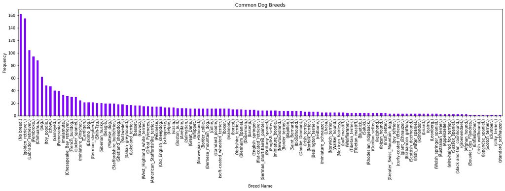

```python
df[['Dog Breed']].value_counts().plot.bar(colormap='rainbow', figsize=(22, 5))
plt.title('Common Dog Breeds')
plt.ylabel('Frequency')
plt.xlabel('Breed Name')
fig = plt.gcf()
```

#### B. Pupper is most frequent dog type in the dataset.

```python
df[['Dog Type']].value_counts()
```

```
Dog Type
No type          1421
pupper            216
doggo              72
floofer            47
puppo              34
multiple dogs       7
dtype: int64
```

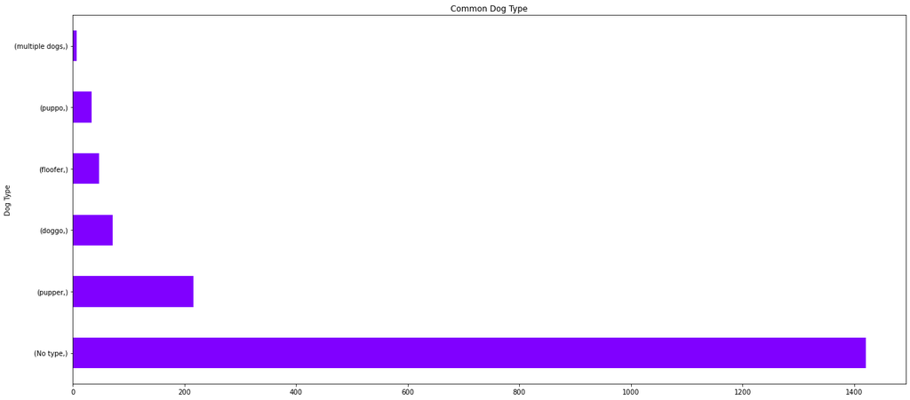

```python
df[['Dog Type']].value_counts().plot.barh(colormap='rainbow', figsize=(22, 10))
plt.title('Common Dog Type')
fig = plt.gcf()
```

### 2- Determining the direct variable influencing the popularity of dogs:

#### As seen below, dog scores are not the main determinent of dogs' popularity, however, the counts of likes and frequencies of shares are correlated and provide a better measure of popularity.

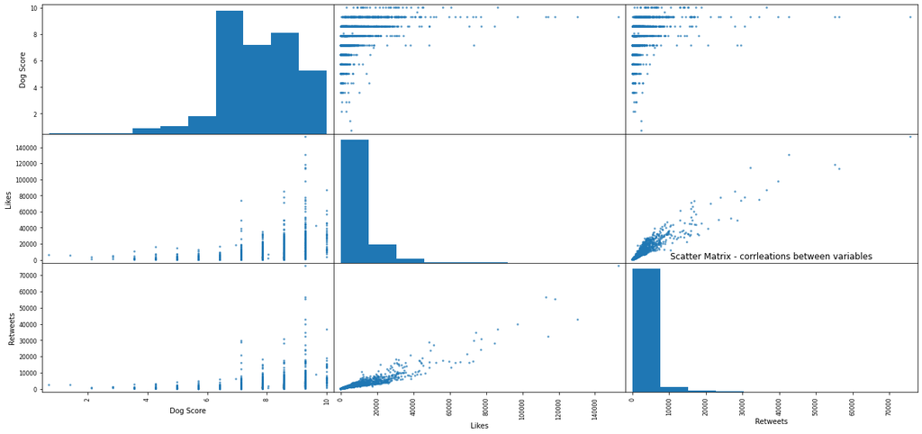

```python
pd.plotting.scatter_matrix(df[['Dog Score', 'Likes', 'Retweets']], alpha=0.7, figsize=(22, 10))
plt.title('Scatter Matrix - corrleations between variables')
fig = plt.gcf()
```

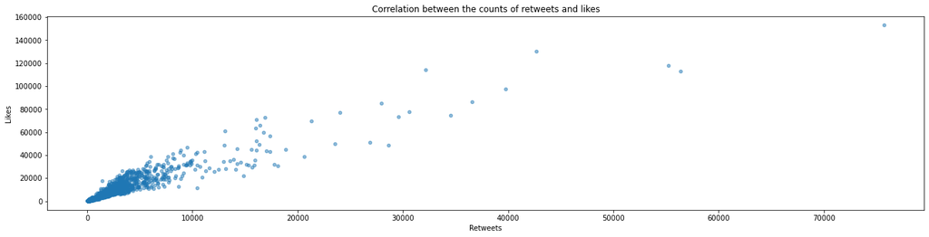

```python
df.plot.scatter(x='Retweets', y='Likes', colormap='rainbow', alpha=0.5, figsize=(22, 5))
plt.title('Correlation between the counts of retweets and likes')
fig = plt.gcf()
```

### 3- Assigning the most popular dog breed/type:

#### A. Bedlington-terrier is the most popular breed in terms of Likes and shares.

```python
bybreed = df[['Retweets', 'Likes', 'Dog Score']].groupby(df['Dog Breed']).mean().sort_values(by=['Likes'])
bybreed
```

| Dog Breed | Retweets | Likes | Dog Score |
| --- | --- | --- | --- |
| Brabancon_griffon | 248.333333 | 787.333333 | 7.142857 |
| groenendael | 238.500000 | 1031.500000 | 7.142857 |
| Japanese_spaniel | 387.000000 | 1186.000000 | 3.571429 |
| Irish_wolfhound | 701.000000 | 1362.000000 | 7.857143 |
| Tibetan_terrier | 476.000000 | 1647.750000 | 6.607143 |
| standard_schnauzer | 772.000000 | 1800.000000 | 8.571429 |
| Scottish_deerhound | 652.333333 | 2202.666667 | 7.380952 |
| basenji | 764.000000 | 2228.333333 | 7.380952 |
| Lhasa | 707.800000 | 2365.000000 | 7.428571 |
| EntleBucher | 597.000000 | 2386.000000 | 7.857143 |
| Welsh_springer_spaniel | 441.333333 | 2437.000000 | 6.428571 |
| Maltese_dog | 1055.368421 | 2623.000000 | 6.954887 |
| toy_terrier | 713.333333 | 2844.000000 | 7.380952 |
| Ibizan_hound | 1263.250000 | 2890.750000 | 6.607143 |
| redbone | 948.500000 | 2919.500000 | 6.904762 |
| miniature_schnauzer | 805.200000 | 3052.600000 | 6.857143 |
| miniature_poodle | 834.125000 | 3085.250000 | 7.053571 |
| Dandie_Dinmont | 855.000000 | 3100.428571 | 6.836735 |
| Scotch_terrier | 1063.000000 | 3180.000000 | 6.428571 |
| Shih-Tzu | 1224.250000 | 3202.300000 | 7.392857 |
| soft-coated_wheaten_terrier | 886.545455 | 3277.090909 | 7.012987 |
| Sussex_spaniel | 1059.000000 | 3629.500000 | 7.857143 |
| Rhodesian_ridgeback | 663.750000 | 3642.750000 | 6.964286 |
| papillon | 1107.857143 | 3919.714286 | 7.142857 |
| beagle | 1132.526316 | 3938.421053 | 7.406015 |
| Saint_Bernard | 1271.857143 | 4069.714286 | 7.040816 |
| Yorkshire_terrier | 1149.500000 | 4105.200000 | 7.285714 |
| curly-coated_retriever | 1044.000000 | 4138.333333 | 7.380952 |
| keeshond | 1470.000000 | 4374.000000 | 7.321429 |
| English_setter | 1316.625000 | 4374.750000 | 7.053571 |
| ... | ... | ... | ... |
| malamute | 2857.757576 | 9716.333333 | 7.770563 |
| bloodhound | 2123.857143 | 9946.857143 | 7.448980 |
| Australian_terrier | 2663.500000 | 9997.000000 | 8.214286 |
| Norwegian_elkhound | 3033.000000 | 10088.454545 | 7.792208 |
| Pembroke | 2681.968085 | 10117.531915 | 8.161094 |
| giant_schnauzer | 2957.000000 | 10401.000000 | 7.857143 |
| Labrador_retriever | 3253.423077 | 10576.019231 | 7.973901 |
| Weimaraner | 2262.000000 | 10775.500000 | 7.857143 |
| Tibetan_mastiff | 3573.250000 | 10853.500000 | 8.750000 |
| Great_Pyrenees | 3847.000000 | 11079.933333 | 8.190476 |
| basset | 2587.000000 | 11150.812500 | 7.901786 |
| Lakeland_terrier | 3719.705882 | 11354.823529 | 7.310924 |
| golden_retriever | 3267.838710 | 11378.554839 | 8.301843 |
| Cardigan | 3240.285714 | 11495.952381 | 7.959184 |
| Eskimo_dog | 4319.190476 | 12169.333333 | 8.231293 |
| Border_terrier | 2911.142857 | 12239.142857 | 8.673469 |
| cocker_spaniel | 4225.433333 | 12373.766667 | 8.095238 |
| Samoyed | 4111.450000 | 12533.500000 | 8.464286 |
| standard_poodle | 4757.000000 | 12554.000000 | 7.662338 |
| whippet | 4380.545455 | 13249.636364 | 7.272727 |
| Leonberg | 3300.333333 | 13314.666667 | 8.095238 |
| English_springer | 5171.888889 | 14117.777778 | 7.936508 |
| Irish_water_spaniel | 3858.000000 | 14684.666667 | 8.095238 |
| flat-coated_retriever | 3942.875000 | 15200.375000 | 8.035714 |
| black-and-tan_coonhound | 3538.500000 | 15369.500000 | 7.500000 |
| Bouvier_des_Flandres | 3817.000000 | 16149.000000 | 9.285714 |
| French_bulldog | 4693.000000 | 18411.700000 | 7.976190 |
| Afghan_hound | 6829.500000 | 20050.500000 | 9.285714 |
| Saluki | 4403.500000 | 21818.000000 | 8.928571 |
| Bedlington_terrier | 7144.000000 | 22677.833333 | 7.380952 |

114 rows × 3 columns

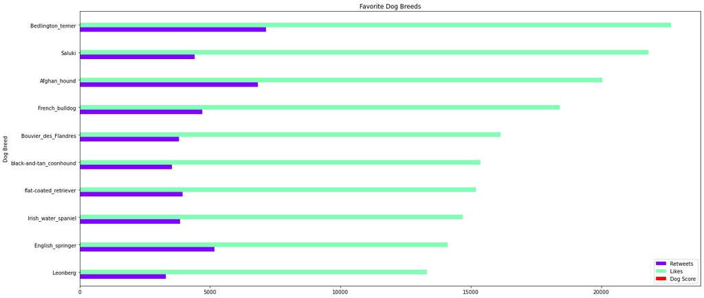

```python
bybreed.iloc[-10:].sort_values(by=['Likes', 'Retweets']).plot.barh(colormap='rainbow', figsize=(22, 10))
plt.title('Favorite Dog Breeds')
fig = plt.gcf()
```

#### B. Puppo dogs are more popular than other dog types.

```python
bytype = df[['Retweets', 'Likes']].groupby(df['Dog Type']).mean().sort_values(by=['Likes'])
bytype
```

| Dog Type | Retweets | Likes |
| --- | --- | --- |
| pupper | 2107.287037 | 6804.597222 |
| No type | 2332.909219 | 8112.439127 |
| floofer | 2492.531915 | 8368.787234 |
| multiple dogs | 3966.285714 | 12005.142857 |
| doggo | 5067.375000 | 15235.861111 |
| puppo | 5834.000000 | 20357.117647 |

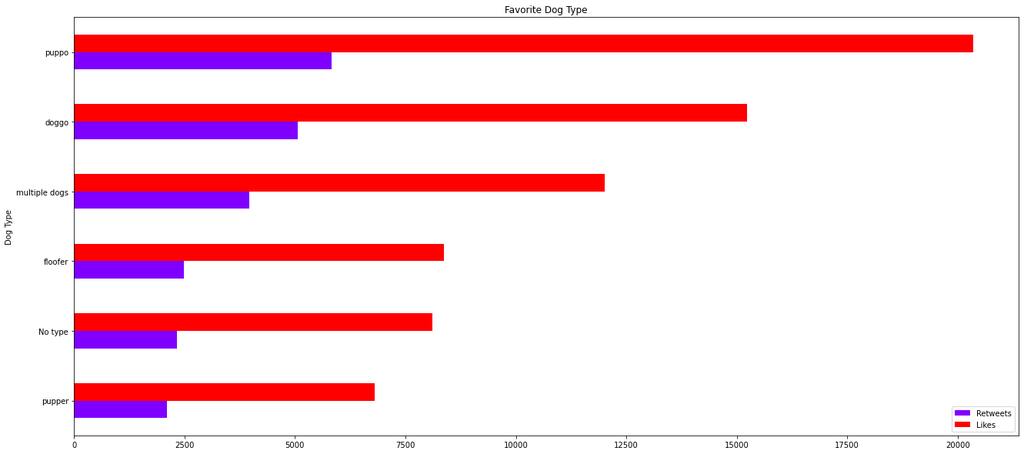

```python
bytype.sort_values(by=['Likes']).plot.barh(colormap='rainbow', figsize=(22, 10))
plt.title('Favorite Dog Type')
fig = plt.gcf()
```

### 4- Assigning the best dogs within the dataset:

#### A. The most popular dog with the most popular breed: ie. the most popular bedlington-terrier.

```python
best_breed = df.loc[df['Dog Breed'] == bybreed.iloc[-1].name].sort_values(by=['Likes'])
best_breed
```

| Tweet Id | Tweet Time | Traffic Source | Tweet Text | Tweet url | Dog Name | Image url | Likes | Retweets | Dog Breed | Confidence Level | Dog Type | Dog Score |
| --- | --- | --- | --- | --- | --- | --- | --- | --- | --- | --- | --- | --- |
| 752334515931054080 | 2016-07-11 02:51:40+00:00 | Twitter for iPhone | Here's a doggo trying to catch some fish. 8/10 futile af (vid by @KellyBauerx) https://t.co/jwd0j6oWLE | https://twitter.com/dog_rates/status/752334515931054080/video/1 | NaN | https://pbs.twimg.com/ext_tw_video_thumb/752334354492362752/pu/img/uWISPc0YRmhUi9Ju.jpg | 3760 | 1074 | Bedlington_terrier | 0.399163 | doggo | 5.714286 |
| 738184450748633089 | 2016-06-02 01:44:22+00:00 | Twitter for iPhone | For the last time, we only rate dogs. Pls stop sending other animals like this Duck-Billed Platypus. Thank you. 9/10 https://t.co/twxYcPOafl | https://twitter.com/dog_rates/status/738184450748633089/photo/1 | NaN | https://pbs.twimg.com/media/Cj6O1G9UYAAIU-1.jpg | 4221 | 1180 | Bedlington_terrier | 0.289471 | No type | 6.428571 |
| 828381636999917570 | 2017-02-05 23:15:47+00:00 | Twitter for iPhone | Meet Doobert. He's a deaf doggo. Didn't stop him on the field tho. Absolute legend today. 14/10 would pat head approvingly https://t.co/iCk7zstRA9 | https://twitter.com/dog_rates/status/828381636999917570/photo/1 | Doobert | https://pbs.twimg.com/media/C38Asz1WEAAvzj3.jpg | 12450 | 2183 | Bedlington_terrier | 0.392535 | doggo | 10.000000 |
| 848212111729840128 | 2017-04-01 16:35:01+00:00 | Twitter for iPhone | This is Jerry. He's doing a distinguished tongue slip. Slightly patronizing tbh. You think you're better than us, Jerry? 6/10 hold me back https://t.co/DkOBbwulw1 | https://twitter.com/dog_rates/status/848212111729840128/photo/1 | Jerry | https://pbs.twimg.com/media/C8V0aI5V0AAgO9m.jpg | 15817 | 2903 | Bedlington_terrier | 0.333486 | No type | 4.285714 |
| 860524505164394496 | 2017-05-05 16:00:04+00:00 | Twitter for iPhone | This is Carl. He likes to dance. Doesn't care what you think about it. 13/10 h*ckin confident pup https://t.co/C2zHcNIu4I | https://twitter.com/dog_rates/status/860524505164394496/photo/1 | Carl | https://pbs.twimg.com/media/C_EyeKuXkAAdxY-.jpg | 22289 | 4904 | Bedlington_terrier | 0.286558 | No type | 9.285714 |
| 678399652199309312 | 2015-12-20 02:20:55+00:00 | Twitter for iPhone | This made my day. 12/10 please enjoy https://t.co/VRTbo3aAcm | https://twitter.com/dog_rates/status/678399652199309312/video/1 | NaN | https://pbs.twimg.com/ext_tw_video_thumb/678399528077250560/pu/img/BOjUNHRsYLeSo0hl.jpg | 77530 | 30620 | Bedlington_terrier | 0.015047 | No type | 8.571429 |

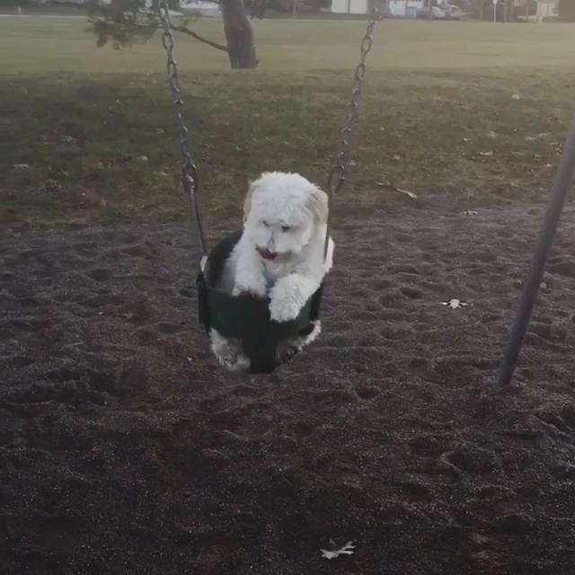

```
(None,
 Dog Name                                                                 NaN
 Dog Breed                                                 Bedlington_terrier
 Dog Type                                                             No type
 Dog Score                                                            8.57143
 Likes                                                                  77530
 Retweets                                                               30620
 Tweet url    https://twitter.com/dog_rates/status/678399652199309312/video/1
 Name: 678399652199309312, dtype: object)
```

```python
bestinbreed = best_breed.sort_values(by=['Likes']).iloc[-1]
display(Image(bestinbreed['Image url'], width=500, unconfined=True)),bestinbreed[['Dog Name', 'Dog Breed', 'Dog Type','Dog Score', 'Likes', 'Retweets', 'Tweet url']]
```

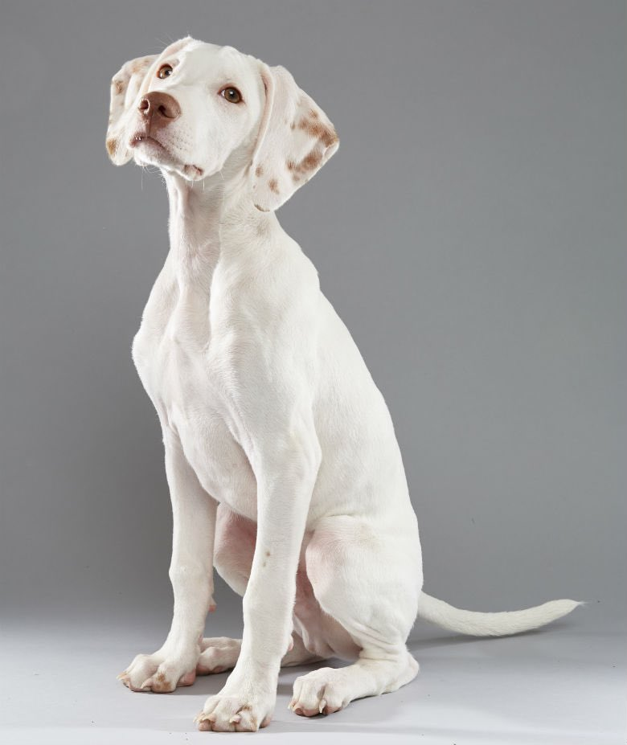

```
(None,
 Dog Name                                                             Doobert
 Dog Breed                                                 Bedlington_terrier
 Dog Type                                                               doggo
 Dog Score                                                                 10
 Likes                                                                  12450
 Retweets                                                                2183
 Tweet url    https://twitter.com/dog_rates/status/828381636999917570/photo/1
 Name: 828381636999917570, dtype: object)
```

```python
bestinbreed2 = best_breed.sort_values(by=['Dog Score']).iloc[-1]
display(Image(bestinbreed2['Image url'], width=500, unconfined=True)),bestinbreed2[['Dog Name', 'Dog Breed', 'Dog Type','Dog Score', 'Likes', 'Retweets', 'Tweet url']]
```

#### B. The most popular dog and the best scoring dog with the most popular type:

ie the most popular and the best scoring puppo dogs.

```python
best_type = df.loc[df['Dog Type'] == bytype.iloc[-1].name]
best_type.sort_values(by=['Likes'])
```

| Tweet Id | Tweet Time | Traffic Source | Tweet Text | Tweet url | Dog Name | Image url | Likes | Retweets | Dog Breed | Confidence Level | Dog Type | Dog Score |
| --- | --- | --- | --- | --- | --- | --- | --- | --- | --- | --- | --- | --- |
| 701601587219795968 | 2016-02-22 02:57:08+00:00 | Twitter for iPhone | This is Coopson. He's a Blingin Schnitzel. Built fence himself. One ear is slightly defective. 10/10 would still pet https://t.co/MWw3pVMhJA | https://twitter.com/dog_rates/status/701601587219795968/photo/1 | Coopson | https://pbs.twimg.com/media/CbyW7B0W8AIX8kX.jpg | 2046 | 440 | Chihuahua | 0.993661 | puppo | 7.142857 |
| 744995568523612160 | 2016-06-20 20:49:19+00:00 | Twitter for iPhone | This is Abby. She got her face stuck in a glass. Churlish af. 9/10 rookie move puppo https://t.co/2FPb45NXrK | https://twitter.com/dog_rates/status/744995568523612160/photo/1,https://twitter.com/dog_rates/status/744995568523612160/photo/1 | Abby | https://pbs.twimg.com/media/ClbBg4WWEAMjwJu.jpg | 2915 | 596 | Old_English_sheepdog | 0.427481 | puppo | 6.428571 |
| 677716515794329600 | 2015-12-18 05:06:23+00:00 | Twitter for iPhone | IT'S PUPPERGEDDON. Total of 144/120 ...I think https://t.co/ZanVtAtvIq | https://twitter.com/dog_rates/status/677716515794329600/photo/1 | NaN | https://pbs.twimg.com/media/CWe7kw9W4AE8UJh.jpg | 2941 | 941 | chow | 0.025438 | puppo | 8.571429 |
| 768609597686943744 | 2016-08-25 00:43:02+00:00 | Twitter for iPhone | This is Lou. His sweater is too small and he already cut the tags off. Very very churlish. 10/10 would still pet https://t.co/dZPMLresEr | https://twitter.com/dog_rates/status/768609597686943744/photo/1 | Lou | https://pbs.twimg.com/media/CqqmWa7WcAAIM-n.jpg | 4071 | 1177 | basenji | 0.183283 | puppo | 7.142857 |
| 743253157753532416 | 2016-06-16 01:25:36+00:00 | Twitter for iPhone | This is Kilo. He cannot reach the snackum. Nifty tongue, but not nifty enough. 10/10 maybe one day puppo https://t.co/gSmp31Zrsx | https://twitter.com/dog_rates/status/743253157753532416/photo/1 | Kilo | https://pbs.twimg.com/media/ClCQzFUUYAA5vAu.jpg | 4138 | 1193 | malamute | 0.442612 | puppo | 7.142857 |
| 738537504001953792 | 2016-06-03 01:07:16+00:00 | Twitter for iPhone | This is Bayley. She fell asleep trying to escape her evil fence enclosure. 11/10 night night puppo https://t.co/AxSiqAKEKu | https://twitter.com/dog_rates/status/738537504001953792/photo/1,https://twitter.com/dog_rates/status/738537504001953792/photo/1 | Bayley | https://pbs.twimg.com/media/Cj_P7rSUgAAYQbz.jpg | 4962 | 1487 | chow | 0.808737 | puppo | 7.857143 |
| 751132876104687617 | 2016-07-07 19:16:47+00:00 | Twitter for iPhone | This is Cooper. He's just so damn happy. 10/10 what's your secret puppo? https://t.co/yToDwVXEpA | https://twitter.com/dog_rates/status/751132876104687617/photo/1,https://twitter.com/dog_rates/status/751132876104687617/photo/1 | Cooper | https://pbs.twimg.com/media/CmyPXNOW8AEtaJ-.jpg | 4978 | 1276 | Labrador_retriever | 0.929390 | puppo | 7.142857 |
| 819952236453363712 | 2017-01-13 17:00:21+00:00 | Twitter for iPhone | This is Oliver. He has dreams of being a service puppo so he can help his owner. 13/10 selfless af\n\nmake it happen:\nhttps://t.co/f5WMsx0a9K https://t.co/6lJz0DKZIb | https://www.gofundme.com/servicedogoliver,https://twitter.com/dog_rates/status/819952236453363712/photo/1 | Oliver | https://pbs.twimg.com/media/C2EONHNWQAUWxkP.jpg | 5293 | 1164 | American_Staffordshire_terrier | 0.925505 | puppo | 9.285714 |
| 825026590719483904 | 2017-01-27 17:04:02+00:00 | Twitter for iPhone | Say hello to Pablo. He's one gorgeous puppo. A true 12/10. Click the link to see why Pablo requests your assistance\n\nhttps://t.co/koHvVQp9bL https://t.co/IhW0JKf7kc | https://www.gofundme.com/my-puppys-double-cataract-surgery,https://twitter.com/dog_rates/status/825026590719483904/photo/1,https://twitter.com/dog_rates/status/825026590719483904/photo/1 | Pablo | https://pbs.twimg.com/media/C3MVTeHWcAAGNfx.jpg | 6231 | 1236 | Eskimo_dog | 0.524454 | puppo | 8.571429 |
| 756275833623502848 | 2016-07-21 23:53:04+00:00 | Twitter for iPhone | When ur older siblings get to play in the deep end but dad says ur not old enough. Maybe one day puppo. All 10/10 https://t.co/JrDAzMhwG9 | https://twitter.com/dog_rates/status/756275833623502848/photo/1,https://twitter.com/dog_rates/status/756275833623502848/photo/1 | NaN | https://pbs.twimg.com/media/Cn7U2xlW8AI9Pqp.jpg | 6307 | 1503 | Airedale | 0.602957 | puppo | 7.142857 |
| 778027034220126208 | 2016-09-20 00:24:34+00:00 | Twitter for iPhone | This is Sophie. She's a Jubilant Bush Pupper. Super h*ckin rare. Appears at random just to smile at the locals. 11.27/10 would smile back https://t.co/QFaUiIHxHq | https://twitter.com/dog_rates/status/778027034220126208/photo/1 | Sophie | https://pbs.twimg.com/media/Cswbc2yWcAAVsCJ.jpg | 6509 | 1591 | clumber | 0.946718 | puppo | 8.050000 |
| 805826884734976000 | 2016-12-05 17:31:15+00:00 | Twitter for iPhone | This is Duke. He is not a fan of the pupporazzi. 12/10 https://t.co/SgpBVYIL18 | https://twitter.com/dog_rates/status/805826884734976000/video/1 | Duke | https://pbs.twimg.com/ext_tw_video_thumb/805826823359631360/pu/img/yr_fF0TZCR-B70p2.jpg | 6549 | 1819 | Siberian_husky | 0.248926 | puppo | 8.571429 |
| 752519690950500352 | 2016-07-11 15:07:30+00:00 | Twitter for iPhone | Hopefully this puppo on a swing will help get you through your Monday. 11/10 would push https://t.co/G54yClasz2 | https://twitter.com/dog_rates/status/752519690950500352/photo/1,https://twitter.com/dog_rates/status/752519690950500352/photo/1,https://twitter.com/dog_rates/status/752519690950500352/photo/1 | NaN | https://pbs.twimg.com/media/CnF8qVDWYAAh0g1.jpg | 7254 | 3381 | Labrador_retriever | 0.000010 | puppo | 7.857143 |
| 779377524342161408 | 2016-09-23 17:50:56+00:00 | Twitter for iPhone | Have you ever seen such a smol pupper? Portable af. 12/10 would keep in shirt pocket https://t.co/KsqaIzlQ12 | https://twitter.com/dog_rates/status/779377524342161408/video/1 | NaN | https://pbs.twimg.com/ext_tw_video_thumb/779377444025499652/pu/img/eIiLDy9F6rPNarEc.jpg | 8734 | 3093 | No breed | 0.000000 | puppo | 8.571429 |
| 791312159183634433 | 2016-10-26 16:14:55+00:00 | Twitter for iPhone | This is Mabel. She's super h*ckin smol. Portable af. Comes with the smol shoe. 12/10 would keep in frocket https://t.co/GGJvxYt3xK | https://twitter.com/dog_rates/status/791312159183634433/photo/1,https://twitter.com/dog_rates/status/791312159183634433/photo/1,https://twitter.com/dog_rates/status/791312159183634433/photo/1,https://… | Mabel | https://pbs.twimg.com/media/CvtONV4WAAAQ3Rn.jpg | 8757 | 2529 | miniature_pinscher | 0.892925 | puppo | 8.571429 |
| 802239329049477120 | 2016-11-25 19:55:35+00:00 | Twitter for iPhone | This is Loki. He'll do your taxes for you. Can also make room in your budget for all the things you bought today. 12/10 what a puppo https://t.co/5oWrHCWg87 | https://twitter.com/dog_rates/status/802239329049477120/photo/1,https://twitter.com/dog_rates/status/802239329049477120/photo/1 | Loki | https://pbs.twimg.com/media/CyIgaTEVEAA-9zS.jpg | 9078 | 2626 | Eskimo_dog | 0.482498 | puppo | 8.571429 |
| 803773340896923648 | 2016-11-30 01:31:12+00:00 | Twitter for iPhone | This is Diogi. He fell in the pool as soon as he was brought home. Clumsy puppo. 12/10 would pet until dry https://t.co/ZxeRjMKaWt | https://twitter.com/dog_rates/status/803773340896923648/photo/1,https://twitter.com/dog_rates/status/803773340896923648/photo/1,https://twitter.com/dog_rates/status/803773340896923648/photo/1,https://… | Diogi | https://pbs.twimg.com/media/CyeTku-XcAALkBd.jpg | 10067 | 2745 | miniature_pinscher | 0.817066 | puppo | 8.571429 |
| 787717603741622272 | 2016-10-16 18:11:26+00:00 | Twitter for iPhone | This is Tonks. She is a service puppo. Can hear a caterpillar hiccup from 7 miles away. 13/10 would follow anywhere https://t.co/i622ZbWkUp | https://twitter.com/dog_rates/status/787717603741622272/photo/1,https://twitter.com/dog_rates/status/787717603741622272/photo/1,https://twitter.com/dog_rates/status/787717603741622272/photo/1,https://… | Tonks | https://pbs.twimg.com/media/Cu6I9vvWIAAZG0a.jpg | 10251 | 2766 | German_shepherd | 0.992339 | puppo | 9.285714 |
| 781955203444699136 | 2016-09-30 20:33:43+00:00 | Twitter for iPhone | This is Chipson. He weighed in at .3 ounces and is officially super h*ckin smol. Space-saving af. 11/10 would snug delicately https://t.co/FjEsk7A1JV | https://twitter.com/dog_rates/status/781955203444699136/photo/1 | Chipson | https://pbs.twimg.com/media/CtoQGu4XgAQgv5m.jpg | 11087 | 3346 | No breed | 0.000000 | puppo | 7.857143 |
| 889531135344209921 | 2017-07-24 17:02:04+00:00 | Twitter for iPhone | This is Stuart. He's sporting his favorite fanny pack. Secretly filled with bones only. 13/10 puppared puppo #BarkWeek https://t.co/y70o6h3isq | https://twitter.com/dog_rates/status/889531135344209921/photo/1 | Stuart | https://pbs.twimg.com/media/DFg_2PVW0AEHN3p.jpg | 13975 | 2009 | golden_retriever | 0.953442 | puppo | 9.285714 |
| 867421006826221569 | 2017-05-24 16:44:18+00:00 | Twitter for iPhone | This is Shikha. She just watched you drop a skittle on the ground and still eat it. Could not be less impressed. 12/10 superior puppo https://t.co/XZlZKd73go | https://twitter.com/dog_rates/status/867421006826221569/photo/1 | Shikha | https://pbs.twimg.com/media/DAmyy8FXYAIH8Ty.jpg | 15023 | 2270 | Eskimo_dog | 0.616457 | puppo | 8.571429 |
| 793195938047070209 | 2016-10-31 21:00:23+00:00 | Twitter for iPhone | Say hello to Lily. She's pupset that her costume doesn't fit as well as last year. 12/10 poor puppo https://t.co/YSi6K1firY | https://twitter.com/dog_rates/status/793195938047070209/photo/1,https://twitter.com/dog_rates/status/793195938047070209/photo/1 | Lily | https://pbs.twimg.com/media/CwH_foYWgAEvTyI.jpg | 15252 | 5619 | Labrador_retriever | 0.654762 | puppo | 8.571429 |
| 790946055508652032 | 2016-10-25 16:00:09+00:00 | Twitter for iPhone | This is Betty. She's assisting with the dishes. Such a good puppo. 12/10 h*ckin helpful af https://t.co/dgvTPZ9tgI | https://twitter.com/dog_rates/status/790946055508652032/photo/1 | Betty | https://pbs.twimg.com/media/CvoBPWRWgAA4het.jpg | 16657 | 4690 | golden_retriever | 0.245773 | puppo | 8.571429 |
| 859607811541651456 | 2017-05-03 03:17:27+00:00 | Twitter for iPhone | Sorry for the lack of posts today. I came home from school and had to spend quality time with my puppo. Her name is Zoey and she's 13/10 https://t.co/BArWupFAn0 | https://twitter.com/dog_rates/status/859607811541651456/photo/1 | NaN | https://pbs.twimg.com/media/C-3wvtxXcAUTuBE.jpg | 17604 | 1441 | golden_retriever | 0.895529 | puppo | 9.285714 |
| 866686824827068416 | 2017-05-22 16:06:55+00:00 | Twitter for iPhone | This is Lili. She can't believe you betrayed her with bath time. Never looking you in the eye again. 12/10 would puppologize profusely https://t.co/9b9J46E86Z | https://twitter.com/dog_rates/status/866686824827068416/photo/1,https://twitter.com/dog_rates/status/866686824827068416/photo/1 | Lili | https://pbs.twimg.com/media/DAcXEWuXkAIBDGJ.jpg | 17992 | 3167 | flat-coated_retriever | 0.514730 | puppo | 8.571429 |
| 780931614150983680 | 2016-09-28 00:46:20+00:00 | Twitter for iPhone | I want to finally rate this iconic puppo who thinks the parade is all for him. 13/10 would absolutely attend https://t.co/5dUYOu4b8d | https://twitter.com/dog_rates/status/780931614150983680/photo/1 | NaN | https://pbs.twimg.com/media/CtZtJxAXEAAyPGd.jpg | 21530 | 7247 | No breed | 0.000000 | puppo | 9.285714 |
| 876120275196170240 | 2017-06-17 16:52:05+00:00 | Twitter for iPhone | Meet Venti, a seemingly caffeinated puppoccino. She was just informed the weekend would include walks, pats and scritches. 13/10 much excite https://t.co/ejExJFq3ek | https://twitter.com/dog_rates/status/876120275196170240/photo/1 | Venti | https://pbs.twimg.com/media/DCiavj_UwAAcXep.jpg | 25856 | 4166 | Bernese_mountain_dog | 0.534327 | puppo | 9.285714 |
| 874012996292530176 | 2017-06-11 21:18:31+00:00 | Twitter for iPhone | This is Sebastian. He can't see all the colors of the rainbow, but he can see that this flag makes his human happy. 13/10 #PrideMonth puppo https://t.co/XBE0evJZ6V | https://twitter.com/dog_rates/status/874012996292530176/photo/1,https://twitter.com/dog_rates/status/874012996292530176/photo/1 | Sebastian | https://pbs.twimg.com/media/DCEeLxjXsAAvNSM.jpg | 31656 | 9149 | Cardigan | 0.806674 | puppo | 9.285714 |
| 871879754684805121 | 2017-06-06 00:01:46+00:00 | Twitter for iPhone | Say hello to Lassie. She's celebrating #PrideMonth by being a splendid mix of astute and adorable. Proudly supupporting her owner. 13/10 https://t.co/uK6PNyeh9w | https://twitter.com/dog_rates/status/871879754684805121/photo/1,https://twitter.com/dog_rates/status/871879754684805121/photo/1 | Lassie | https://pbs.twimg.com/media/DBmKAmBXUAE-pQ-.jpg | 34814 | 9841 | Shetland_sheepdog | 0.969171 | puppo | 9.285714 |
| 855851453814013952 | 2017-04-22 18:31:02+00:00 | Twitter for iPhone | Here's a puppo participating in the #ScienceMarch. Cleverly disguising her own doggo agenda. 13/10 would keep the planet habitable for https://t.co/cMhq16isel | https://twitter.com/dog_rates/status/855851453814013952/photo/1 | NaN | https://pbs.twimg.com/media/C-CYWrvWAAU8AXH.jpg | 43702 | 17000 | flat-coated_retriever | 0.321676 | puppo | 9.285714 |
| 889665388333682689 | 2017-07-25 01:55:32+00:00 | Twitter for iPhone | Here's a puppo that seems to be on the fence about something haha no but seriously someone help her. 13/10 https://t.co/BxvuXk0UCm | https://twitter.com/dog_rates/status/889665388333682689/photo/1 | NaN | https://pbs.twimg.com/media/DFi579UWsAAatzw.jpg | 44193 | 8893 | Pembroke | 0.966327 | puppo | 9.285714 |
| 825535076884762624 | 2017-01-29 02:44:34+00:00 | Twitter for iPhone | Here's a very loving and accepting puppo. Appears to have read her Constitution well. 14/10 would pat head approvingly https://t.co/6ao80wIpV1 | https://twitter.com/dog_rates/status/825535076884762624/photo/1 | NaN | https://pbs.twimg.com/media/C3TjvitXAAAI-QH.jpg | 56382 | 17333 | Rottweiler | 0.681495 | puppo | 10.000000 |
| 859196978902773760 | 2017-05-02 00:04:57+00:00 | Twitter for iPhone | We only rate dogs. This is quite clearly a smol broken polar bear. We'd appreciate if you only send dogs. Thank you... 12/10 https://t.co/g2nSyGenG9 | https://twitter.com/dog_rates/status/859196978902773760/video/1 | NaN | https://pbs.twimg.com/ext_tw_video_thumb/859196962498805762/pu/img/-yBpr4-o4GJZECYE.jpg | 84853 | 27956 | malamute | 0.216163 | puppo | 8.571429 |
| 822872901745569793 | 2017-01-21 18:26:02+00:00 | Twitter for iPhone | Here's a super supportive puppo participating in the Toronto #WomensMarch today. 13/10 https://t.co/nTz3FtorBc | https://twitter.com/dog_rates/status/822872901745569793/photo/1 | NaN | https://pbs.twimg.com/media/C2tugXLXgAArJO4.jpg | 130485 | 42666 | Lakeland_terrier | 0.196015 | puppo | 9.285714 |

```
(None,
 Dog Name                                                                 NaN
 Dog Breed                                                   Lakeland_terrier
 Dog Type                                                               puppo
 Dog Score                                                            9.28571
 Likes                                                                 130485
 Retweets                                                               42666
 Tweet url    https://twitter.com/dog_rates/status/822872901745569793/photo/1
 Name: 822872901745569793, dtype: object)
```

```python
bestintype = best_type.sort_values(by=['Likes']).iloc[-1]
display(Image(bestintype['Image url'], width=500, unconfined=True)),bestintype[['Dog Name', 'Dog Breed', 'Dog Type','Dog Score', 'Likes', 'Retweets', 'Tweet url']]
```

[output not shown]

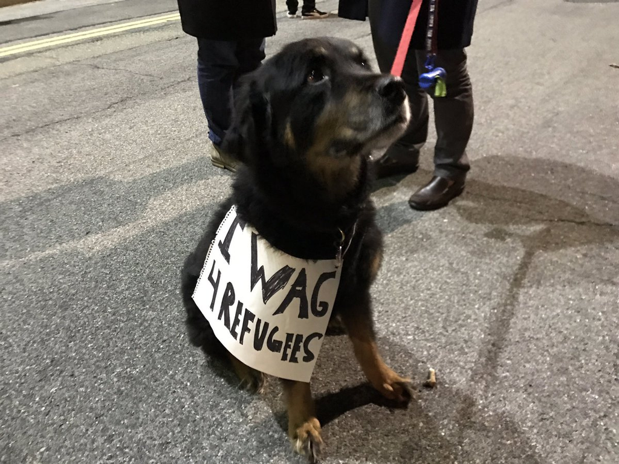

```
(None,
 Dog Name                                                                 NaN
 Dog Breed                                                         Rottweiler
 Dog Type                                                               puppo
 Dog Score                                                                 10
 Likes                                                                  56382
 Retweets                                                               17333
 Tweet url    https://twitter.com/dog_rates/status/825535076884762624/photo/1
 Name: 825535076884762624, dtype: object)
```

```python
bestintype2 = best_type.sort_values(by=['Dog Score']).iloc[-1]
display(Image(bestintype2['Image url'], width=500, unconfined=True)),bestintype2[['Dog Name', 'Dog Breed', 'Dog Type','Dog Score', 'Likes', 'Retweets', 'Tweet url']]
```

#### C. The best scoring dog regardless breeds and types:

[figure not shown]

```
(None,
 Dog Name                                                                                                                                                                      Iggy
 Dog Breed                                                                                                                                                                 No breed
 Dog Type                                                                                                                                                                   No type
 Dog Score                                                                                                                                                                       10
 Likes                                                                                                                                                                        23389
 Retweets                                                                                                                                                                      6743
 Tweet Text    This is Iggy. He was a rescue dog killed in the Stockholm attack. His memorial started with a collar and four bones. It's grown a bit. 14/10 https://t.co/E4a0R9my1M
 Name: 851464819735769094, dtype: object)
```

```python
bestinscore = df.sort_values(by=['Dog Score']).iloc[-1]
display(Image(bestinscore['Image url'], width=500, unconfined=True)),bestinscore[['Dog Name', 'Dog Breed', 'Dog Type','Dog Score', 'Likes', 'Retweets', 'Tweet Text']]
```

#### D. The most popular dog regardless breeds and types:

```
(None,
 Dog Name                                                                 NaN
 Dog Breed                                                 Labrador_retriever
 Dog Type                                                               doggo
 Dog Score                                                            9.28571
 Likes                                                                 153005
 Retweets                                                               75738
 Tweet url    https://twitter.com/dog_rates/status/744234799360020481/video/1
 Name: 744234799360020481, dtype: object)
```

```python
most_liked = df.sort_values(by=['Likes', 'Retweets']).iloc[-1]
display(Image(most_liked['Image url'], width=500, unconfined=True)),most_liked[['Dog Name', 'Dog Breed', 'Dog Type','Dog Score', 'Likes', 'Retweets', 'Tweet url']]
```

[output not shown]

### 5- Analysis of Common Dog Names within the dataset:

```python
df['Dog Name'] = df['Dog Name'].str.title()
name_dict = df['Dog Name'].value_counts()
name_dict
```

```
Cooper            10
Charlie           10
Penny              9
Oliver             9
Tucker             9
Lucy               9
Sadie              8
Lola               7
Toby               7
Winston            7
Daisy              7
Jax                6
Bo                 6
Koda               6
Bella              6
Louis              5
Oscar              5
Bailey             5
Rusty              5
Scout              5
Stanley            5
Leo                5
Jack               4
Gus                4
Buddy              4
Bentley            4
Maggie             4
Chester            4
Cassie             4
Archie             4
                  ..
Ambrose            1
Erik               1
Lizzie             1
Beebop             1
Cilantro           1
Godzilla           1
Brandi             1
Traviss            1
Reagan             1
Harvey             1
Baxter             1
Brad               1
Mutt               1
Clyde              1
Stu                1
Brooks             1
Banjo              1
Brownie            1
Brutus             1
Karll              1
Devón              1
Eugene             1
Michelangelope     1
Andy               1
Mabel              1
Arlo               1
Quinn              1
Dudley             1
Staniel            1
Hector             1
Name: Dog Name, Length: 869, dtype: int64
```

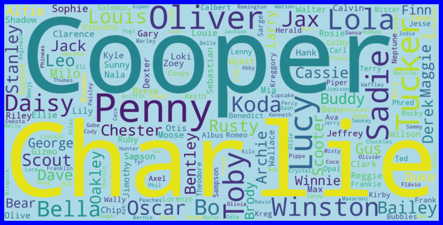

```python
wordcloud = WordCloud(width=2000, height=1000, repeat=False, background_color='lightblue').generate_from_frequencies(name_dict)
plt.figure(facecolor='blue', edgecolor='black', figsize=(15, 5))
plt.imshow(wordcloud, interpolation="bilinear")
plt.axis("off")
plt.tight_layout(pad=0)
plt.show()
```